# Behind The Scenes

Will Moscato, Alex Denzler, Jake Greenberg, Michael Helton

```r
knitr::opts_chunk$set(echo = TRUE, include = TRUE, eval = TRUE)
```

```r
library(tidyverse)
library(tidymodels)
library(lubridate)
library(vip)
library(stacks)
library(DALEX)
library(DALEXtra)
library(themis)
library(formattable)
library(kableExtra)
```

```r
library(cowplot)
library(formattable)
library(kableExtra)
library(cvms)
```

# Data Cleaning

The majority of the cleaning for this project was getting the names of the players from the different data sets to match up. Some players had different names in the fifa (video game) data set than what their actual name is, or they had some nickname either in the fifa data set or in their stats, or for a few players the spelling didn’t match up. Other than that most of the variables were already very good and we just had to rename them and join all the data sets together.

We will run you through the cleaning for the premier league for 2017 and then include the code for all the other years and leagues, but it is essentially the same thing.

## Premier League

```r
fifa17 <- read_csv("fut_bin17_players.csv")
fifa18 <- read_csv("fut_bin18_players.csv")
fifa19 <- read_csv("fut_bin19_players.csv")
fifa21 <- read_csv("fut_bin21_players.csv")
premnames17 <- read.csv("16_17_premnames.csv")
premnames18 <- read.csv("17_18_premnames.csv")
premnames19 <- read.csv("18_19_premnames.csv")
standardprem17 <- read.csv("standardprem17.csv")
standardprem18 <- read.csv("standardprem18.csv")
standardprem19 <- read.csv("standardprem19.csv")
premtable17 <- read.csv("premtable17.csv")
premtable18 <- read.csv("premtable18.csv")
premtable19 <- read.csv("premtable19.csv")
premgoalkeeper17 <- read.csv('goalkeeper17.csv')
premgoalkeeper18 <- read.csv('goalkeeper18.csv')
premgoalkeeper19 <- read.csv('goalkeeper19.csv')
premnames21 <- read.csv("20_21_premnames.csv")
standardprem21 <- read.csv("standardprem21.csv")
premtable21 <- read.csv("premtable21.csv")
```

```r
fifa17_clean <- fifa17 %>%
  filter(revision %in% c("Normal", "TOTS")) %>%
  arrange(desc(overall)) %>%
  distinct(player_extended_name, .keep_all = TRUE)
```

```r
fifa18_clean <- fifa18 %>%
  filter(revision %in% c("Normal", "TOTS")) %>%
  arrange(desc(overall)) %>%
  distinct(player_extended_name, .keep_all = TRUE)
```

```r
fifa19_clean <- fifa19 %>%
  filter(revision %in% c("Normal", "TOTS")) %>%
  arrange(desc(overall)) %>%
  distinct(player_extended_name, .keep_all = TRUE)
```

First we took out all the card types in the fifa data sets that were not just the normal base card or the team of the season card. Then we took out any players that had multiple cards in the data set. This way we didn’t have any duplicate players when trying to join with player stats and team stats. Also we wanted to make sure that what we were modeling off of only had the team of the season players as team of the seasons.

```r
fifa21_clean <- fifa21 %>%
  mutate(revision = ifelse(revision == "Rare", "Normal", ifelse(revision == "Non-Rare", "Normal", revision))) %>%
  mutate(club = ifelse(player_name == "Rúben Dias", "Manchester City", ifelse(player_extended_name == "Wesley Fofana", "Leicester City", club))) %>%
  mutate(league = ifelse(player_name == "Rúben Dias", "Premier League", ifelse(player_extended_name == "Wesley Fofana", "Premier League", league))) %>%
  filter(revision %in% c("Normal", "TOTS")) %>%
  arrange(desc(overall)) %>%
  distinct(player_extended_name, .keep_all = TRUE)
```

For the 2021 data set we had to add in a few players to the premier league because the data set was not updated.

```r
fifa17_names <- fifa17_clean %>%
  mutate(player_extended_name = stringi::stri_trans_general(player_extended_name, "Latin-ASCII")) %>%
   mutate(player_name = stringi::stri_trans_general(player_name, "Latin-ASCII"))
```

```r
fifa18_names <- fifa18_clean %>%
  mutate(player_extended_name = stringi::stri_trans_general(player_extended_name, "Latin-ASCII")) %>%
   mutate(player_name = stringi::stri_trans_general(player_name, "Latin-ASCII"))
```

```r
fifa19_names <- fifa19_clean %>%
  mutate(player_extended_name = stringi::stri_trans_general(player_extended_name, "Latin-ASCII")) %>%
   mutate(player_name = stringi::stri_trans_general(player_name, "Latin-ASCII"))
```

```r
fifa21_names <- fifa21_clean %>%
  mutate(player_extended_name = stringi::stri_trans_general(player_extended_name, "Latin-ASCII")) %>%
   mutate(player_name = stringi::stri_trans_general(player_name, "Latin-ASCII"))
```

We then took out all of the accents from the player names because there were no accents in the data set with all the stats.

### 2017

```r
premnames17 <-premnames17 %>%
  mutate(Player1 = gsub(".*\\\\", "", Player)) %>%
  mutate(Player = str_replace_all(Player1, "-", " "))
```

From the data set of miscellaneous stats we simplified the names of the players in order to get rid of the slashes (the names were there twice, once with some accents once without) and to get rid of any hyphens.

```r
prem17_names <- fifa17_names %>%
  filter(league == "Premier League") %>%
  select(player_name, player_extended_name, overall, revision, position)
```

Then from the fifa data set we filtered for the desired league and selected the variables that we want.

```r
prem17 <- premnames17 %>%
  inner_join(prem17_names, by = c("Player" = "player_extended_name")) %>%
  select(-Player1, -player_name)
```

Then we attempted our first join by if the full name of the player in fifa matched the full name of the player from the stats page. This got a decent number of players, but especially for Spanish and Brazilian players it tended not match perfectly.

```r
missing17 <- premnames17 %>%
  left_join(prem17_names, by = c("Player" = "player_extended_name")) %>%
  filter(is.na(player_name) == TRUE)
```

We then did a left join of the same data sets in order to get the ones that don’t match in the data set.

```r
not_missing_17 <- missing17 %>%
  select(-overall, -revision, -position) %>%
  left_join(prem17_names, by = c("Player" = "player_name"))
```

Then we joined by the shortened player names in the fifa data sets and this got us a number of the rest of the players.

```r
last_names17 <- not_missing_17 %>%
  filter(is.na(overall) == TRUE) %>%
  mutate(Player_short =  gsub(".* ", "", Player)) %>%
  mutate(Player_short = ifelse(Player_short == "Aanholt", "Van Aanholt", ifelse(Player_short == "Dijk", "Van Dijk", ifelse(Player_short == "min", "Son", ifelse(Player_short == "Prowse", "Ward-Prowse", ifelse(Player_short == "yueng", "Ki Sung Yueng", ifelse(Player_short == "yong", "Lee Chung Yong", ifelse(Player_short == "Cheek", "Loftus-Cheek", ifelse(Player_short == "Chamberlain", "Oxlade-Chamberlain", ifelse(Player_short == "Gea", "De Gea", ifelse(Player_short == "Traore", "Adama", ifelse(Player_short == "Bissaka", "Wan-Bissaka", Player_short)))))))))))) %>%
  select(-player_name, -player_extended_name, -overall, -revision, - Player1, -position)

not_real_name17 <- not_missing_17 %>%
  filter(is.na(overall) == FALSE) %>%
  select(-Player1, -player_name, -player_extended_name)
```

Then for all the players that could not be joined in from the last two methods we had to manually go through and change their names in order for them to match. This was the most tedious part of the cleaning due to the fact that we had to go through all of the players one by one.

```r
weird_names17 <- last_names17 %>%
  inner_join(prem17_names, by = c("Player_short" = "player_name")) %>%
  select(-Player_short, -player_extended_name)
```

Lastly, to get all the names that we changed manually we inner joined by the shortened changed name that we created.

```r
fifa17_prem_full <- prem17 %>%
  bind_rows(not_real_name17, weird_names17) %>%
  distinct(Player, .keep_all = TRUE) %>%
  select(Player, revision, position, Int, TklW, OG, PKcon)
```

Once we had all the player names joined together properly we bound the rows to have a full data set of all the players with some miscellaneous stats and the fifa stats. We then selected the stats that we needed from this data set.

```r
standardprem17 <- standardprem17 %>%
  mutate(Player1 = gsub(".*\\\\", "", Player)) %>%
  mutate(Player = str_replace_all(Player1, "-", " "))
```

```r
fifa17_prem_standard_stats <- fifa17_prem_full %>%
  inner_join(standardprem17, by = "Player") %>%
  select(-Player1, -Pos) %>%
  distinct(Player, .keep_all = TRUE)
```

We then added in standard stats for all the players.

```r
fifa17_standard_plus_table <- fifa17_prem_standard_stats %>%
  inner_join(premtable17, by = "Squad")
```

And we added in some team stats for each player.

```r
premgoalkeeper17 <- premgoalkeeper17 %>%
  mutate(Player1 = gsub(".*\\\\", "", Player)) %>%
  mutate(Player = str_replace_all(Player1, "-", " ")) %>%
  rename(Pkatt_against = PKatt) %>%
  rename(Goals_allowed = GA)
```

And we added some goalkeeping stats (we ended up not being able to model for goalkeepers because of a lack of data for them and the huge difference in the type of stats for them).

```r
fifa17_modeling <- fifa17_standard_plus_table %>%
  left_join(premgoalkeeper17, by = "Player") %>%
  rename(minutes_played_divided_by90 = X90s, Non_PK_G = G.PK, G_plus_A_per90 = G.A, G_minus_Pk_per90 = G.PK.1, G_plus_A_minus_PK_per90 = G.A.PK, Save_percent = Save., CS_percent = CS., Pk_Save_percent = Save..1, G_per90 = Gls.1, A_per90 = Ast.1 ) %>%
  select(-Matches.x, -Matches.y, -Player1, -Starts) %>%
  mutate(Nation = sub('.* ', '', Nation))
```

Lastly, we renamed a bunch of the variables to make them more intuitive.  
From here on out it is essentially the same process iterated over year and league. Each year and each league obviously had some different name issues and different names that had to be manually changed in order to get it to match, but the process for each year and each league was the same.

### 2018

```r
premnames18 <-premnames18 %>%
  mutate(Player1 = gsub(".*\\\\", "", Player)) %>%
  mutate(Player = str_replace_all(Player1, "-", " "))
```

```r
prem18_names <- fifa18_names %>%
  filter(league == "Premier League") %>%
  select(player_name, player_extended_name, overall, revision, position)
```

```r
prem18 <- premnames18 %>%
  inner_join(prem18_names, by = c("Player" = "player_extended_name")) %>%
  select(-Player1, -player_name)
```

```r
missing18 <- premnames18 %>%
  left_join(prem18_names, by = c("Player" = "player_extended_name")) %>%
  filter(is.na(player_name) == TRUE)
```

```r
not_missing_18 <- missing18 %>%
  select(-overall, -revision, -position) %>%
  left_join(prem18_names, by = c("Player" = "player_name"))
```

```r
last_names18 <- not_missing_18 %>%
  filter(is.na(overall) == TRUE) %>%
  mutate(Player_short =  gsub(".* ", "", Player)) %>%
  mutate(Player_short = ifelse(Player_short == "Aanholt", "Van Aanholt", ifelse(Player_short == "Dijk", "Van Dijk", ifelse(Player_short == "min", "Son", ifelse(Player_short == "Prowse", "Ward-Prowse", ifelse(Player_short == "yueng", "Ki Sung Yueng", ifelse(Player_short == "yong", "Lee Chung Yong", ifelse(Player_short == "Cheek", "Loftus-Cheek", ifelse(Player_short == "Chamberlain", "Oxlade-Chamberlain", ifelse(Player_short == "Gea", "De Gea", ifelse(Player_short == "Ginkel", "Van Ginkel", ifelse(Player_short == "Traore", "Adama", ifelse(Player_short == "Bissaka", "Wan-Bissaka", Player_short))))))))))))) %>%
  select(-player_name, -player_extended_name, -overall, -revision, - Player1, -position)

not_real_name18 <- not_missing_18 %>%
  filter(is.na(overall) == FALSE) %>%
  select(-Player1, -player_name, -player_extended_name)
```

```r
weird_names18 <- last_names18 %>%
  inner_join(prem18_names, by = c("Player_short" = "player_name")) %>%
  select(-Player_short, -player_extended_name)
```

```r
fifa18_prem_full <- prem18 %>%
  bind_rows(not_real_name18, weird_names18) %>%
  distinct(Player, .keep_all = TRUE) %>%
  select(Player, revision, position, Int, TklW, OG, PKcon)
```

```r
standardprem18 <- standardprem18 %>%
  mutate(Player1 = gsub(".*\\\\", "", Player)) %>%
  mutate(Player = str_replace_all(Player1, "-", " "))
```

```r
fifa18_prem_standard_stats <- fifa18_prem_full %>%
  inner_join(standardprem18, by = "Player") %>%
  select(-Player1, -Pos) %>%
  distinct(Player, .keep_all = TRUE)
```

```r
fifa18_standard_plus_table <- fifa18_prem_standard_stats %>%
  inner_join(premtable18, by = "Squad")
```

```r
premgoalkeeper18 <- premgoalkeeper18 %>%
  mutate(Player1 = gsub(".*\\\\", "", Player)) %>%
  mutate(Player = str_replace_all(Player1, "-", " ")) %>%
  rename(Pkatt_against = PKatt) %>%
  rename(Goals_allowed = GA) %>%
  select(-X90s, -Pos, -Nation, -Squad, -MP, -Starts, -Min, -Age, -Born)
```

```r
fifa18_modeling <- fifa18_standard_plus_table %>%
  left_join(premgoalkeeper18, by = "Player") %>%
  rename(minutes_played_divided_by90 = X90s, Non_PK_G = G.PK, G_plus_A_per90 = G.A, G_minus_Pk_per90 = G.PK.1, G_plus_A_minus_PK_per90 = G.A.PK, Save_percent = Save., CS_percent = CS., Pk_Save_percent = Save..1, G_per90 = Gls.1, A_per90 = Ast.1 ) %>%
  select(-Matches.x, -Matches.y, -Player1, -xG, -npxG, -xA, -npxG.1, -npxG.xA, -npxG.xA.1, -xG.1, -xA.1, -xG.xA, -Starts) %>%
  mutate(Nation = sub('.* ', '', Nation))
```

### 2019

```r
premnames19 <-premnames19 %>%
  mutate(Player1 = gsub(".*\\\\", "", Player)) %>%
  mutate(Player = str_replace_all(Player1, "-", " "))
```

```r
prem19_names <- fifa19_names %>%
  filter(league == "Premier League") %>%
  select(player_name, player_extended_name, overall, revision, position)
```

```r
prem19 <- premnames19 %>%
  inner_join(prem19_names, by = c("Player" = "player_extended_name")) %>%
  select(-Player1, -player_name)
```

```r
missing19 <- premnames19 %>%
  left_join(prem19_names, by = c("Player" = "player_extended_name")) %>%
  filter(is.na(player_name) == TRUE)
```

```r
not_missing_19 <- missing19 %>%
  select(-overall, -revision, -position) %>%
  left_join(prem19_names, by = c("Player" = "player_name"))
```

```r
last_names19 <- not_missing_19 %>%
  filter(is.na(overall) == TRUE) %>%
  mutate(Player_short =  gsub(".* ", "", Player)) %>%
  mutate(Player_short = ifelse(Player_short == "Aanholt", "Van Aanholt", ifelse(Player_short == "Dijk", "Van Dijk", ifelse(Player_short == "min", "Son", ifelse(Player_short == "Prowse", "Ward-Prowse", ifelse(Player_short == "yueng", "Ki Sung Yueng", ifelse(Player_short == "yong", "Lee Chung Yong", ifelse(Player_short == "Cheek", "Loftus-Cheek", ifelse(Player_short == "Chamberlain", "Oxlade-Chamberlain", ifelse(Player_short == "Gea", "De Gea", ifelse(Player_short == "Ginkel", "Van Ginkel", ifelse(Player_short == "Traore", "Adama",ifelse(Player_short == "Bissaka", "Wan-Bissaka", Player_short))))))))))))) %>%
  select(-player_name, -player_extended_name, -overall, -revision, - Player1, -position)

not_real_name19 <- not_missing_19 %>%
  filter(is.na(overall) == FALSE) %>%
  select(-Player1, -player_name, -player_extended_name)
```

```r
weird_names19 <- last_names19 %>%
  inner_join(prem19_names, by = c("Player_short" = "player_name")) %>%
  select(-Player_short, -player_extended_name)
```

```r
fifa19_prem_full <- prem19 %>%
  bind_rows(not_real_name19, weird_names19) %>%
  distinct(Player, .keep_all = TRUE) %>%
  select(Player, revision, position, Int, TklW, OG, PKcon)
```

```r
standardprem19 <- standardprem19 %>%
  mutate(Player1 = gsub(".*\\\\", "", Player)) %>%
  mutate(Player = str_replace_all(Player1, "-", " "))
```

```r
fifa19_prem_standard_stats <- fifa19_prem_full %>%
  inner_join(standardprem19, by = "Player") %>%
  select(-Player1, -Pos) %>%
  distinct(Player, .keep_all = TRUE)
```

```r
fifa19_standard_plus_table <- fifa19_prem_standard_stats %>%
  inner_join(premtable19, by = "Squad")
```

```r
premgoalkeeper19 <- premgoalkeeper19 %>%
  mutate(Player1 = gsub(".*\\\\", "", Player)) %>%
  mutate(Player = str_replace_all(Player1, "-", " ")) %>%
  rename(Pkatt_against = PKatt) %>%
  rename(Goals_allowed = GA) %>%
  select(-X90s, -Pos, -Nation, -Squad, -MP, -Starts, -Min, -Age, -Born)
```

```r
fifa19_modeling <- fifa19_standard_plus_table %>%
  left_join(premgoalkeeper19, by = "Player") %>%
  rename(minutes_played_divided_by90 = X90s, Non_PK_G = G.PK, G_plus_A_per90 = G.A, G_minus_Pk_per90 = G.PK.1, G_plus_A_minus_PK_per90 = G.A.PK, Save_percent = Save., CS_percent = CS., Pk_Save_percent = Save..1, G_per90 = Gls.1, A_per90 = Ast.1) %>%
  select(-Matches.x, -Matches.y, -Player1, -Starts) %>%
  mutate(Nation = sub('.* ', '', Nation))
```

```r
dim(fifa17_modeling)
```

```
## [1] 468  47
```

```r
dim(fifa18_modeling)
```

```
## [1] 461  47
```

```r
dim(fifa19_modeling)
```

```
## [1] 465  47
```

### 2021

```r
premnames21 <-premnames21 %>%
  mutate(Player1 = gsub(".*\\\\", "", Player)) %>%
  mutate(Player = str_replace_all(Player1, "-", " "))
```

```r
prem21_names <- fifa21_names %>%
  filter(league == "Premier League") %>%
  select(player_name, player_extended_name, overall, revision, position)
```

```r
prem21 <- premnames21 %>%
  inner_join(prem21_names, by = c("Player" = "player_extended_name")) %>%
  select(-Player1, -player_name)
```

```r
missing21 <- premnames21 %>%
  left_join(prem21_names, by = c("Player" = "player_extended_name")) %>%
  filter(is.na(player_name) == TRUE)
```

```r
not_missing_21 <- missing21 %>%
  select(-overall, -revision, -position) %>%
  left_join(prem21_names, by = c("Player" = "player_name"))
```

```r
last_names21 <- not_missing_21 %>%
  filter(is.na(overall) == TRUE) %>%
  mutate(Player_short =  gsub(".* ", "", Player)) %>%
  mutate(Player_short = ifelse(Player_short == "Aanholt", "Van Aanholt", ifelse(Player_short == "Dijk", "Van Dijk", ifelse(Player_short == "min", "Son", ifelse(Player_short == "Prowse", "Ward-Prowse", ifelse(Player_short == "yueng", "Ki Sung Yueng", ifelse(Player_short == "yong", "Lee Chung Yong", ifelse(Player_short == "Cheek", "Loftus-Cheek", ifelse(Player_short == "Chamberlain", "Oxlade-Chamberlain", ifelse(Player_short == "Gea", "De Gea", ifelse(Player_short == "Ginkel", "Van Ginkel", ifelse(Player_short == "Traore", "Adama",ifelse(Player_short == "Bissaka", "Wan-Bissaka", ifelse(Player_short == "Dias", "Ruben Dias", Player_short)))))))))))))) %>%
  select(-player_name, -player_extended_name, -overall, -revision, - Player1, -position)

not_real_name21 <- not_missing_21 %>%
  filter(is.na(overall) == FALSE) %>%
  select(-Player1, -player_name, -player_extended_name)
```

```r
weird_names21 <- last_names21 %>%
  inner_join(prem21_names, by = c("Player_short" = "player_name")) %>%
  select(-Player_short, -player_extended_name)
```

```r
fifa21_prem_full <- prem21 %>%
  bind_rows(not_real_name21, weird_names21) %>%
  distinct(Player, .keep_all = TRUE) %>%
  select(Player, revision, position, Int, TklW, OG, PKcon)
```

```r
standardprem21 <- standardprem21 %>%
  mutate(Player1 = gsub(".*\\\\", "", Player)) %>%
  mutate(Player = str_replace_all(Player1, "-", " ")) %>%
  mutate(Age = gsub("-.*", "", Age))
```

```r
fifa21_prem_standard_stats <- fifa21_prem_full %>%
  inner_join(standardprem21, by = "Player") %>%
  select(-Player1, -Pos) %>%
  distinct(Player, .keep_all = TRUE)
```

```r
fifa21_standard_plus_table <- fifa21_prem_standard_stats %>%
  inner_join(premtable21, by = "Squad")
```

```r
fifa21_modeling <- fifa21_standard_plus_table %>%
   rename(minutes_played_divided_by90 = X90s, Non_PK_G = G.PK, G_plus_A_per90 = G.A, G_minus_Pk_per90 = G.PK.1, G_plus_A_minus_PK_per90 = G.A.PK, G_per90 = Gls.1, A_per90 = Ast.1) %>%
  mutate(Nation = sub('.* ', '', Nation))
```

```r
dim(fifa21_modeling)
```

```
## [1] 418  34
```

## LaLiga

```r
la_liganames17 <- read.csv("16_17_la_liganames.csv")
la_liganames18 <- read.csv("17_18_la_liganames.csv")
la_liganames19 <- read.csv("18_19_la_liganames.csv")
standardla_liga17 <- read.csv("standardla_liga17.csv")
standardla_liga18 <- read.csv("standardla_liga18.csv")
standardla_liga19 <- read.csv("standardla_liga19.csv")
la_ligatable17 <- read.csv("la_ligatable17.csv")
la_ligatable18 <- read.csv("la_ligatable18.csv")
la_ligatable19 <- read.csv("la_ligatable19.csv")
goalkeeper_la_liga17 <- read.csv('goalkeeper_la_liga17.csv')
goalkeeper_la_liga18 <- read.csv('goalkeeper_la_liga18.csv')
goalkeeper_la_liga19 <- read.csv('goalkeeper_la_liga19.csv')
la_liganames21 <- read.csv("20_21_la_liganames.csv")
standardla_liga21 <- read.csv("standardla_liga21.csv")
la_ligatable21 <- read.csv("la_ligatable21.csv")
```

### 2017

```r
la_liganames17 <-la_liganames17 %>%
  mutate(Player1 = gsub(".*\\\\", "", Player)) %>%
  mutate(Player = str_replace_all(Player1, "-", " "))
```

```r
la_liga17_names <- fifa17_names %>%
  filter(league == "LaLiga Santander") %>%
  select(player_name, player_extended_name, overall, revision, position)
```

```r
la_liga17 <- la_liganames17 %>%
  inner_join(la_liga17_names, by = c("Player" = "player_extended_name")) %>%
  select(-Player1, -player_name)
```

```r
missing_la_liga17 <- la_liganames17 %>%
  left_join(la_liga17_names, by = c("Player" = "player_extended_name")) %>%
  filter(is.na(player_name) == TRUE)
```

```r
not_missing_la_liga_17 <- missing_la_liga17 %>%
  select(-overall, -revision, -position) %>%
  left_join(la_liga17_names, by = c("Player" = "player_name"))
```

```r
last_names_la_liga17 <- not_missing_la_liga_17 %>%
 filter(is.na(overall) == TRUE) %>%
  mutate(Player_short =  gsub(".* ", "", Player)) %>%
  mutate(Player_short = ifelse(Player_short == "Stegen", "Ter Stegen", ifelse(Player_short == "Sanjurjo", "Oier", ifelse(Player_short == "Berchiche", "Yuri", ifelse(Player_short == "Nzonzi", "N'Zonzi", ifelse(Player_short == "Soriano" , "Bruno", ifelse(Player_short == "Niguez", "Saul", ifelse(Player_short == "Etxebarria", "Benat", ifelse(Player_short == "Nacho", "Nacho Fernandez", ifelse(Player_short == "Ramirez", "Sandro", ifelse(Player == "Yeray Alvarez", "Yeray", ifelse(Player == "Jonny Castro", "Jonny", ifelse(Player_short == "Marcos", "De Marcos", ifelse(Player_short == "Michel", "Michel Maicedo", ifelse(Player_short == "Alexander", "Szymanowski", ifelse(Player == "Alvaro Gonzalez", "Alvaro", ifelse(Player_short == "Cuevas", "De Las Cuevas", ifelse(Player_short == "Carcela", "Carcela-Gonzalez", ifelse(Player_short == "Dehli", "Krohn-Dehli", ifelse(Player_short == "Tomas", "De Tomas", Player_short)))))))))))))))))))) %>%
  select(-player_name, -player_extended_name, -overall, -revision, - Player1, -position)

not_real_name_la_liga17 <- not_missing_la_liga_17 %>%
  filter(is.na(overall) == FALSE) %>%
  select(-Player1, -player_name, -player_extended_name)
```

```r
weird_names_la_liga17 <- last_names_la_liga17 %>%
  inner_join(la_liga17_names, by = c("Player_short" = "player_name")) %>%
  select(-Player_short, -player_extended_name)
```

```r
fifa17_la_liga_full <- la_liga17 %>%
  bind_rows(not_real_name_la_liga17, weird_names_la_liga17) %>%
  distinct(Player, .keep_all = TRUE) %>%
  select(Player, revision, position, Int, TklW, OG, PKcon)
```

```r
standardla_liga17 <- standardla_liga17 %>%
  mutate(Player1 = gsub(".*\\\\", "", Player)) %>%
  mutate(Player = str_replace_all(Player1, "-", " "))
```

```r
fifa17_la_liga_standard_stats <- fifa17_la_liga_full %>%
  inner_join(standardla_liga17, by = "Player") %>%
  select(-Player1, -Pos) %>%
  distinct(Player, .keep_all = TRUE)
```

```r
fifa17_standard_plus_table_la_liga <- fifa17_la_liga_standard_stats %>%
  inner_join(la_ligatable17, by = "Squad")
```

```r
goalkeeper_la_liga17 <- goalkeeper_la_liga17 %>%
  mutate(Player1 = gsub(".*\\\\", "", Player)) %>%
  mutate(Player = str_replace_all(Player1, "-", " ")) %>%
  rename(Pkatt_against = PKatt) %>%
  rename(Goals_allowed = GA) %>%
  select(-X90s, -Pos, -Nation, -Squad, -MP, -Starts, -Min, -Age, -Born)
```

```r
fifa17_modeling_la_liga <- fifa17_standard_plus_table_la_liga %>%
  left_join(goalkeeper_la_liga17, by = "Player") %>%
  rename(minutes_played_divided_by90 = X90s, Non_PK_G = G.PK, G_plus_A_per90 = G.A, G_minus_Pk_per90 = G.PK.1, G_plus_A_minus_PK_per90 = G.A.PK, Save_percent = Save., CS_percent = CS., Pk_Save_percent = Save..1, G_per90 = Gls.1, A_per90 = Ast.1 ) %>%
  select(-Matches.x, -Matches.y, -Player1) %>%
  mutate(Nation = sub('.* ', '', Nation))
```

### 2018

```r
la_liganames18 <-la_liganames18 %>%
  mutate(Player1 = gsub(".*\\\\", "", Player)) %>%
  mutate(Player = str_replace_all(Player1, "-", " "))
```

```r
la_liga18_names <- fifa18_names %>%
  filter(league == "LaLiga Santander") %>%
  select(player_name, player_extended_name, overall, revision, position)
```

```r
la_liga18 <- la_liganames18 %>%
  inner_join(la_liga18_names, by = c("Player" = "player_extended_name")) %>%
  select(-Player1, -player_name)
```

```r
missing_la_liga18 <- la_liganames18 %>%
  left_join(la_liga18_names, by = c("Player" = "player_extended_name")) %>%
  filter(is.na(player_name) == TRUE)
```

```r
not_missing_la_liga_18 <- missing_la_liga18 %>%
  select(-overall, -revision, -position) %>%
  left_join(la_liga18_names, by = c("Player" = "player_name"))
```

```r
last_names_la_liga18 <- not_missing_la_liga_18 %>%
 filter(is.na(overall) == TRUE) %>%
  mutate(Player_short =  gsub(".* ", "", Player)) %>%
  mutate(Player_short = ifelse(Player_short == "Stegen", "Ter Stegen", ifelse(Player_short == "Sanjurjo", "Oier", ifelse(Player_short == "Berchiche", "Yuri", ifelse(Player_short == "Nzonzi", "N'Zonzi", ifelse(Player_short == "Soriano" , "Bruno", ifelse(Player_short == "Niguez", "Saul", ifelse(Player_short == "Etxebarria", "Benat", ifelse(Player_short == "Nacho", "Nacho Fernandez", ifelse(Player_short == "Ramirez", "Sandro", ifelse(Player == "Yeray Alvarez", "Yeray", ifelse(Player == "Jonny Castro", "Jonny", ifelse(Player_short == "Marcos", "De Marcos", ifelse(Player_short == "Michel", "Michel Maicedo", ifelse(Player_short == "Alexander", "Szymanowski", ifelse(Player == "Alvaro Gonzalez", "Alvaro", ifelse(Player_short == "Cuevas", "De Las Cuevas", ifelse(Player_short == "Carcela", "Carcela-Gonzalez", ifelse(Player_short == "Dehli", "Krohn-Dehli", ifelse(Player_short == "Tomas", "De Tomas", ifelse(Player_short == "Torres", "Pau Torres", Player_short))))))))))))))))))))) %>%
  select(-player_name, -player_extended_name, -overall, -revision, - Player1, -position)

not_real_name_la_liga18 <- not_missing_la_liga_18 %>%
  filter(is.na(overall) == FALSE) %>%
  select(-Player1, -player_name, -player_extended_name)
```

```r
weird_names_la_liga18 <- last_names_la_liga18 %>%
  inner_join(la_liga18_names, by = c("Player_short" = "player_name")) %>%
  select(-Player_short, -player_extended_name)
```

```r
fifa18_la_liga_full <- la_liga18 %>%
  bind_rows(not_real_name_la_liga18, weird_names_la_liga18) %>%
  distinct(Player, .keep_all = TRUE) %>%
  select(Player, revision, position, Int, TklW, OG, PKcon)
```

```r
standardla_liga18 <- standardla_liga18 %>%
  mutate(Player1 = gsub(".*\\\\", "", Player)) %>%
  mutate(Player = str_replace_all(Player1, "-", " "))
```

```r
fifa18_la_liga_standard_stats <- fifa18_la_liga_full %>%
  inner_join(standardla_liga18, by = "Player") %>%
  select(-Player1, -Pos) %>%
  distinct(Player, .keep_all = TRUE)
```

```r
fifa18_standard_plus_table_la_liga <- fifa18_la_liga_standard_stats %>%
  inner_join(la_ligatable18, by = "Squad")
```

```r
goalkeeper_la_liga18 <- goalkeeper_la_liga18 %>%
  mutate(Player1 = gsub(".*\\\\", "", Player)) %>%
  mutate(Player = str_replace_all(Player1, "-", " ")) %>%
  rename(Pkatt_against = PKatt) %>%
  rename(Goals_allowed = GA) %>%
  select(-X90s, -Pos, -Nation, -Squad, -MP, -Starts, -Min, -Age, -Born)
```

```r
fifa18_modeling_la_liga <- fifa18_standard_plus_table_la_liga %>%
  left_join(goalkeeper_la_liga18, by = "Player") %>%
  rename(minutes_played_divided_by90 = X90s, Non_PK_G = G.PK, G_plus_A_per90 = G.A, G_minus_Pk_per90 = G.PK.1, G_plus_A_minus_PK_per90 = G.A.PK, Save_percent = Save., CS_percent = CS., Pk_Save_percent = Save..1, G_per90 = Gls.1, A_per90 = Ast.1 ) %>%
  select(-Matches.x, -Matches.y, -Player1, -xG, -npxG, -xA, -npxG.1, -npxG.xA, -npxG.xA.1, -xG.1, -xA.1, -xG.xA) %>%
  mutate(Nation = sub('.* ', '', Nation)) %>%
  filter(Player != "Luis Hernandez")
```

### 2019

```r
la_liganames19 <-la_liganames19 %>%
  mutate(Player1 = gsub(".*\\\\", "", Player)) %>%
  mutate(Player = str_replace_all(Player1, "-", " "))
```

```r
la_liga19_names <- fifa19_names %>%
  filter(league == "LaLiga Santander") %>%
  select(player_name, player_extended_name, overall, revision, position)
```

```r
la_liga19 <- la_liganames19 %>%
  inner_join(la_liga19_names, by = c("Player" = "player_extended_name")) %>%
  select(-Player1, -player_name)
```

```r
missing_la_liga19 <- la_liganames19 %>%
  left_join(la_liga19_names, by = c("Player" = "player_extended_name")) %>%
  filter(is.na(player_name) == TRUE)
```

```r
not_missing_la_liga_19 <- missing_la_liga19 %>%
  select(-overall, -revision, -position) %>%
  left_join(la_liga19_names, by = c("Player" = "player_name"))
```

```r
last_names_la_liga19 <- not_missing_la_liga_19 %>%
  filter(is.na(overall) == TRUE) %>%
  mutate(Player_short =  gsub(".* ", "", Player)) %>%
  mutate(Player_short = ifelse(Player_short == "Stegen", "Ter Stegen", ifelse(Player_short == "Sanjurjo", "Oier", ifelse(Player_short == "Berchiche", "Yuri", ifelse(Player_short == "Nzonzi", "N'Zonzi", ifelse(Player_short == "Soriano" , "Bruno", ifelse(Player_short == "Niguez", "Saul", ifelse(Player_short == "Etxebarria", "Benat", ifelse(Player_short == "Nacho", "Nacho Fernandez", ifelse(Player_short == "Ramirez", "Sandro", ifelse(Player == "Yeray Alvarez", "Yeray", ifelse(Player == "Jonny Castro", "Jonny", ifelse(Player_short == "Marcos", "De Marcos", ifelse(Player_short == "Michel", "Michel Maicedo", ifelse(Player_short == "Alexander", "Szymanowski", ifelse(Player == "Alvaro Gonzalez", "Alvaro", ifelse(Player_short == "Cuevas", "De Las Cuevas", ifelse(Player_short == "Carcela", "Carcela-Gonzalez", ifelse(Player_short == "Dehli", "Krohn-Dehli", ifelse(Player_short == "Tomas", "De Tomas", Player_short)))))))))))))))))))) %>%
  select(-player_name, -player_extended_name, -overall, -revision, - Player1, -position)

not_real_name_la_liga19 <- not_missing_la_liga_19 %>%
  filter(is.na(overall) == FALSE) %>%
  select(-Player1, -player_name, -player_extended_name)
```

```r
weird_names_la_liga19 <- last_names_la_liga19 %>%
  inner_join(la_liga19_names, by = c("Player_short" = "player_name")) %>%
  select(-Player_short, -player_extended_name)
```

```r
fifa19_la_liga_full <- la_liga19 %>%
  bind_rows(not_real_name_la_liga19, weird_names_la_liga19) %>%
  distinct(Player, .keep_all = TRUE) %>%
  select(Player, revision, position, Int, TklW, OG, PKcon)
```

```r
standardla_liga19 <- standardla_liga19 %>%
  mutate(Player1 = gsub(".*\\\\", "", Player)) %>%
  mutate(Player = str_replace_all(Player1, "-", " "))
```

```r
fifa19_la_liga_standard_stats <- fifa19_la_liga_full %>%
  inner_join(standardla_liga19, by = "Player") %>%
  select(-Player1, -Pos) %>%
  distinct(Player, .keep_all = TRUE)
```

```r
fifa19_standard_plus_table_la_liga <- fifa19_la_liga_standard_stats %>%
  inner_join(la_ligatable19, by = "Squad")
```

```r
goalkeeper_la_liga19 <- goalkeeper_la_liga19 %>%
  mutate(Player1 = gsub(".*\\\\", "", Player)) %>%
  mutate(Player = str_replace_all(Player1, "-", " ")) %>%
  rename(Pkatt_against = PKatt) %>%
  rename(Goals_allowed = GA) %>%
  select(-X90s, -Pos, -Nation, -Squad, -MP, -Starts, -Min, -Age, -Born)
```

```r
fifa19_modeling_la_liga <- fifa19_standard_plus_table_la_liga %>%
  left_join(goalkeeper_la_liga19, by = "Player") %>%
  rename(minutes_played_divided_by90 = X90s, Non_PK_G = G.PK, G_plus_A_per90 = G.A, G_minus_Pk_per90 = G.PK.1, G_plus_A_minus_PK_per90 = G.A.PK, Save_percent = Save., CS_percent = CS., Pk_Save_percent = Save..1, G_per90 = Gls.1, A_per90 = Ast.1) %>%
  select(-Matches.x, -Matches.y, -Player1) %>%
  mutate(Nation = sub('.* ', '', Nation)) %>%
  filter(Player != "Luis Hernandez") %>%
  filter(Player != "Mario Suarez")
```

```r
dim(fifa17_modeling_la_liga)
```

```
## [1] 449  48
```

```r
dim(fifa18_modeling_la_liga)
```

```
## [1] 454  48
```

```r
dim(fifa19_modeling_la_liga)
```

```
## [1] 432  48
```

### 2021

```r
la_liganames21 <-la_liganames21 %>%
  mutate(Player1 = gsub(".*\\\\", "", Player)) %>%
  mutate(Player = str_replace_all(Player1, "-", " "))
```

```r
la_liga21_names <- fifa21_names %>%
  filter(league == "LaLiga Santander") %>%
  select(player_name, player_extended_name, overall, revision, position)
```

```r
la_liga21 <- la_liganames21 %>%
  inner_join(la_liga21_names, by = c("Player" = "player_extended_name")) %>%
  select(-Player1, -player_name)
```

```r
missing21 <- la_liganames21 %>%
  left_join(la_liga21_names, by = c("Player" = "player_extended_name")) %>%
  filter(is.na(player_name) == TRUE)
```

```r
not_missing_21 <- missing21 %>%
  select(-overall, -revision, -position) %>%
  left_join(la_liga21_names, by = c("Player" = "player_name"))
```

```r
last_names21 <- not_missing_21 %>%
  filter(is.na(overall) == TRUE) %>%
  mutate(Player_short =  gsub(".* ", "", Player)) %>%
 mutate(Player_short = ifelse(Player_short == "Stegen", "Ter Stegen", ifelse(Player_short == "Sanjurjo", "Oier", ifelse(Player_short == "Berchiche", "Yuri", ifelse(Player_short == "Nzonzi", "N'Zonzi", ifelse(Player_short == "Soriano" , "Bruno", ifelse(Player_short == "Niguez", "Saul", ifelse(Player_short == "Etxebarria", "Benat", ifelse(Player_short == "Nacho", "Nacho Fernandez", ifelse(Player_short == "Ramirez", "Sandro", ifelse(Player == "Yeray Alvarez", "Yeray", ifelse(Player == "Jonny Castro", "Jonny", ifelse(Player_short == "Marcos", "De Marcos", ifelse(Player_short == "Michel", "Michel Maicedo", ifelse(Player_short == "Alexander", "Szymanowski", ifelse(Player == "Alvaro Gonzalez", "Alvaro", ifelse(Player_short == "Cuevas", "De Las Cuevas", ifelse(Player_short == "Carcela", "Carcela-Gonzalez", ifelse(Player_short == "Dehli", "Krohn-Dehli", ifelse(Player_short == "Tomas", "De Tomas", ifelse(Player_short == "Torres", "Pau Torres", Player_short))))))))))))))))))))) %>%
  select(-player_name, -player_extended_name, -overall, -revision, - Player1, -position)

not_real_name21 <- not_missing_21 %>%
  filter(is.na(overall) == FALSE) %>%
  select(-Player1, -player_name, -player_extended_name)
```

```r
weird_names21 <- last_names21 %>%
  inner_join(la_liga21_names, by = c("Player_short" = "player_name")) %>%
  select(-Player_short, -player_extended_name)
```

```r
fifa21_la_liga_full <- la_liga21 %>%
  bind_rows(not_real_name21, weird_names21) %>%
  distinct(Player, .keep_all = TRUE) %>%
  select(Player, revision, position, Int, TklW, OG, PKcon)
```

```r
standardla_liga21 <- standardla_liga21 %>%
  mutate(Player1 = gsub(".*\\\\", "", Player)) %>%
  mutate(Player = str_replace_all(Player1, "-", " ")) %>%
  mutate(Age = gsub("-.*", "", Age))
```

```r
fifa21_la_liga_standard_stats <- fifa21_la_liga_full %>%
  inner_join(standardla_liga21, by = "Player") %>%
  select(-Player1, -Pos) %>%
  distinct(Player, .keep_all = TRUE)
```

```r
fifa21_standard_plus_table_la_liga <- fifa21_la_liga_standard_stats %>%
  inner_join(la_ligatable21, by = "Squad")
```

```r
fifa21_modeling_la_liga <- fifa21_standard_plus_table_la_liga %>%
   rename(minutes_played_divided_by90 = X90s, Non_PK_G = G.PK, G_plus_A_per90 = G.A, G_minus_Pk_per90 = G.PK.1, G_plus_A_minus_PK_per90 = G.A.PK, G_per90 = Gls.1, A_per90 = Ast.1) %>%
  mutate(Nation = sub('.* ', '', Nation))
```

```r
dim(fifa21_modeling_la_liga)
```

```
## [1] 427  33
```

## Ligue1

```r
ligue1_names17 <- read.csv("16_17_ligue1names.csv")
ligue1_names18 <- read.csv("17_18_ligue1names.csv")
ligue1_names19 <- read.csv("18_19_ligue1names.csv")
standard_ligue1_17 <- read.csv("standardligue1_17.csv")
standard_ligue1_18 <- read.csv("standardligue1_18.csv")
standard_ligue1_19 <- read.csv("standardligue1_19.csv")
ligue1table17 <- read.csv("ligue1table17.csv")
ligue1table18 <- read.csv("ligue1table18.csv")
ligue1table19 <- read.csv("ligue1table19.csv")
ligue1goalkeeper17 <- read.csv("ligue1goalkeeper17.csv")
ligue1goalkeeper18 <- read.csv("ligue1goalkeeper18.csv")
ligue1goalkeeper19 <- read.csv("ligue1goalkeeper19.csv")
ligue1names21 <- read.csv("20_21_ligue1names.csv")
standardligue121 <- read.csv("standardligue121.csv")
ligue1table21 <- read.csv("ligue1table21.csv")
```

### 2017

```r
ligue1_names17 <-ligue1_names17 %>%
  mutate(Player1 = gsub(".*\\\\", "", Player)) %>%
  mutate(Player = str_replace_all(Player1, "-", " "))
```

```r
ligue1_17_names <- fifa17_names %>%
  filter(league == "Ligue 1") %>%
  select(player_name, player_extended_name, overall, revision, position)
```

```r
ligue1_17 <- ligue1_names17 %>%
  inner_join(ligue1_17_names, by = c("Player" = "player_extended_name")) %>%
  select(-Player1, -player_name)
```

```r
missing_ligue1_17 <- ligue1_names17 %>%
  left_join(ligue1_17_names, by = c("Player" = "player_extended_name")) %>%
  filter(is.na(player_name) == TRUE)
```

```r
not_missing_ligue1_17 <- missing_ligue1_17 %>%
  select(-overall, -revision, -position) %>%
  left_join(ligue1_17_names, by = c("Player" = "player_name"))
```

```r
last_names_ligue1_17 <- not_missing_ligue1_17 %>%
  filter(is.na(overall) == TRUE) %>%
  mutate(Player_short =  gsub(".* ", "", Player)) %>%
  mutate(Player_short = ifelse(Player_short == "NDoye", "N'Doye", ifelse(Player_short == "Henrique", "Dalbert", ifelse(Player_short == "Catherine", "Theophile-Catherine", ifelse(Player_short == "Diop", "Issa", ifelse(Player_short == "Maximin", "Saint-Maximin", ifelse(Player_short == "Melou", "Lees-Melou", ifelse(Player_short == "Ekambi", "Toko-Ekambi", ifelse(Player_short == "Moura", "Lucas", ifelse(Player_short == "Paquet", "Monnet-Paquet", ifelse(Player_short == "Nguette", "N'Guette", ifelse(Player_short == "Mbiwa", "Yanga-M'Biwa", ifelse(Player_short == "Preville", "De Preville", ifelse(Player_short == "Assembe", "Ndy Assembe", ifelse(Player_short == "Anguissa", "Zambo Anguissa", ifelse(Player_short == "Lang", "Adam", ifelse(Player_short == "Mbappe", "Mbappe Lottin", ifelse(Player_short == "Ekotto", "Assou-Ekotto", ifelse(Player_short == "Mbengue", "M'Bengue", ifelse(Player_short == "NJie", "N'Jie", ifelse(Player_short == "Ghazi", "El Ghazi", ifelse(Player_short == "Ruf", "Saint-Ruf", ifelse(Player_short == "Bamba", "Abdoulaye", ifelse(Player_short == "Aliadiere", "Jeremie", ifelse(Player_short == "Dolly", "Keagan", ifelse(Player_short == "NDoram", "N'Doram", ifelse(Player_short == "King", "Musavu-King", ifelse(Player_short == "hoon", "Chang-Hoon", Player_short)))))))))))))))))))))))))))) %>%
  select(-player_name, -player_extended_name, -overall, -revision, - Player1, -position)

not_real_name_ligue1_17 <- not_missing_ligue1_17 %>%
  filter(is.na(overall) == FALSE) %>%
  select(-Player1, -player_name, -player_extended_name)
```

```r
weird_names_ligue1_17 <- last_names_ligue1_17 %>%
  inner_join(ligue1_17_names, by = c("Player_short" = "player_name")) %>%
  select(-Player_short, -player_extended_name)
```

```r
fifa17_ligue1_full <- ligue1_17 %>%
  bind_rows(not_real_name_ligue1_17, weird_names_ligue1_17) %>%
  distinct(Player, .keep_all = TRUE) %>%
  select(Player, revision, position, Int, TklW, OG, PKcon)
```

```r
standard_ligue1_17 <- standard_ligue1_17 %>%
  mutate(Player1 = gsub(".*\\\\", "", Player)) %>%
  mutate(Player = str_replace_all(Player1, "-", " "))
```

```r
fifa17_ligue1_standard_stats <- fifa17_ligue1_full %>%
  inner_join(standard_ligue1_17, by = "Player") %>%
  select(-Player1, -Pos) %>%
  distinct(Player, .keep_all = TRUE)
```

```r
ligue1table17 <- ligue1table17 %>%
  select(-MP, -W, -L, -D, -Notes, -Top.Team.Scorer, -Goalkeeper)
```

```r
ligue1_fifa17_standard_plus_table <- fifa17_ligue1_standard_stats %>%
  inner_join(ligue1table17, by = "Squad")
```

```r
ligue1goalkeeper17 <- ligue1goalkeeper17 %>%
  mutate(Player1 = gsub(".*\\\\", "", Player)) %>%
  mutate(Player = str_replace_all(Player1, "-", " ")) %>%
  rename(Pkatt_against = PKatt) %>%
  rename(Goals_allowed = GA) %>%
  select(-X90s, -Pos, -Nation, -Squad, -MP, -Starts, -Min, -Age, -Born, -Rk)
```

```r
ligue1_fifa17_modeling <- ligue1_fifa17_standard_plus_table %>%
  left_join(ligue1goalkeeper17, by = "Player") %>%
  rename(minutes_played_divided_by90 = X90s, Non_PK_G = G.PK, G_plus_A_per90 = G.A, G_minus_Pk_per90 = G.PK.1, G_plus_A_minus_PK_per90 = G.A.PK, Save_percent = Save., CS_percent = CS., Pk_Save_percent = Save..1, G_per90 = Gls.1, A_per90 = Ast.1 ) %>%
  select(-Matches.x, -Matches.y, -Player1) %>%
  mutate(Nation = sub('.* ', '', Nation))
```

### 2018

```r
ligue1_names18 <-ligue1_names18 %>%
  mutate(Player1 = gsub(".*\\\\", "", Player)) %>%
  mutate(Player = str_replace_all(Player1, "-", " "))
```

```r
ligue1_18_names <- fifa18_names %>%
  filter(league == "Ligue 1 Conforama") %>%
  select(player_name, player_extended_name, overall, revision, position)
```

```r
ligue1_18 <- ligue1_names18 %>%
  inner_join(ligue1_18_names, by = c("Player" = "player_extended_name")) %>%
  select(-Player1, -player_name)
```

```r
missing_ligue1_18 <- ligue1_names18 %>%
  left_join(ligue1_18_names, by = c("Player" = "player_extended_name")) %>%
  filter(is.na(player_name) == TRUE)
```

```r
not_missing_ligue1_18 <- missing_ligue1_18 %>%
  select(-overall, -revision, -position) %>%
  left_join(ligue1_18_names, by = c("Player" = "player_name"))
```

```r
last_names_ligue1_18 <- not_missing_ligue1_18 %>%
  filter(is.na(overall) == TRUE) %>%
  mutate(Player_short =  gsub(".* ", "", Player)) %>%
  mutate(Player_short = ifelse(Player_short == "Catherine", "Theophile-Catherine", ifelse(Player_short == "Maximin", "Saint-Maximin", ifelse(Player_short == "Melou", "Lees-Melou", ifelse(Player_short == "Ekambi", "Toko-Ekambi", ifelse(Player_short == "Moura", "Lucas", ifelse(Player_short == "Paquet", "Monnet-Paquet", ifelse(Player_short == "Preville", "De Preville", ifelse(Player_short == "Anguissa", "Zambo Anguissa", ifelse(Player_short == "Ekotto", "Assou-Ekotto", ifelse(Player_short == "Mbengue", "M'Bengue", ifelse(Player_short == "NJie", "N'Jie", ifelse(Player_short == "NDoram", "N'Doram", ifelse(Player_short == "hoon", "Chang-Hoon", ifelse(Player_short == "Amian", "Amian Adou", ifelse(Player_short == "Marlon", "Santos", ifelse(Player_short == "Costa", "Da Costa", ifelse(Player_short == "Berchiche", "Yuri", ifelse(Player_short == "MVila", "M'Vila", ifelse(Player_short == "Balde", "Balde Diao", ifelse(Player_short == "jun", "Suk Hyun Jun", ifelse(Player_short == "Gabriel", "Pierre-Gabriel", ifelse(Player_short == "Ngosso", "N'Gosso", ifelse(Player_short == "Adelaide", "Reine-Adelaide", ifelse(Player_short == "Tahrat", "Jean Tahrat", ifelse(Player_short == "Brandon", "Thomas", Player_short)))))))))))))))))))))))))) %>%
  select(-player_name, -player_extended_name, -overall, -revision, - Player1, -position)

not_real_name_ligue1_18 <- not_missing_ligue1_18 %>%
  filter(is.na(overall) == FALSE) %>%
  select(-Player1, -player_name, -player_extended_name)
```

```r
weird_names_ligue1_18 <- last_names_ligue1_18 %>%
  inner_join(ligue1_18_names, by = c("Player_short" = "player_name")) %>%
  select(-Player_short, -player_extended_name)
```

```r
fifa18_ligue1_full <- ligue1_18 %>%
  bind_rows(not_real_name_ligue1_18, weird_names_ligue1_18) %>%
  distinct(Player, .keep_all = TRUE) %>%
  select(Player, revision, position, Int, TklW, OG, PKcon)
```

```r
standard_ligue1_18 <- standard_ligue1_18 %>%
  mutate(Player1 = gsub(".*\\\\", "", Player)) %>%
  mutate(Player = str_replace_all(Player1, "-", " "))
```

```r
fifa18_ligue1_standard_stats <- fifa18_ligue1_full %>%
  inner_join(standard_ligue1_18, by = "Player") %>%
  select(-Player1, -Pos, -Rk) %>%
  distinct(Player, .keep_all = TRUE)
```

```r
ligue1table18 <- ligue1table18 %>%
  select(-MP, -W, -L, -D, -Notes, -Top.Team.Scorer, -Goalkeeper)
```

```r
ligue1_fifa18_standard_plus_table <- fifa18_ligue1_standard_stats %>%
  inner_join(ligue1table18, by = "Squad")
```

```r
ligue1goalkeeper18 <- ligue1goalkeeper18 %>%
  mutate(Player1 = gsub(".*\\\\", "", Player)) %>%
  mutate(Player = str_replace_all(Player1, "-", " ")) %>%
  rename(Pkatt_against = PKatt) %>%
  rename(Goals_allowed = GA) %>%
  select(-X90s, -Pos, -Nation, -Squad, -MP, -Starts, -Min, -Age, -Born, -Rk)
```

```r
ligue1_fifa18_modeling <- ligue1_fifa18_standard_plus_table %>%
  left_join(ligue1goalkeeper18, by = "Player") %>%
  rename(minutes_played_divided_by90 = X90s, Non_PK_G = G.PK, G_plus_A_per90 = G.A, G_minus_Pk_per90 = G.PK.1, G_plus_A_minus_PK_per90 = G.A.PK, Save_percent = Save., CS_percent = CS., Pk_Save_percent = Save..1, G_per90 = Gls.1, A_per90 = Ast.1 ) %>%
  select(-Matches.x, -Matches.y, -Player1, -xG, -npxG, -xA, -npxG.1, -npxG.xA, -npxG.xA.1, -xG.1, -xA.1, -xG.xA, -Starts) %>%
  mutate(Nation = sub('.* ', '', Nation))
```

### 2019

```r
ligue1_names19 <- ligue1_names19 %>%
  mutate(Player1 = gsub(".*\\\\", "", Player)) %>%
  mutate(Player = str_replace_all(Player1, "-", " "))
```

```r
ligue1_19_names <- fifa19_names %>%
  filter(league == "Ligue 1 Conforama") %>%
  select(player_name, player_extended_name, overall, revision, position)
```

```r
ligue1_19 <- ligue1_names19 %>%
  inner_join(ligue1_19_names, by = c("Player" = "player_extended_name")) %>%
  select(-Player1, -player_name)
```

```r
missing_ligue1_19 <- ligue1_names19 %>%
  left_join(ligue1_19_names, by = c("Player" = "player_extended_name")) %>%
  filter(is.na(player_name) == TRUE)
```

```r
not_missing_ligue1_19 <- missing_ligue1_19 %>%
  select(-overall, -revision, -position) %>%
  left_join(ligue1_19_names, by = c("Player" = "player_name"))
```

```r
last_names_ligue1_19 <- not_missing_ligue1_19 %>%
  filter(is.na(overall) == TRUE) %>%
  mutate(Player_short =  gsub(".* ", "", Player)) %>%
  mutate(Player_short = ifelse(Player_short == "Maximin", "Saint-Maximin", ifelse(Player_short == "Melou", "Lees-Melou", ifelse(Player_short == "Paquet", "Monnet-Paquet", ifelse(Player_short == "Preville", "De Preville", ifelse(Player_short == "NJie", "N'Jie", ifelse(Player_short == "NDoram", "N'Doram", ifelse(Player_short == "hoon", "Chang-Hoon", ifelse(Player_short == "Amian", "Amian Adou", ifelse(Player_short == "Costa", "Da Costa", ifelse(Player_short == "MVila", "M'Vila", ifelse(Player_short == "jun", "Suk Hyun Jun", ifelse(Player_short == "Gabriel", "Pierre-Gabriel", ifelse(Player_short == "Adelaide", "Reine-Adelaide", ifelse(Player_short == "NDoye", "N'Doye", ifelse(Player_short == "Barbosa", "Danilo", ifelse(Player_short == "Car", "Caleta-Car", ifelse(Player_short == "Neymar", "Neymar Jr", ifelse(Player_short == "Martins", "Gelson Martins", ifelse(Player_short == "Fabregas", "Cesc Fabregas", ifelse(Player_short == "Moting", "Choupo-Moting", ifelse(Player_short == "Mbia", "M'Bia", ifelse(Player_short == "Attal", "Atal", Player_short))))))))))))))))))))))) %>%
  select(-player_name, -player_extended_name, -overall, -revision, - Player1, -position)

not_real_name_ligue1_19 <- not_missing_ligue1_19 %>%
  filter(is.na(overall) == FALSE) %>%
  select(-Player1, -player_name, -player_extended_name)
```

```r
weird_names_ligue1_19 <- last_names_ligue1_19 %>%
  inner_join(ligue1_19_names, by = c("Player_short" = "player_name")) %>%
  select(-Player_short, -player_extended_name)
```

```r
fifa19_ligue1_full <- ligue1_19 %>%
  bind_rows(not_real_name_ligue1_19, weird_names_ligue1_19) %>%
  distinct(Player, .keep_all = TRUE) %>%
  select(Player, revision, position, Int, TklW, OG, PKcon)
```

```r
standard_ligue1_19 <- standard_ligue1_19 %>%
  mutate(Player1 = gsub(".*\\\\", "", Player)) %>%
  mutate(Player = str_replace_all(Player1, "-", " "))
```

```r
fifa19_ligue1_standard_stats <- fifa19_ligue1_full %>%
  inner_join(standard_ligue1_19, by = "Player") %>%
  select(-Player1, -Pos, -Rk) %>%
  distinct(Player, .keep_all = TRUE)
```

```r
ligue1_fifa19_standard_plus_table <- fifa19_ligue1_standard_stats %>%
  inner_join(ligue1table19, by = "Squad")
```

```r
ligue1goalkeeper19 <- ligue1goalkeeper19 %>%
  mutate(Player1 = gsub(".*\\\\", "", Player)) %>%
  mutate(Player = str_replace_all(Player1, "-", " ")) %>%
  rename(Pkatt_against = PKatt) %>%
  rename(Goals_allowed = GA) %>%
  select(-X90s, -Pos, -Nation, -Squad, -MP, -Starts, -Min, -Age, -Born, -Rk)
```

```r
ligue1_fifa19_modeling <- ligue1_fifa19_standard_plus_table %>%
  left_join(ligue1goalkeeper19, by = "Player") %>%
 rename(minutes_played_divided_by90 = X90s, Non_PK_G = G.PK, G_plus_A_per90 = G.A, G_minus_Pk_per90 = G.PK.1, G_plus_A_minus_PK_per90 = G.A.PK, Save_percent = Save., CS_percent = CS., Pk_Save_percent = Save..1, G_per90 = Gls.1, A_per90 = Ast.1 ) %>%
  select(-Matches.x, -Matches.y, -Player1, -xG, -npxG, -xA, -npxG.1, -npxG.xA, -npxG.xA.1, -xG.1, -xA.1, -xG.xA, -Starts) %>%
  mutate(Nation = sub('.* ', '', Nation))
```

```r
dim(ligue1_fifa17_modeling)
```

```
## [1] 447  47
```

```r
dim(ligue1_fifa18_modeling)
```

```
## [1] 457  47
```

```r
dim(ligue1_fifa19_modeling)
```

```
## [1] 447  47
```

###2021

```r
ligue1names21 <-ligue1names21 %>%
  mutate(Player1 = gsub(".*\\\\", "", Player)) %>%
  mutate(Player = str_replace_all(Player1, "-", " "))
```

```r
ligue121_names <- fifa21_names %>%
  filter(league == "Ligue 1 Conforama") %>%
  select(player_name, player_extended_name, overall, revision, position)
```

```r
ligue121 <- ligue1names21 %>%
  inner_join(ligue121_names, by = c("Player" = "player_extended_name")) %>%
  select(-Player1, -player_name)
```

```r
missing21 <- ligue1names21 %>%
  left_join(ligue121_names, by = c("Player" = "player_extended_name")) %>%
  filter(is.na(player_name) == TRUE)
```

```r
not_missing_21 <- missing21 %>%
  select(-overall, -revision, -position) %>%
  left_join(ligue121_names, by = c("Player" = "player_name"))
```

```r
last_names21 <- not_missing_21 %>%
  filter(is.na(overall) == TRUE) %>%
  mutate(Player_short =  gsub(".* ", "", Player)) %>%
 mutate(Player_short = ifelse(Player_short == "Maximin", "Saint-Maximin", ifelse(Player_short == "Melou", "Lees-Melou", ifelse(Player_short == "Paquet", "Monnet-Paquet", ifelse(Player_short == "Preville", "De Preville", ifelse(Player_short == "NJie", "N'Jie", ifelse(Player_short == "NDoram", "N'Doram", ifelse(Player_short == "hoon", "Chang-Hoon", ifelse(Player_short == "Amian", "Amian Adou", ifelse(Player_short == "Costa", "Da Costa", ifelse(Player_short == "MVila", "M'Vila", ifelse(Player_short == "jun", "Suk Hyun Jun", ifelse(Player_short == "Gabriel", "Pierre-Gabriel", ifelse(Player_short == "Adelaide", "Reine-Adelaide", ifelse(Player_short == "NDoye", "N'Doye", ifelse(Player_short == "Barbosa", "Danilo", ifelse(Player_short == "Car", "Caleta-Car", ifelse(Player_short == "Neymar", "Neymar Jr", ifelse(Player_short == "Martins", "Gelson Martins", ifelse(Player_short == "Fabregas", "Cesc Fabregas", ifelse(Player_short == "Moting", "Choupo-Moting", ifelse(Player_short == "Mbia", "M'Bia", ifelse(Player_short == "Attal", "Atal", Player_short))))))))))))))))))))))) %>%
  select(-player_name, -player_extended_name, -overall, -revision, - Player1, -position)

not_real_name21 <- not_missing_21 %>%
  filter(is.na(overall) == FALSE) %>%
  select(-Player1, -player_name, -player_extended_name)
```

```r
weird_names21 <- last_names21 %>%
  inner_join(ligue121_names, by = c("Player_short" = "player_name")) %>%
  select(-Player_short, -player_extended_name)
```

```r
fifa21_ligue1_full <- ligue121 %>%
  bind_rows(not_real_name21, weird_names21) %>%
  distinct(Player, .keep_all = TRUE) %>%
  select(Player, revision, position, Int, TklW, OG, PKcon)
```

```r
standardligue121 <- standardligue121 %>%
  mutate(Player1 = gsub(".*\\\\", "", Player)) %>%
  mutate(Player = str_replace_all(Player1, "-", " ")) %>%
  mutate(Age = gsub("-.*", "", Age))
```

```r
fifa21_ligue1_standard_stats <- fifa21_ligue1_full %>%
  inner_join(standardligue121, by = "Player") %>%
  select(-Player1, -Pos) %>%
  distinct(Player, .keep_all = TRUE)
```

```r
fifa21_standard_plus_table_ligue1 <- fifa21_ligue1_standard_stats %>%
  inner_join(ligue1table21, by = "Squad")
```

```r
fifa21_modeling_ligue1 <- fifa21_standard_plus_table_ligue1 %>%
   rename(minutes_played_divided_by90 = X90s, Non_PK_G = G.PK, G_plus_A_per90 = G.A, G_minus_Pk_per90 = G.PK.1, G_plus_A_minus_PK_per90 = G.A.PK, G_per90 = Gls.1, A_per90 = Ast.1) %>%
  mutate(Nation = sub('.* ', '', Nation))
```

```r
dim(fifa21_modeling_ligue1)
```

```
## [1] 442  33
```

## Serie A

```r
serie_anames17 <- read.csv("16_17_serie_anames.csv")
serie_anames18 <- read.csv("17_18_serie_anames.csv")
serie_anames19 <- read.csv("18_19_serie_anames.csv")
standardserie_a17 <- read.csv("standardserie_a17.csv")
standardserie_a18 <- read.csv("standardserie_a18.csv")
standardserie_a19 <- read.csv("standardserie_a19.csv")
serie_atable17 <- read.csv("serie_atable17.csv")
serie_atable18 <- read.csv("serie_atable18.csv")
serie_atable19 <- read.csv("serie_atable19.csv")
goalkeeper_serie_a17 <- read.csv('goalkeeper_serie_a17.csv')
goalkeeper_serie_a18 <- read.csv('goalkeeper_serie_a18.csv')
goalkeeper_serie_a19 <- read.csv('goalkeeper_serie_a19.csv')
serie_anames21 <- read.csv("20_21_serie_anames.csv")
standardserie_a21 <- read.csv("standardserie_a21.csv")
serie_atable21 <- read.csv("serie_atable21.csv")
```

### 2017

```r
serie_anames17 <-serie_anames17 %>%
  mutate(Player1 = gsub(".*\\\\", "", Player)) %>%
  mutate(Player = str_replace_all(Player1, "-", " "))
```

```r
serie_a17_names <- fifa17_names %>%
  filter(league == "Calcio A") %>%
  select(player_name, player_extended_name, overall, revision, position)
```

```r
serie_a17 <- serie_anames17 %>%
  inner_join(serie_a17_names, by = c("Player" = "player_extended_name")) %>%
  select(-Player1, -player_name)
```

```r
missing_serie_a17 <- serie_anames17 %>%
  left_join(serie_a17_names, by = c("Player" = "player_extended_name")) %>%
  filter(is.na(player_name) == TRUE)
```

```r
not_missing_serie_a_17 <- missing_serie_a17 %>%
  select(-overall, -revision, -position) %>%
  left_join(serie_a17_names, by = c("Player" = "player_name"))
```

```r
last_names_serie_a17 <- not_missing_serie_a_17 %>%
 filter(is.na(overall) == TRUE) %>%
 filter(is.na(overall) == TRUE) %>%
  mutate(Player_short =  gsub(".* ", "", Player)) %>%
  mutate(Player_short = ifelse(Player_short == "Kadhim", "Adnan", ifelse(Player_short == "Balde", "Balde Diao", ifelse(Player_short == "Barbosa", "Gabriel", ifelse(Player_short == "Cabral", "Rafael", ifelse(Player_short == "Chiesa", "Federico", ifelse(Player_short == "Junior", "Da Costa", ifelse(Player_short == "DAlessandro", "D'Alessandro", ifelse(Player_short == "DAmbrosio", "D'Ambrosio", ifelse(Player_short == "Maio", "De Maio", ifelse(Player_short == "DellOrco", "Dell'Orco", ifelse(Player_short == "Roberto", "Di Roberto", ifelse(Player_short == "Guzman", "De Guzman", ifelse(Player_short == "Higuain", "Higuain", ifelse(Player_short == "Lirola", "Pol Mikel", ifelse(Player_short == "Locatelli", "Manuel", ifelse(Player_short == "Savic", "Milinkovic-Savic", ifelse(Player_short == "Reina", "Jose Reina", ifelse(Player_short == "Andrade", "Nicolas", ifelse(Player_short == "Bello", "Felipe", ifelse(Player_short == "Santos", "Samir", ifelse(Player_short == "Nwankwo", "Simy", Player_short)))))))))))))))))))))) %>%
  select(-player_name, -player_extended_name, -overall, -revision, - Player1, -position)

not_real_name_serie_a17 <- not_missing_serie_a_17 %>%
  filter(is.na(overall) == FALSE) %>%
  select(-Player1, -player_name, -player_extended_name)
```

```r
weird_names_serie_a17 <- last_names_serie_a17 %>%
  inner_join(serie_a17_names, by = c("Player_short" = "player_name")) %>%
  select(-Player_short, -player_extended_name)
```

```r
fifa17_serie_a_full <- serie_a17 %>%
  bind_rows(not_real_name_serie_a17, weird_names_serie_a17) %>%
  distinct(Player, .keep_all = TRUE) %>%
  select(Player, revision, position, Int, TklW, OG, PKcon)
```

```r
standardserie_a17 <- standardserie_a17 %>%
  mutate(Player1 = gsub(".*\\\\", "", Player)) %>%
  mutate(Player = str_replace_all(Player1, "-", " "))
```

```r
fifa17_serie_a_standard_stats <- fifa17_serie_a_full %>%
  inner_join(standardserie_a17, by = "Player") %>%
  select(-Player1, -Pos) %>%
  distinct(Player, .keep_all = TRUE)
```

```r
fifa17_standard_plus_table_serie_a <- fifa17_serie_a_standard_stats %>%
  inner_join(serie_atable17, by = "Squad")
```

```r
goalkeeper_serie_a17 <- goalkeeper_serie_a17 %>%
  mutate(Player1 = gsub(".*\\\\", "", Player)) %>%
  mutate(Player = str_replace_all(Player1, "-", " ")) %>%
  rename(Pkatt_against = PKatt) %>%
  rename(Goals_allowed = GA) %>%
  select(-X90s, -Pos, -Nation, -Squad, -MP, -Starts, -Min, -Age, -Born)
```

```r
fifa17_modeling_serie_a <- fifa17_standard_plus_table_serie_a %>%
  left_join(goalkeeper_serie_a17, by = "Player") %>%
  rename(minutes_played_divided_by90 = X90s, Non_PK_G = G.PK, G_plus_A_per90 = G.A, G_minus_Pk_per90 = G.PK.1, G_plus_A_minus_PK_per90 = G.A.PK, Save_percent = Save., CS_percent = CS., Pk_Save_percent = Save..1, G_per90 = Gls.1, A_per90 = Ast.1 ) %>%
  select(-Matches.x, -Matches.y, -Player1, -Starts) %>%
  mutate(Nation = sub('.* ', '', Nation))
```

### 2018

```r
serie_anames18 <-serie_anames18 %>%
  mutate(Player1 = gsub(".*\\\\", "", Player)) %>%
  mutate(Player = str_replace_all(Player1, "-", " "))
```

```r
serie_a18_names <- fifa18_names %>%
  filter(league == "Calcio A") %>%
  select(player_name, player_extended_name, overall, revision, position)
```

```r
serie_a18 <- serie_anames18 %>%
  inner_join(serie_a18_names, by = c("Player" = "player_extended_name")) %>%
  select(-Player1, -player_name)
```

```r
missing_serie_a18 <- serie_anames18 %>%
  left_join(serie_a18_names, by = c("Player" = "player_extended_name")) %>%
  filter(is.na(player_name) == TRUE)
```

```r
not_missing_serie_a_18 <- missing_serie_a18 %>%
  select(-overall, -revision, -position) %>%
  left_join(serie_a18_names, by = c("Player" = "player_name"))
```

```r
last_names_serie_a18 <- not_missing_serie_a_18 %>%
  filter(is.na(overall) == TRUE) %>%
  mutate(Player_short =  gsub(".* ", "", Player)) %>%
  mutate(Player_short = ifelse(Player_short == "Kadhim", "Adnan", ifelse(Player_short == "Balde", "Balde Diao", ifelse(Player_short == "Barbosa", "Gabriel", ifelse(Player_short == "Cabral", "Rafael", ifelse(Player_short == "Chiesa", "Federico", ifelse(Player_short == "Junior", "Da Costa", ifelse(Player_short == "DAlessandro", "D'Alessandro", ifelse(Player_short == "DAmbrosio", "D'Ambrosio", ifelse(Player_short == "Maio", "De Maio", ifelse(Player_short == "DellOrco", "Dell'Orco", ifelse(Player_short == "Roberto", "Di Roberto", ifelse(Player_short == "Guzman", "De Guzman", ifelse(Player_short == "Higuain", "Higuain", ifelse(Player_short == "Lirola", "Pol Mikel", ifelse(Player_short == "Locatelli", "Manuel", ifelse(Player_short == "Savic", "Milinkovic-Savic", ifelse(Player_short == "Reina", "Jose Reina", ifelse(Player_short == "Andrade", "Nicolas", ifelse(Player_short == "Bello", "Felipe", ifelse(Player_short == "Santos", "Samir", ifelse(Player_short == "Nwankwo", "Simy", Player_short)))))))))))))))))))))) %>%
  select(-player_name, -player_extended_name, -overall, -revision, - Player1, -position)

not_real_name_serie_a18 <- not_missing_serie_a_18 %>%
  filter(is.na(overall) == FALSE) %>%
  select(-Player1, -player_name, -player_extended_name)
```

```r
weird_names_serie_a18 <- last_names_serie_a18 %>%
  inner_join(serie_a18_names, by = c("Player_short" = "player_name")) %>%
  select(-Player_short, -player_extended_name)
```

```r
fifa18_serie_a_full <- serie_a18 %>%
  bind_rows(not_real_name_serie_a18, weird_names_serie_a18) %>%
  distinct(Player, .keep_all = TRUE) %>%
  select(Player, revision, position, Int, TklW, OG, PKcon)
```

```r
standardserie_a18 <- standardserie_a18 %>%
  mutate(Player1 = gsub(".*\\\\", "", Player)) %>%
  mutate(Player = str_replace_all(Player1, "-", " "))
```

```r
fifa18_serie_a_standard_stats <- fifa18_serie_a_full %>%
  inner_join(standardserie_a18, by = "Player") %>%
  select(-Player1, -Pos) %>%
  distinct(Player, .keep_all = TRUE)
```

```r
fifa18_standard_plus_table_serie_a <- fifa18_serie_a_standard_stats %>%
  inner_join(serie_atable18, by = "Squad")
```

```r
goalkeeper_serie_a18 <- goalkeeper_serie_a18 %>%
  mutate(Player1 = gsub(".*\\\\", "", Player)) %>%
  mutate(Player = str_replace_all(Player1, "-", " ")) %>%
  rename(Pkatt_against = PKatt) %>%
  rename(Goals_allowed = GA) %>%
  select(-X90s, -Pos, -Nation, -Squad, -MP, -Starts, -Min, -Age, -Born)
```

```r
fifa18_modeling_serie_a <- fifa18_standard_plus_table_serie_a %>%
  left_join(goalkeeper_serie_a18, by = "Player") %>%
  rename(minutes_played_divided_by90 = X90s, Non_PK_G = G.PK, G_plus_A_per90 = G.A, G_minus_Pk_per90 = G.PK.1, G_plus_A_minus_PK_per90 = G.A.PK, Save_percent = Save., CS_percent = CS., Pk_Save_percent = Save..1, G_per90 = Gls.1, A_per90 = Ast.1 ) %>%
  select(-Matches.x, -Matches.y, -Player1, -xG, -npxG, -xA, -npxG.1, -npxG.xA, -npxG.xA.1, -xG.1, -xA.1, -xG.xA, -Starts) %>%
  mutate(Nation = sub('.* ', '', Nation)) %>%
  filter(Player != "Vanja Milinkovic Savic")
```

### 2019

```r
serie_anames19 <-serie_anames19 %>%
  mutate(Player1 = gsub(".*\\\\", "", Player)) %>%
  mutate(Player = str_replace_all(Player1, "-", " "))
```

```r
serie_a19_names <- fifa19_names %>%
  filter(league == "Serie A TIM") %>%
  select(player_name, player_extended_name, overall, revision, position)
```

```r
serie_a19 <- serie_anames19 %>%
  inner_join(serie_a19_names, by = c("Player" = "player_extended_name")) %>%
  select(-Player1, -player_name)
```

```r
missing_serie_a19 <- serie_anames19 %>%
  left_join(serie_a19_names, by = c("Player" = "player_extended_name")) %>%
  filter(is.na(player_name) == TRUE)
```

```r
not_missing_serie_a_19 <- missing_serie_a19 %>%
  select(-overall, -revision, -position) %>%
  left_join(serie_a19_names, by = c("Player" = "player_name"))
```

```r
last_names_serie_a19 <- not_missing_serie_a_19 %>%
  filter(is.na(overall) == TRUE) %>%
  mutate(Player_short =  gsub(".* ", "", Player)) %>%
  mutate(Player_short = ifelse(Player_short == "Kadhim", "Adnan", ifelse(Player_short == "Balde", "Balde Diao", ifelse(Player_short == "Barbosa", "Gabriel", ifelse(Player_short == "Cabral", "Rafael", ifelse(Player_short == "Chiesa", "Federico", ifelse(Player_short == "Junior", "Da Costa", ifelse(Player_short == "DAlessandro", "D'Alessandro", ifelse(Player_short == "DAmbrosio", "D'Ambrosio", ifelse(Player_short == "Maio", "De Maio", ifelse(Player_short == "DellOrco", "Dell'Orco", ifelse(Player_short == "Roberto", "Di Roberto", ifelse(Player_short == "Guzman", "De Guzman", ifelse(Player_short == "Higuain", "Higuain", ifelse(Player_short == "Lirola", "Pol Mikel", ifelse(Player_short == "Locatelli", "Manuel", ifelse(Player_short == "Savic", "Milinkovic-Savic", ifelse(Player_short == "Reina", "Jose Reina", ifelse(Player_short == "Andrade", "Nicolas", ifelse(Player_short == "Bello", "Felipe", ifelse(Player_short == "Santos", "Samir", ifelse(Player_short == "Nwankwo", "Simy", ifelse(Player_short == "Ekong", "Troots-Ekong", ifelse(Player_short == "Nzonzi", "N'Zonzi", ifelse(Player_short == "Marlon", "Marlon Santos", ifelse(Player_short == "Henrique", "Dalbert", Player_short)))))))))))))))))))))))))) %>%
  select(-player_name, -player_extended_name, -overall, -revision, - Player1, -position)

not_real_name_serie_a19 <- not_missing_serie_a_19 %>%
  filter(is.na(overall) == FALSE) %>%
  select(-Player1, -player_name, -player_extended_name)
```

```r
weird_names_serie_a19 <- last_names_serie_a19 %>%
  inner_join(serie_a19_names, by = c("Player_short" = "player_name")) %>%
  select(-Player_short, -player_extended_name)
```

```r
fifa19_serie_a_full <- serie_a19 %>%
  bind_rows(not_real_name_serie_a19, weird_names_serie_a19) %>%
  distinct(Player, .keep_all = TRUE) %>%
  select(Player, revision, position, Int, TklW, OG, PKcon)
```

```r
standardserie_a19 <- standardserie_a19 %>%
  mutate(Player1 = gsub(".*\\\\", "", Player)) %>%
  mutate(Player = str_replace_all(Player1, "-", " "))
```

```r
fifa19_serie_a_standard_stats <- fifa19_serie_a_full %>%
  inner_join(standardserie_a19, by = "Player") %>%
  select(-Player1, -Pos) %>%
  distinct(Player, .keep_all = TRUE)
```

```r
fifa19_standard_plus_table_serie_a <- fifa19_serie_a_standard_stats %>%
  inner_join(serie_atable19, by = "Squad")
```

```r
goalkeeper_serie_a19 <- goalkeeper_serie_a19 %>%
  mutate(Player1 = gsub(".*\\\\", "", Player)) %>%
  mutate(Player = str_replace_all(Player1, "-", " ")) %>%
  rename(Pkatt_against = PKatt) %>%
  rename(Goals_allowed = GA) %>%
  select(-X90s, -Pos, -Nation, -Squad, -MP, -Starts, -Min, -Age, -Born)
```

```r
fifa19_modeling_serie_a <- fifa19_standard_plus_table_serie_a %>%
  left_join(goalkeeper_serie_a19, by = "Player") %>%
  rename(minutes_played_divided_by90 = X90s, Non_PK_G = G.PK, G_plus_A_per90 = G.A, G_minus_Pk_per90 = G.PK.1, G_plus_A_minus_PK_per90 = G.A.PK, Save_percent = Save., CS_percent = CS., Pk_Save_percent = Save..1, G_per90 = Gls.1, A_per90 = Ast.1) %>%
  select(-Matches.x, -Matches.y, -Player1, -Starts) %>%
  mutate(Nation = sub('.* ', '', Nation)) %>%
  filter(Player != "Vanja Milinkovic Savic")
```

```r
dim(fifa17_modeling_serie_a)
```

```
## [1] 479  47
```

```r
dim(fifa18_modeling_serie_a)
```

```
## [1] 474  47
```

```r
dim(fifa19_modeling_serie_a)
```

```
## [1] 474  47
```

###2021

```r
serie_anames21 <-serie_anames21 %>%
  mutate(Player1 = gsub(".*\\\\", "", Player)) %>%
  mutate(Player = str_replace_all(Player1, "-", " "))
```

```r
serie_a21_names <- fifa21_names %>%
  filter(league == "Serie A TIM") %>%
  select(player_name, player_extended_name, overall, revision, position)
```

```r
serie_a21 <- serie_anames21 %>%
  inner_join(serie_a21_names, by = c("Player" = "player_extended_name")) %>%
  select(-Player1, -player_name)
```

```r
missing21 <- serie_anames21 %>%
  left_join(serie_a21_names, by = c("Player" = "player_extended_name")) %>%
  filter(is.na(player_name) == TRUE)
```

```r
not_missing_21 <- missing21 %>%
  select(-overall, -revision, -position) %>%
  left_join(serie_a21_names, by = c("Player" = "player_name"))
```

```r
last_names21 <- not_missing_21 %>%
  filter(is.na(overall) == TRUE) %>%
  mutate(Player_short =  gsub(".* ", "", Player)) %>%
 mutate(Player_short = ifelse(Player_short == "Kadhim", "Adnan", ifelse(Player_short == "Balde", "Balde Diao", ifelse(Player_short == "Barbosa", "Gabriel", ifelse(Player_short == "Cabral", "Rafael", ifelse(Player_short == "Chiesa", "Federico", ifelse(Player_short == "Junior", "Da Costa", ifelse(Player_short == "DAlessandro", "D'Alessandro", ifelse(Player_short == "DAmbrosio", "D'Ambrosio", ifelse(Player_short == "Maio", "De Maio", ifelse(Player_short == "DellOrco", "Dell'Orco", ifelse(Player_short == "Roberto", "Di Roberto", ifelse(Player_short == "Guzman", "De Guzman", ifelse(Player_short == "Higuain", "Higuain", ifelse(Player_short == "Lirola", "Pol Mikel", ifelse(Player_short == "Locatelli", "Manuel", ifelse(Player_short == "Savic", "Milinkovic-Savic", ifelse(Player_short == "Reina", "Jose Reina", ifelse(Player_short == "Andrade", "Nicolas", ifelse(Player_short == "Bello", "Felipe", ifelse(Player_short == "Santos", "Samir", ifelse(Player_short == "Nwankwo", "Simy", ifelse(Player_short == "Ekong", "Troots-Ekong", ifelse(Player_short == "Nzonzi", "N'Zonzi", ifelse(Player_short == "Marlon", "Marlon Santos", ifelse(Player_short == "Henrique", "Dalbert", Player_short)))))))))))))))))))))))))) %>%
  select(-player_name, -player_extended_name, -overall, -revision, - Player1, -position)

not_real_name21 <- not_missing_21 %>%
  filter(is.na(overall) == FALSE) %>%
  select(-Player1, -player_name, -player_extended_name)
```

```r
weird_names21 <- last_names21 %>%
  inner_join(serie_a21_names, by = c("Player_short" = "player_name")) %>%
  select(-Player_short, -player_extended_name)
```

```r
fifa21_serie_a_full <- serie_a21 %>%
  bind_rows(not_real_name21, weird_names21) %>%
  distinct(Player, .keep_all = TRUE) %>%
  select(Player, revision, position, Int, TklW, OG, PKcon)
```

```r
standardserie_a21 <- standardserie_a21 %>%
  mutate(Player1 = gsub(".*\\\\", "", Player)) %>%
  mutate(Player = str_replace_all(Player1, "-", " ")) %>%
  mutate(Age = gsub("-.*", "", Age))
```

```r
fifa21_serie_a_standard_stats <- fifa21_serie_a_full %>%
  inner_join(standardserie_a21, by = "Player") %>%
  select(-Player1, -Pos) %>%
  distinct(Player, .keep_all = TRUE)
```

```r
fifa21_standard_plus_table_serie_a <- fifa21_serie_a_standard_stats %>%
  inner_join(serie_atable21, by = "Squad")
```

```r
fifa21_modeling_serie_a <- fifa21_standard_plus_table_serie_a %>%
   rename(minutes_played_divided_by90 = X90s, Non_PK_G = G.PK, G_plus_A_per90 = G.A, G_minus_Pk_per90 = G.PK.1, G_plus_A_minus_PK_per90 = G.A.PK, G_per90 = Gls.1, A_per90 = Ast.1) %>%
  mutate(Nation = sub('.* ', '', Nation))
```

```r
dim(fifa21_modeling_serie_a)
```

```
## [1] 419  33
```

## Bundesliga

```r
bundesliganames17 <- read.csv("16_17_bundesliganames.csv")
bundesliganames18 <- read.csv("17_18_bundesliganames.csv")
bundesliganames19 <- read.csv("18_19_bundesliganames.csv")
standardbundesliga17 <- read.csv("standardbundesliga17.csv")
standardbundesliga18 <- read.csv("standardbundesliga18.csv")
standardbundesliga19 <- read.csv("standardbundesliga19.csv")
bundesligatable17 <- read.csv("bundesligatable17.csv")
bundesligatable18 <- read.csv("bundesligatable18.csv")
bundesligatable19 <- read.csv("bundesligatable19.csv")
goalkeeper_bundesliga17 <- read.csv('goalkeeper_bundesliga17.csv')
goalkeeper_bundesliga18 <- read.csv('goalkeeper_bundesliga18.csv')
goalkeeper_bundesliga19 <- read.csv('goalkeeper_bundesliga19.csv')
bundesliganames21 <- read.csv("20_21_bundesliganames.csv")
standardbundesliga21 <- read.csv("standardbundesliga21.csv")
bundesligatable21 <- read.csv("bundesligatable21.csv")
```

### 2017

```r
bundesliganames17 <-bundesliganames17 %>%
  mutate(Player1 = gsub(".*\\\\", "", Player)) %>%
  mutate(Player = str_replace_all(Player1, "-", " "))
```

```r
bundesliga17_names <- fifa17_names %>%
  filter(league == "Bundesliga") %>%
  select(player_name, player_extended_name, overall, revision, position)
```

```r
bundesliga17 <- bundesliganames17 %>%
  inner_join(bundesliga17_names, by = c("Player" = "player_extended_name")) %>%
  select(-Player1, -player_name)
```

```r
missing_bundesliga17 <- bundesliganames17 %>%
  left_join(bundesliga17_names, by = c("Player" = "player_extended_name")) %>%
  filter(is.na(player_name) == TRUE)
```

```r
not_missing_bundesliga_17 <- missing_bundesliga17 %>%
  select(-overall, -revision, -position) %>%
  left_join(bundesliga17_names, by = c("Player" = "player_name"))
```

```r
last_names_bundesliga17 <- not_missing_bundesliga_17 %>%
 filter(is.na(overall) == TRUE) %>%
  mutate(Player_short =  gsub(".* ", "", Player)) %>%
  mutate(Player_short = ifelse(Player_short == "Alcantara", "Thiago", ifelse(Player_short == "Barkok", "Aymen", ifelse(Player_short == "Harita", "Ben-Harita", ifelse(Player_short == "Blasis", "De Blasis", ifelse(Player_short == "Bracker", "Callsen-Bracker", ifelse(Player_short == "Cleber", "Cleber Reis", ifelse(Player_short =="won", "Ji Dong Won", ifelse(Player_short == "cheol", "Koo Ja Cheol", ifelse(Player_short == "ho", "Park Joo Ho", ifelse(Player_short == "Moting", "Choupo-Moting", ifelse(Player_short == "Engel", "Stroh-Engel", ifelse(Player_short == "Martinez", "Palacios Martinez", ifelse(Player_short == "Guzman", "De Guzman", ifelse(Player_short == "Jong", "De Jong", Player_short))))))))))))))) %>%
  select(-player_name, -player_extended_name, -overall, -revision, - Player1, -position)

not_real_name_bundesliga17 <- not_missing_bundesliga_17 %>%
  filter(is.na(overall) == FALSE) %>%
  select(-Player1, -player_name, -player_extended_name)
```

```r
weird_names_bundesliga17 <- last_names_bundesliga17 %>%
  inner_join(bundesliga17_names, by = c("Player_short" = "player_name")) %>%
  select(-Player_short, -player_extended_name)
```

```r
fifa17_bundesliga_full <- bundesliga17 %>%
  bind_rows(not_real_name_bundesliga17, weird_names_bundesliga17) %>%
  distinct(Player, .keep_all = TRUE) %>%
  select(Player, revision, position, Int, TklW, OG, PKcon)
```

```r
standardbundesliga17 <- standardbundesliga17 %>%
  mutate(Player1 = gsub(".*\\\\", "", Player)) %>%
  mutate(Player = str_replace_all(Player1, "-", " "))
```

```r
fifa17_bundesliga_standard_stats <- fifa17_bundesliga_full %>%
  inner_join(standardbundesliga17, by = "Player") %>%
  select(-Player1, -Pos) %>%
  distinct(Player, .keep_all = TRUE)
```

```r
fifa17_standard_plus_table_bundesliga <- fifa17_bundesliga_standard_stats %>%
  inner_join(bundesligatable17, by = "Squad")
```

```r
goalkeeper_bundesliga17 <- goalkeeper_bundesliga17 %>%
  mutate(Player1 = gsub(".*\\\\", "", Player)) %>%
  mutate(Player = str_replace_all(Player1, "-", " ")) %>%
  rename(Pkatt_against = PKatt) %>%
  rename(Goals_allowed = GA) %>%
  select(-X90s, -Pos, -Nation, -Squad, -MP, -Starts, -Min, -Age, -Born)
```

```r
fifa17_modeling_bundesliga <- fifa17_standard_plus_table_bundesliga %>%
  left_join(goalkeeper_bundesliga17, by = "Player") %>%
  rename(minutes_played_divided_by90 = X90s, Non_PK_G = G.PK, G_plus_A_per90 = G.A, G_minus_Pk_per90 = G.PK.1, G_plus_A_minus_PK_per90 = G.A.PK, Save_percent = Save., CS_percent = CS., Pk_Save_percent = Save..1, G_per90 = Gls.1, A_per90 = Ast.1 ) %>%
  select(-Matches.x, -Matches.y, -Player1, -Starts) %>%
  mutate(Nation = sub('.* ', '', Nation))
```

### 2018

```r
bundesliganames18 <-bundesliganames18 %>%
  mutate(Player1 = gsub(".*\\\\", "", Player)) %>%
  mutate(Player = str_replace_all(Player1, "-", " "))
```

```r
bundesliga18_names <- fifa18_names %>%
  filter(league == "Bundesliga") %>%
  select(player_name, player_extended_name, overall, revision, position)
```

```r
bundesliga18 <- bundesliganames18 %>%
  inner_join(bundesliga18_names, by = c("Player" = "player_extended_name")) %>%
  select(-Player1, -player_name)
```

```r
missing_bundesliga18 <- bundesliganames18 %>%
  left_join(bundesliga18_names, by = c("Player" = "player_extended_name")) %>%
  filter(is.na(player_name) == TRUE)
```

```r
not_missing_bundesliga_18 <- missing_bundesliga18 %>%
  select(-overall, -revision, -position) %>%
  left_join(bundesliga18_names, by = c("Player" = "player_name"))
```

```r
last_names_bundesliga18 <- not_missing_bundesliga_18 %>%
   filter(is.na(overall) == TRUE) %>%
  mutate(Player_short =  gsub(".* ", "", Player)) %>%
  mutate(Player_short = ifelse(Player_short == "Alcantara", "Thiago", ifelse(Player_short == "Barkok", "Aymen", ifelse(Player_short == "Harita", "Ben-Harita", ifelse(Player_short == "Blasis", "De Blasis", ifelse(Player_short == "Bracker", "Callsen-Bracker", ifelse(Player_short == "Cleber", "Cleber Reis", ifelse(Player_short =="won", "Ji Dong Won", ifelse(Player_short == "cheol", "Koo Ja Cheol", ifelse(Player_short == "ho", "Park Joo Ho", ifelse(Player_short == "Moting", "Choupo-Moting", ifelse(Player_short == "Engel", "Stroh-Engel", ifelse(Player_short == "Martinez", "Palacios Martinez", ifelse(Player_short == "Guzman", "De Guzman", ifelse(Player_short == "Jong", "De Jong", Player_short))))))))))))))) %>%
  select(-player_name, -player_extended_name, -overall, -revision, - Player1, -position)

not_real_name_bundesliga18 <- not_missing_bundesliga_18 %>%
  filter(is.na(overall) == FALSE) %>%
  select(-Player1, -player_name, -player_extended_name)
```

```r
weird_names_bundesliga18 <- last_names_bundesliga18 %>%
  inner_join(bundesliga18_names, by = c("Player_short" = "player_name")) %>%
  select(-Player_short, -player_extended_name)
```

```r
fifa18_bundesliga_full <- bundesliga18 %>%
  bind_rows(not_real_name_bundesliga18, weird_names_bundesliga18) %>%
  distinct(Player, .keep_all = TRUE) %>%
  select(Player, revision, position, Int, TklW, OG, PKcon)
```

```r
standardbundesliga18 <- standardbundesliga18 %>%
  mutate(Player1 = gsub(".*\\\\", "", Player)) %>%
  mutate(Player = str_replace_all(Player1, "-", " "))
```

```r
fifa18_bundesliga_standard_stats <- fifa18_bundesliga_full %>%
  inner_join(standardbundesliga18, by = "Player") %>%
  select(-Player1, -Pos) %>%
  distinct(Player, .keep_all = TRUE)
```

```r
fifa18_standard_plus_table_bundesliga <- fifa18_bundesliga_standard_stats %>%
  inner_join(bundesligatable18, by = "Squad")
```

```r
goalkeeper_bundesliga18 <- goalkeeper_bundesliga18 %>%
  mutate(Player1 = gsub(".*\\\\", "", Player)) %>%
  mutate(Player = str_replace_all(Player1, "-", " ")) %>%
  rename(Pkatt_against = PKatt) %>%
  rename(Goals_allowed = GA) %>%
  select(-X90s, -Pos, -Nation, -Squad, -MP, -Starts, -Min, -Age, -Born)
```

```r
fifa18_modeling_bundesliga <- fifa18_standard_plus_table_bundesliga %>%
  left_join(goalkeeper_bundesliga18, by = "Player") %>%
  rename(minutes_played_divided_by90 = X90s, Non_PK_G = G.PK, G_plus_A_per90 = G.A, G_minus_Pk_per90 = G.PK.1, G_plus_A_minus_PK_per90 = G.A.PK, Save_percent = Save., CS_percent = CS., Pk_Save_percent = Save..1, G_per90 = Gls.1, A_per90 = Ast.1 ) %>%
  select(-Matches.x, -Matches.y, -Player1, -xG, -npxG, -xA, -npxG.1, -npxG.xA, -npxG.xA.1, -xG.1, -xA.1, -xG.xA, -Starts) %>%
  mutate(Nation = sub('.* ', '', Nation))
```

### 2019

```r
bundesliganames19 <-bundesliganames19 %>%
  mutate(Player1 = gsub(".*\\\\", "", Player)) %>%
  mutate(Player = str_replace_all(Player1, "-", " "))
```

```r
bundesliga19_names <- fifa19_names %>%
  filter(league == "Bundesliga") %>%
  select(player_name, player_extended_name, overall, revision, position)
```

```r
bundesliga19 <- bundesliganames19 %>%
  inner_join(bundesliga19_names, by = c("Player" = "player_extended_name")) %>%
  select(-Player1, -player_name)
```

```r
missing_bundesliga19 <- bundesliganames19 %>%
  left_join(bundesliga19_names, by = c("Player" = "player_extended_name")) %>%
  filter(is.na(player_name) == TRUE)
```

```r
not_missing_bundesliga_19 <- missing_bundesliga19 %>%
  select(-overall, -revision, -position) %>%
  left_join(bundesliga19_names, by = c("Player" = "player_name"))
```

```r
last_names_bundesliga19 <- not_missing_bundesliga_19 %>%
  filter(is.na(overall) == TRUE) %>%
  mutate(Player_short =  gsub(".* ", "", Player)) %>%
  mutate(Player_short = ifelse(Player_short == "Alcantara", "Thiago", ifelse(Player_short == "Barkok", "Aymen", ifelse(Player_short == "Harita", "Ben-Harita", ifelse(Player_short == "Blasis", "De Blasis", ifelse(Player_short == "Bracker", "Callsen-Bracker", ifelse(Player_short == "Cleber", "Cleber Reis", ifelse(Player_short =="won", "Ji Dong Won", ifelse(Player_short == "cheol", "Koo Ja Cheol", ifelse(Player_short == "ho", "Park Joo Ho", ifelse(Player_short == "Moting", "Choupo-Moting", ifelse(Player_short == "Engel", "Stroh-Engel", ifelse(Player_short == "Martinez", "Palacios Martinez", ifelse(Player_short == "Guzman", "De Guzman", ifelse(Player_short == "Jong", "De Jong", ifelse(Player_short == "NDicka", "Ndicka", Player_short)))))))))))))))) %>%
  select(-player_name, -player_extended_name, -overall, -revision, - Player1, -position)

not_real_name_bundesliga19 <- not_missing_bundesliga_19 %>%
  filter(is.na(overall) == FALSE) %>%
  select(-Player1, -player_name, -player_extended_name)
```

```r
weird_names_bundesliga19 <- last_names_bundesliga19 %>%
  inner_join(bundesliga19_names, by = c("Player_short" = "player_name")) %>%
  select(-Player_short, -player_extended_name)
```

```r
fifa19_bundesliga_full <- bundesliga19 %>%
  bind_rows(not_real_name_bundesliga19, weird_names_bundesliga19) %>%
  distinct(Player, .keep_all = TRUE) %>%
  select(Player, revision, position, Int, TklW, OG, PKcon)
```

```r
standardbundesliga19 <- standardbundesliga19 %>%
  mutate(Player1 = gsub(".*\\\\", "", Player)) %>%
  mutate(Player = str_replace_all(Player1, "-", " "))
```

```r
fifa19_bundesliga_standard_stats <- fifa19_bundesliga_full %>%
  inner_join(standardbundesliga19, by = "Player") %>%
  select(-Player1, -Pos) %>%
  distinct(Player, .keep_all = TRUE)
```

```r
fifa19_standard_plus_table_bundesliga <- fifa19_bundesliga_standard_stats %>%
  inner_join(bundesligatable19, by = "Squad")
```

```r
goalkeeper_bundesliga19 <- goalkeeper_bundesliga19 %>%
  mutate(Player1 = gsub(".*\\\\", "", Player)) %>%
  mutate(Player = str_replace_all(Player1, "-", " ")) %>%
  rename(Pkatt_against = PKatt) %>%
  rename(Goals_allowed = GA) %>%
  select(-X90s, -Pos, -Nation, -Squad, -MP, -Starts, -Min, -Age, -Born)
```

```r
fifa19_modeling_bundesliga <- fifa19_standard_plus_table_bundesliga %>%
  left_join(goalkeeper_bundesliga19, by = "Player") %>%
  rename(minutes_played_divided_by90 = X90s, Non_PK_G = G.PK, G_plus_A_per90 = G.A, G_minus_Pk_per90 = G.PK.1, G_plus_A_minus_PK_per90 = G.A.PK, Save_percent = Save., CS_percent = CS., Pk_Save_percent = Save..1, G_per90 = Gls.1, A_per90 = Ast.1) %>%
  select(-Matches.x, -Matches.y, -Player1, -Starts) %>%
  mutate(Nation = sub('.* ', '', Nation))
```

```r
dim(fifa17_modeling_bundesliga)
```

```
## [1] 436  47
```

```r
dim(fifa18_modeling_bundesliga)
```

```
## [1] 429  47
```

```r
dim(fifa19_modeling_bundesliga)
```

```
## [1] 432  47
```

### 2021

```r
bundesliganames21 <-bundesliganames21 %>%
  mutate(Player1 = gsub(".*\\\\", "", Player)) %>%
  mutate(Player = str_replace_all(Player1, "-", " "))
```

```r
bundesliga21_names <- fifa21_names %>%
  filter(league == "Bundesliga") %>%
  select(player_name, player_extended_name, overall, revision, position)
```

```r
bundesliga21 <- bundesliganames21 %>%
  inner_join(bundesliga21_names, by = c("Player" = "player_extended_name")) %>%
  select(-Player1, -player_name)
```

```r
missing21 <- bundesliganames21 %>%
  left_join(bundesliga21_names, by = c("Player" = "player_extended_name")) %>%
  filter(is.na(player_name) == TRUE)
```

```r
not_missing_21 <- missing21 %>%
  select(-overall, -revision, -position) %>%
  left_join(bundesliga21_names, by = c("Player" = "player_name"))
```

```r
last_names21 <- not_missing_21 %>%
  filter(is.na(overall) == TRUE) %>%
  mutate(Player_short =  gsub(".* ", "", Player)) %>%
   mutate(Player_short = ifelse(Player_short == "Alcantara", "Thiago", ifelse(Player_short == "Barkok", "Aymen", ifelse(Player_short == "Harita", "Ben-Harita", ifelse(Player_short == "Blasis", "De Blasis", ifelse(Player_short == "Bracker", "Callsen-Bracker", ifelse(Player_short == "Cleber", "Cleber Reis", ifelse(Player_short =="won", "Ji Dong Won", ifelse(Player_short == "cheol", "Koo Ja Cheol", ifelse(Player_short == "ho", "Park Joo Ho", ifelse(Player_short == "Moting", "Choupo-Moting", ifelse(Player_short == "Engel", "Stroh-Engel", ifelse(Player_short == "Martinez", "Palacios Martinez", ifelse(Player_short == "Guzman", "De Guzman", ifelse(Player_short == "Jong", "De Jong", ifelse(Player_short == "NDicka", "Ndicka", ifelse(Player_short == "Haaland", "Haland", ifelse(Player_short == "Silva", "Andre Silva", Player_short)))))))))))))))))) %>%
  select(-player_name, -player_extended_name, -overall, -revision, - Player1, -position)

not_real_name21 <- not_missing_21 %>%
  filter(is.na(overall) == FALSE) %>%
  select(-Player1, -player_name, -player_extended_name)
```

```r
weird_names21 <- last_names21 %>%
  inner_join(bundesliga21_names, by = c("Player_short" = "player_name")) %>%
  select(-Player_short, -player_extended_name)
```

```r
fifa21_bundesliga_full <- bundesliga21 %>%
  bind_rows(not_real_name21, weird_names21) %>%
  distinct(Player, .keep_all = TRUE) %>%
  select(Player, revision, position, Int, TklW, OG, PKcon)
```

```r
standardbundesliga21 <- standardbundesliga21 %>%
  mutate(Player1 = gsub(".*\\\\", "", Player)) %>%
  mutate(Player = str_replace_all(Player1, "-", " ")) %>%
  mutate(Age = gsub("-.*", "", Age))
```

```r
fifa21_bundesliga_standard_stats <- fifa21_bundesliga_full %>%
  inner_join(standardbundesliga21, by = "Player") %>%
  select(-Player1, -Pos) %>%
  distinct(Player, .keep_all = TRUE)
```

```r
fifa21_standard_plus_table_bundesliga <- fifa21_bundesliga_standard_stats %>%
  inner_join(bundesligatable21, by = "Squad")
```

```r
fifa21_modeling_bundesliga <- fifa21_standard_plus_table_bundesliga %>%
   rename(minutes_played_divided_by90 = X90s, Non_PK_G = G.PK, G_plus_A_per90 = G.A, G_minus_Pk_per90 = G.PK.1, G_plus_A_minus_PK_per90 = G.A.PK, G_per90 = Gls.1, A_per90 = Ast.1) %>%
  mutate(Nation = sub('.* ', '', Nation))
```

```r
dim(fifa21_modeling_bundesliga)
```

```
## [1] 402  33
```

# Exploratory plots and modeling

We will now take you through the exploratory plots and the modeling stage of the project. Much like the data cleaning the process for each league is mostly the same so we will just go through the Premier League in depth and then show all the code and briefly mention the differences for the other leagues.

First we added a year tag to the end of the player names in order to differentiate the same players from year to year when looking at what we got right and wrong. We also created the full modeling data set and made some of the characters factors so they can be used by the model.

```r
fifa19_modeling2 <- fifa19_modeling %>%
  mutate(Player = paste(Player, '19'))

fifa18_modeling2 <- fifa18_modeling %>%
  mutate(Player = paste(Player, '18'))

fifa17_modeling2 <- fifa17_modeling %>%
  mutate(Player = paste(Player, '17'))



prem_modeling <- fifa17_modeling2 %>%
  bind_rows(fifa18_modeling2, fifa19_modeling2) %>%
  mutate(revision = as.factor(revision), Nation = as.factor(Nation))
```

Next we filtered out the players and stats we didn’t want in the modeling. We used 19 as the minutes_played_divided_by90 because that is half of the games, thus those people should be the starters. We have a bunch of extra variables that we got rid of because we thought we were going to try to do goalkeepers too, but there wasn’t enough data.

```r
prem_modeling_outfield <- prem_modeling %>%
  filter(position != "GK") %>%
  filter(minutes_played_divided_by90 >= 19) %>%
  mutate(position = ifelse(position == "RWB", "RB", ifelse(position == "LWB", "LB", position))) %>%
  select(-Goals_allowed, -GA90, -SoTA, -Saves, -Save_percent, -W, -L, -D, -CS, -CS_percent, -Pkatt_against, -PKA, -PKsv, -Pk_Save_percent, -PKm)
```

We then made the split.

```r
set.seed(494)
prem_split <- initial_split(prem_modeling_outfield, prop = .75, strata = "revision")
prem_training <- training(prem_split)
prem_testing <- testing(prem_split)
```

Here is our first exploratory plot looking at the difference in the stats between training and testing.

```r
prem_train_metrics <- prem_training %>%
  mutate(Type = "Training") %>%
  rename(Revision = revision) %>%
  group_by(Revision, Type) %>%
  summarize(Goals = mean(Gls, na.rm = T), Assists = mean(Ast, na.rm = T), `Non PK Goals` = mean(Non_PK_G, na.rm = T), PK = mean(PK, na.rm = T), `Team Rank` = mean(Rk, na.rm = T), `Minutes Per 90` = mean(Min, na.rm = T)/90 , `Goals SD` = sd(Gls, na.rm = T), `Assists SD` = sd(Ast, na.rm = T), `Non PK Goals SD` = sd(Non_PK_G, na.rm = T),`Team Rank SD` = sd(Rk, na.rm = T), `Minutes Per 90 SD` = sd(Min, na.rm = T)/90)

prem_test_metrics <- prem_testing %>%
  mutate(Type = "Testing") %>%
  rename(Revision = revision) %>%
  group_by(Revision, Type) %>%
  summarize(Goals = mean(Gls, na.rm = T), Assists = mean(Ast, na.rm = T), `Non PK Goals` = mean(Non_PK_G, na.rm = T), PK = mean(PK, na.rm = T), `Team Rank` = mean(Rk, na.rm = T), `Minutes Per 90` = mean(Min, na.rm = T)/90 , `Goals SD` = sd(Gls, na.rm = T), `Assists SD` = sd(Ast, na.rm = T), `Non PK Goals SD` = sd(Non_PK_G, na.rm = T),`Team Rank SD` = sd(Rk, na.rm = T), `Minutes Per 90 SD` = sd(Min, na.rm = T)/90)



prem_rebound_split <- rbind(prem_train_metrics, prem_test_metrics) %>% arrange(Revision)

prem_metrics_table <- formattable(prem_rebound_split[1:4,1:13])

kable(prem_metrics_table, align = c(rep('c', 1))) %>%
  row_spec(0) %>%
  kable_styling(full_width = F) %>%
  add_header_above(c("Premier League Training and Testing Group Comparison for Suspected KPIs" = 13), background = "purple", color = "white")
```

| Premier League Training and Testing Group Comparison for Suspected KPIs Revision | Premier League Training and Testing Group Comparison for Suspected KPIs Type | Premier League Training and Testing Group Comparison for Suspected KPIs Goals | Premier League Training and Testing Group Comparison for Suspected KPIs Assists | Premier League Training and Testing Group Comparison for Suspected KPIs Non PK Goals | Premier League Training and Testing Group Comparison for Suspected KPIs PK | Premier League Training and Testing Group Comparison for Suspected KPIs Team Rank | Premier League Training and Testing Group Comparison for Suspected KPIs Minutes Per 90 | Premier League Training and Testing Group Comparison for Suspected KPIs Goals SD | Premier League Training and Testing Group Comparison for Suspected KPIs Assists SD | Premier League Training and Testing Group Comparison for Suspected KPIs Non PK Goals SD | Premier League Training and Testing Group Comparison for Suspected KPIs Team Rank SD | Premier League Training and Testing Group Comparison for Suspected KPIs Minutes Per 90 SD |
| --- | --- | --- | --- | --- | --- | --- | --- | --- | --- | --- | --- | --- |
| Normal | Training | 3.055851 | 2.327128 | 2.781915 | 0.2739362 | 11.069149 | 26.94010 | 3.649960 | 2.360092 | 3.264401 | 5.455811 | 5.377800 |
| Normal | Testing | 3.200000 | 2.128000 | 2.872000 | 0.3280000 | 11.816000 | 27.45058 | 3.632292 | 2.094447 | 3.113384 | 5.492493 | 5.310808 |
| TOTS | Training | 8.942308 | 5.250000 | 8.269231 | 0.6730769 | 3.557692 | 31.76645 | 8.756876 | 4.167451 | 7.819321 | 3.268468 | 3.829581 |
| TOTS | Testing | 10.470588 | 7.352941 | 10.117647 | 0.3529412 | 4.058823 | 29.53987 | 8.768678 | 4.372373 | 8.388104 | 3.230143 | 4.999096 |

Before diving into modeling, we explored the data to observe basic trends.

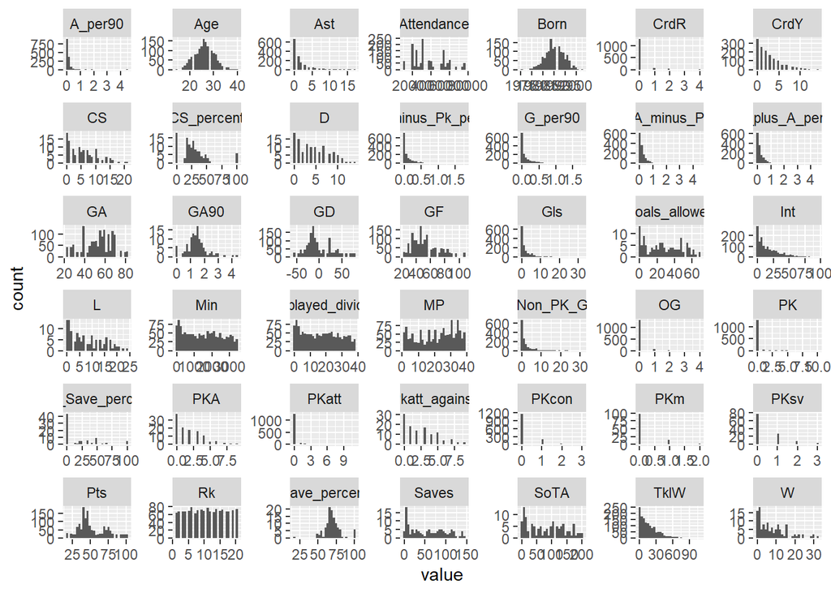

```r
prem_modeling %>%
  select(where(is.numeric)) %>%
  pivot_longer(cols = everything(),
               names_to = "variable",
               values_to = "value") %>%
  ggplot(aes(x = value)) +
  geom_histogram(bins = 30) +
  facet_wrap(vars(variable),
             scales = "free")
```

First, we looked at the proportion of Premier League cards that are given the TOTS designation. Below, we see that a select few cards are given the TOTS designation.

[figure not shown]

```r
theme_set(theme_cowplot())

prem_prop <- prem_modeling %>%
  rename(Revision = revision) %>%
  ggplot(aes(x = Revision, fill = Revision)) +
  geom_bar() +
  scale_fill_manual(values = c("TOTS" = "blue", "Normal" = "gold")) +
  labs(x = "Revision", y = "Count", title = "Proportion of Revisions Within Premier League Dataset Selected for TOTS") +
  theme(plot.title = element_text(hjust = .25, size = 13.5)) +
  geom_vline(xintercept = 0, linetype = "dotted")

prem_prop_logo <- ggdraw() + draw_image("https://www.fifplay.com/img/public/premier-league-2-logo.png", x = .42, y = .23, scale = .25) +
  draw_plot(prem_prop)

prem_prop_logo
```

We then made a density plot of the goalscoring between tots and not to see how important goals are.

[figure not shown]

```r
prem_goals_density <- prem_modeling %>%
  rename(Revision = revision) %>%
  ggplot(aes(x = Gls, fill = Revision)) +
  geom_density(alpha = 0.5) +
  scale_fill_manual(values = c("TOTS" = "blue", "Normal" = "gold")) +
  labs(x = "Goals", y = "Density", title = "Density Plot of Goals Scored in Premier League Season by Revision Status", subtitle = "TOTS players tend to score goals more prolifically than their non-selected counterparts") +
theme(plot.subtitle = element_text(hjust = -.35, size = 11), plot.title = element_text(hjust = .3, size = 13.5))

prem_goals_logo <- ggdraw() + draw_image("https://www.fifplay.com/img/public/premier-league-2-logo.png", x = .42, y = .2, scale = .25) +
  draw_plot(prem_goals_density)

prem_goals_logo
```

Then we made a density plot of table position between tots and not to see if how good the team of the player is important.

[figure not shown]

```r
prem_tablepos_density <- prem_modeling %>%
  rename(Revision = revision) %>%
  ggplot(aes(x = Rk, fill = Revision)) +
  geom_density(alpha = 0.5) +
  scale_fill_manual(values = c("TOTS" = "blue", "Normal" = "gold")) +
  labs(x = "Table Position", y = "Density", title = "Density Plot of Premier League Table Position by Revision Status", subtitle = "Players on winning teams (lower table position) make up a substantial proportion of the Premier League TOTS dataset") +
theme(plot.subtitle = element_text(hjust = .4, size = 8), plot.title = element_text(hjust = .1, size = 13.5))

prem_tablepos_logo <- ggdraw() + draw_image("https://www.fifplay.com/img/public/premier-league-2-logo.png", x = .42, y = .2, scale = .25) +
  draw_plot(prem_tablepos_density)

prem_tablepos_logo
```

Then we looked at how much tots played vs non tots to see if it is only starters that get the cards.

[figure not shown]

```r
prem_mppn_density <- prem_modeling %>%
  rename(Revision = revision) %>%
  ggplot(aes(x = minutes_played_divided_by90, fill = Revision)) +
  geom_density(alpha = 0.5) +
  scale_fill_manual(values = c("TOTS" = "blue", "Normal" = "gold")) +
  labs(x = "Total Minutes Played Divided by 90 (Full Games Played)", y = "Density", title = "Density Plot of Premier League Minutes Played (Per 90 Minutes) by Revision Status", subtitle = "Players who accrue more minutes per contest are more likely to be picked for Premier League TOTS") +
theme(plot.subtitle = element_text(hjust = .45, size = 8), plot.title = element_text(hjust = .5, size = 11))

prem_mppn_logo <- ggdraw() + draw_image("https://www.fifplay.com/img/public/premier-league-2-logo.png", x = .42, y = .2, scale = .25) +
  draw_plot(prem_mppn_density)

prem_mppn_logo
```

Lastly, we looked at the positions of the players.

[figure not shown]

```r
prem_positions <- prem_modeling %>%
  rename(Revision = revision) %>%
  ggplot(aes(x = position, fill = Revision)) +
  geom_bar(position = "identity") +
  scale_fill_manual(values = c("TOTS" = "blue", "Normal" = "gold")) +
  labs(x = "Position", y = "Count", title = "Positional Breakdown Within Premier League Dataset")

prem_positions_logo <- ggdraw() + draw_image("https://www.fifplay.com/img/public/premier-league-2-logo.png", x = .42, y = .22, scale = .25) +
  draw_plot(prem_positions)

prem_positions_logo
```

We then made the recipe for the model. We decided to use a random forest model because it made the most sense for predicting a binary response variable. We had also tried using a lasso model, but they were consistently worse for each league. We removed some redundant variables and some variables that are a little too specific to the certain player. We then decided to upsample the data to include more team of the seasons in the training data. This is where the different leagues really differ. We did some guess and check for each league in order to find the best upsampling that made the best model.

```r
prem_ranger_recipe <- recipe(revision ~., data = prem_training) %>%
  step_rm(Player, Nation, Squad, G_per90, A_per90, minutes_played_divided_by90, Attendance, Born) %>%
  step_upsample(revision, over_ratio = .33) %>%
  step_mutate_at(all_numeric(), fn = ~as.numeric(.))

prem_ranger_recipe %>%
  prep(prem_training) %>%
  juice()
```

```
## # A tibble: 500 x 24
##    position   Int  TklW    OG PKcon   Age    MP   Min   Gls   Ast Non_PK_G    PK
##    <fct>    <dbl> <dbl> <dbl> <dbl> <dbl> <dbl> <dbl> <dbl> <dbl>    <dbl> <dbl>
##  1 CDM         72    39     0     0    30    32  2125     4     2        4     0
##  2 LM          22    20     0     0    26    31  2134     5     4        4     1
##  3 LB          30    36     0     0    24    23  1759     0     1        0     0
##  4 RB          28    45     0     0    27    26  2316     4     3        4     0
##  5 LB          89    64     0     1    30    36  3153     0     2        0     0
##  6 RB          69    41     0     1    29    35  2988     0     1        0     0
##  7 ST          10    19     0     0    30    32  2545     9     5        8     1
##  8 CB          28    21     1     1    27    31  2786     1     1        1     0
##  9 CM           7     9     0     0    30    25  1856     2     5        2     0
## 10 CAM         19    15     1     0    24    36  2492     8     5        8     0
## # ... with 490 more rows, and 12 more variables: PKatt <dbl>, CrdY <dbl>,
## #   CrdR <dbl>, G_plus_A_per90 <dbl>, G_minus_Pk_per90 <dbl>,
## #   G_plus_A_minus_PK_per90 <dbl>, Rk <dbl>, GF <dbl>, GA <dbl>, GD <dbl>,
## #   Pts <dbl>, revision <fct>
```

Next we created the workflow.

```r
prem_ranger <- rand_forest(mtry = tune(),
              min_n = tune(),
              trees = 100) %>%
  set_mode("classification") %>%
  set_engine("ranger")

prem_ranger_wf <-
  workflow() %>%
  add_recipe(prem_ranger_recipe) %>%
  add_model(prem_ranger)

prem_ranger_wf
```

```
## == Workflow ====================================================================
## Preprocessor: Recipe
## Model: rand_forest()
##
## -- Preprocessor ----------------------------------------------------------------
## 3 Recipe Steps
##
## * step_rm()
## * step_upsample()
## * step_mutate_at()
##
## -- Model -----------------------------------------------------------------------
## Random Forest Model Specification (classification)
##
## Main Arguments:
##   mtry = tune()
##   trees = 100
##   min_n = tune()
##
## Computational engine: ranger
```

Then we created the cross validation and tuned the model for the min n and mtry. Then we looked at the roc_auc and accuracy for the crossed validated model.

```r
set.seed(494)
prem_cv <- vfold_cv(prem_training, v = 5)

prem_rf_grid <- grid_regular(min_n(), finalize(mtry(), prem_training %>% select(-revision)), levels = 3)

ctrl_res <- control_stack_grid()

prem_ranger_cv <- prem_ranger_wf %>%
  tune_grid(resamples = prem_cv,
           grid = prem_rf_grid,
           control = ctrl_res)
```

[output not shown]

[output not shown]

[output not shown]

[output not shown]

[output not shown]

[output not shown]

[output not shown]

[output not shown]

[output not shown]

[output not shown]

[output not shown]

[output not shown]

[output not shown]

[output not shown]

[output not shown]

```r
collect_metrics(prem_ranger_cv)
```

```
## # A tibble: 18 x 8
##     mtry min_n .metric  .estimator  mean     n std_err .config
##    <int> <int> <chr>    <chr>      <dbl> <int>   <dbl> <chr>
##  1     1     2 accuracy binary     0.923     5  0.0160 Preprocessor1_Model1
##  2     1     2 roc_auc  binary     0.952     5  0.0115 Preprocessor1_Model1
##  3     1    21 accuracy binary     0.925     5  0.0131 Preprocessor1_Model2
##  4     1    21 roc_auc  binary     0.957     5  0.0115 Preprocessor1_Model2
##  5     1    40 accuracy binary     0.923     5  0.0175 Preprocessor1_Model3
##  6     1    40 roc_auc  binary     0.950     5  0.0134 Preprocessor1_Model3
##  7    16     2 accuracy binary     0.932     5  0.0223 Preprocessor1_Model4
##  8    16     2 roc_auc  binary     0.937     5  0.0282 Preprocessor1_Model4
##  9    16    21 accuracy binary     0.939     5  0.0187 Preprocessor1_Model5
## 10    16    21 roc_auc  binary     0.945     5  0.0251 Preprocessor1_Model5
## 11    16    40 accuracy binary     0.942     5  0.0162 Preprocessor1_Model6
## 12    16    40 roc_auc  binary     0.946     5  0.0256 Preprocessor1_Model6
## 13    31     2 accuracy binary     0.923     5  0.0233 Preprocessor1_Model7
## 14    31     2 roc_auc  binary     0.923     5  0.0400 Preprocessor1_Model7
## 15    31    21 accuracy binary     0.925     5  0.0212 Preprocessor1_Model8
## 16    31    21 roc_auc  binary     0.924     5  0.0401 Preprocessor1_Model8
## 17    31    40 accuracy binary     0.944     5  0.0179 Preprocessor1_Model9
## 18    31    40 roc_auc  binary     0.933     5  0.0288 Preprocessor1_Model9
```

Next we selected the best tuning using accuracy and finalized the workflow.

```r
prem_best1 <- prem_ranger_cv %>%
  select_best(metric = "accuracy")

prem_ranger_final_wf<- prem_ranger_wf %>%
  finalize_workflow(prem_best1)
```

Then we fit the model on the training data.

```r
set.seed(494)
prem_ranger_fit <- prem_ranger_final_wf %>%
  fit(prem_training)
```

And created an explainer.

```r
set.seed(494)

prem_rf_explain <-
  explain_tidymodels(
    model = prem_ranger_fit,
    data = prem_training %>% select(-revision),
    y = as.numeric(prem_training$revision == "TOTS"),
    label = "rf"
  )
```

```
## Preparation of a new explainer is initiated
##   -> model label       :  rf
##   -> data              :  428  rows  31  cols
##   -> target variable   :  428  values
##   -> predict function  :  yhat.workflow  will be used (  default  )
##   -> predicted values  :  No value for predict function target column. (  default  )
##   -> model_info        :  package tidymodels , ver. 0.1.2 , task classification (  default  )
##   -> predicted values  :  numerical, min =  0 , mean =  0.1600099 , max =  1
##   -> residual function :  difference between y and yhat (  default  )
##   -> residuals         :  numerical, min =  -0.9972222 , mean =  -0.03851457 , max =  0.8262757
##   A new explainer has been created!
```

We used the explainer to created a variable importance plot as this felt like one of the questions we were really trying to answer.

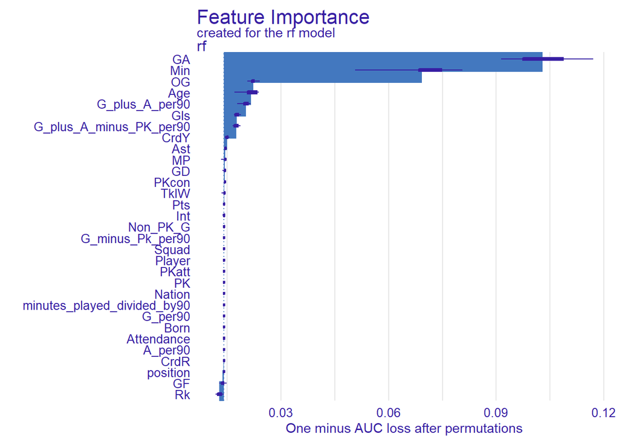

```r
set.seed(494)

prem_rf_var_imp <-
  model_parts(
    prem_rf_explain
    )

plot(prem_rf_var_imp)
```

```r
prem_ranger_test <- prem_ranger_final_wf %>%
  last_fit(prem_split)
```

```
## ! train/test split: preprocessor 1/1, model 1/1: 31 columns were requested but there were 23...
```

```r
prem_ranger_test %>%
  collect_metrics()
```

```
## # A tibble: 2 x 4
##   .metric  .estimator .estimate .config
##   <chr>    <chr>          <dbl> <chr>
## 1 accuracy binary         0.880 Preprocessor1_Model1
## 2 roc_auc  binary         0.858 Preprocessor1_Model1
```

Then we made a confusion matrix of the model on the testing data to see how well the model was working. This is what we mostly used to decide if the model was good or if something (like the upsampling) needed to change.

```r
prem_preds1 <- prem_ranger_test %>%
  collect_predictions()

prem_preds1 %>%
  conf_mat(`revision`, .pred_class)
```

```
##           Truth
## Prediction Normal TOTS
##     Normal    116    8
##     TOTS        9    9
```

Then we fit the model on the testing data in way that it would be usable to us and that we could see individual predicted probabilities. Then we made another confusion matrix and colored it and made it look nice and presentable.

[figure not shown]

```r
prem_ranger_test <- prem_testing %>%
  bind_cols(predict(prem_ranger_fit, new_data = prem_testing, type = "prob")) %>%
  bind_cols(predict(prem_ranger_fit, new_data = prem_testing))

prem_rf_preds <- prem_ranger_test %>%
  conf_mat(revision, .pred_class)

prem_rf_ggconfusion <- autoplot(prem_rf_preds, type = "heatmap") + labs(title = "Confusion Matrix of Premier League Random Forest Model") + scale_fill_gradient(low = "blue", high = "red") + theme(plot.title = element_text(hjust = .5, size = 15))


prem_rf_final_confusion <- ggdraw() + draw_image("https://www.fifplay.com/img/public/premier-league-2-logo.png", x = -.43, y = .4, scale = .18) +
  draw_plot(prem_rf_ggconfusion)

prem_rf_final_confusion
```

```r
prem_ranger_test %>%
  conf_mat(revision, .pred_class)
```

```
##           Truth
## Prediction Normal TOTS
##     Normal    116    8
##     TOTS        9    9
```

Then we looked at what players the model was predicting incorrectly to better understand the pitfalls of the model.

```r
prem_ranger_test %>%
  filter(revision != .pred_class)
```

```
##                   Player revision position Int TklW OG PKcon Nation
## 1     Kevin De Bruyne 17     TOTS       CM  24   35  0     0    BEL
## 2           Eric Dier 17   Normal      CDM  37   34  0     0    ENG
## 3        Adam Lallana 17     TOTS       CM  20   35  0     0    ENG
## 4          Sadio Mane 17     TOTS       RW  11   18  0     1    SEN
## 5        Victor Moses 17   Normal       RB  41   42  0     0    NGA
## 6          Paul Pogba 17   Normal       CM  37   40  0     1    FRA
## 7      Victor Wanyama 17   Normal      CDM  39   64  0     0    KEN
## 8   Philippe Coutinho 17   Normal       LW  18   25  0     0    BRA
## 9       Sergio Aguero 18     TOTS       ST   8    5  0     0    ARG
## 10          Eric Dier 18   Normal       CB  30   35  0     0    ENG
## 11 Abdoulaye Doucoure 18     TOTS      CDM  41   41  0     1    FRA
## 12   Andrew Robertson 18     TOTS       LB  24   21  0     0    SCO
## 13   Antonio Valencia 18   Normal       RB  43   37  0     0    ECU
## 14  Christian Eriksen 19     TOTS      CAM  11   27  0     0    DEN
```

[output cut: 75 more lines]

Then we created a modeling data set for the current season.

```r
prem_modeling21 <- fifa21_modeling %>%
  mutate(revision = as.factor(revision), Nation = as.factor(Nation), Age = as.integer(Age))
```

```r
prem_modeling_outfield21 <- prem_modeling21 %>%
  filter(position != "GK") %>%
  filter(minutes_played_divided_by90 >= 19) %>%
  mutate(position = ifelse(position == "RWB", "RB", ifelse(position == "LWB", "LB", position)))
```

And we fit our model to it in order to see how well the model preformed on new data.

```r
prem_ranger_test21 <- prem_modeling_outfield21 %>%
  bind_cols(predict(prem_ranger_fit, new_data = prem_modeling_outfield21, type = "prob")) %>%
  bind_cols(predict(prem_ranger_fit, new_data = prem_modeling_outfield21))
```

We then used that to show our predicted team of the season for each league this year. We used the top five predicted probabilities for each position group because the model did not predict a lot of team of the seasons, but it tended to order things well.

```r
prem_ranger_test_att <- prem_ranger_test21 %>%
  filter(position %in% c("ST", "RW", "CF", "LW")) %>%
  arrange(desc(.pred_TOTS)) %>%
  head(5) %>%
  mutate(Role = ifelse(rank(.pred_TOTS, ties.method = c("first")) >= 3, "Starter", "Bench"), Position = 1)
```

```r
prem_ranger_test_mid <- prem_ranger_test21 %>%
  filter(position %in% c("CAM", "CM", "CDM", "LM", "RM")) %>%
  arrange(desc(.pred_TOTS)) %>%
  head(5) %>%
  mutate(Role = ifelse(rank(.pred_TOTS, ties.method = c("first")) >= 3, "Starter", "Bench"), Position = 2)
```

```r
prem_ranger_test_def <- prem_ranger_test21 %>%
  filter(position %in% c("LB", "CB", "RB")) %>%
  arrange(desc(.pred_TOTS)) %>%
  head(5)  %>%
    mutate(Role = ifelse(rank(.pred_TOTS, ties.method = c("first")) >= 2, "Starter", "Bench"), Position = 3)
```

```r
prem_tots_21 <- rbind(prem_ranger_test_att, prem_ranger_test_mid, prem_ranger_test_def) %>%
  arrange(desc(Role), Position) %>%
  distinct(Player, Role, position, Squad, Gls, Ast, Pts, Rk, MP, Starts, Min, .pred_TOTS) %>%
  rename(Position = position, Goals = Gls, Assists = Ast, Points = Pts, `Team Rank` = Rk, `Matches Played` = MP, `Predicted TOTS Probability` = .pred_TOTS, `Projected Role` = Role)

prem_tots_formatted <- formattable(prem_tots_21[1:15,1:12])

kable(prem_tots_formatted, align = c(rep('c',12)))  %>%
  row_spec(0) %>%
  kable_styling(full_width = F) %>%
  add_header_above(c("Premier League 2021 Predicted TOTS" = 12), background = "purple", color = "white") %>%
  row_spec(1:10, background = "green", color = "white") %>%
  row_spec(11:15, background = "red", color = "white")
```

| Premier League 2021 Predicted TOTS Player | Premier League 2021 Predicted TOTS Position | Premier League 2021 Predicted TOTS Squad | Premier League 2021 Predicted TOTS Matches Played | Premier League 2021 Predicted TOTS Starts | Premier League 2021 Predicted TOTS Min | Premier League 2021 Predicted TOTS Goals | Premier League 2021 Predicted TOTS Assists | Premier League 2021 Predicted TOTS Team Rank | Premier League 2021 Predicted TOTS Points | Premier League 2021 Predicted TOTS Predicted TOTS Probability | Premier League 2021 Predicted TOTS Projected Role |
| --- | --- | --- | --- | --- | --- | --- | --- | --- | --- | --- | --- |
| Harry Kane | ST | Tottenham | 30 | 30 | 2632 | 21 | 13 | 7 | 53 | 0.9356553 | Starter |
| Ollie Watkins | ST | Aston Villa | 32 | 32 | 2880 | 12 | 4 | 11 | 45 | 0.9068442 | Starter |
| Timo Werner | ST | Chelsea | 31 | 25 | 2243 | 6 | 6 | 4 | 58 | 0.9019166 | Starter |
| Bruno Fernandes | CAM | Manchester Utd | 33 | 32 | 2821 | 16 | 11 | 2 | 67 | 0.9895714 | Starter |
| Rodri | CDM | Manchester City | 29 | 27 | 2353 | 2 | 1 | 1 | 77 | 0.9751046 | Starter |
| Marcus Rashford | LM | Manchester Utd | 33 | 31 | 2686 | 10 | 8 | 2 | 67 | 0.9692937 | Starter |
| Aaron Wan Bissaka | RB | Manchester Utd | 31 | 31 | 2790 | 2 | 2 | 2 | 67 | 0.9903896 | Starter |
| Harry Maguire | CB | Manchester Utd | 33 | 33 | 2970 | 2 | 1 | 2 | 67 | 0.9798704 | Starter |
| Matt Targett | LB | Aston Villa | 32 | 32 | 2864 | 0 | 1 | 11 | 45 | 0.9054538 | Starter |
| Ezri Konsa | CB | Aston Villa | 30 | 29 | 2656 | 2 | 0 | 11 | 45 | 0.9037871 | Starter |
| Mohamed Salah | RW | Liverpool | 32 | 29 | 2633 | 20 | 3 | 6 | 54 | 0.7402674 | Bench |
| Jamie Vardy | ST | Leicester City | 29 | 26 | 2401 | 13 | 8 | 3 | 62 | 0.5050886 | Bench |
| Mason Mount | CAM | Chelsea | 32 | 28 | 2545 | 6 | 4 | 4 | 58 | 0.9170196 | Bench |
| John McGinn | CM | Aston Villa | 31 | 31 | 2790 | 2 | 5 | 11 | 45 | 0.9095714 | Bench |
| Edouard Mendy | LB | Chelsea | 27 | 27 | 2430 | 0 | 0 | 4 | 58 | 0.8524394 | Bench |

### Other Leagues Code

```r
fifa19_modeling_la_liga2 <- fifa19_modeling_la_liga %>%
  mutate(Player = paste(Player, '19'))

fifa18_modeling_la_liga2 <- fifa18_modeling_la_liga %>%
  mutate(Player = paste(Player, '18'))

fifa17_modeling_la_liga2 <- fifa17_modeling_la_liga %>%
  mutate(Player = paste(Player, '17'))



la_liga_modeling <- fifa17_modeling_la_liga2%>%
  bind_rows(fifa18_modeling_la_liga2, fifa19_modeling_la_liga2) %>%
  select(-Starts) %>%
  mutate(revision = as.factor(revision), Nation = as.factor(Nation))
```

```r
la_liga_modeling_outfield <- la_liga_modeling %>%
  filter(position != "GK") %>%
  filter(minutes_played_divided_by90 >= 19) %>%
  mutate(position = ifelse(position == "RWB", "RB", ifelse(position == "LWB", "LB", ifelse(position == "CF", "ST", position)))) %>%
  select(-Goals_allowed, -GA90, -SoTA, -Saves, -Save_percent, -W, -L, -D, -CS, -CS_percent, -Pkatt_against, -PKA, -PKsv, -Pk_Save_percent, -PKm)
```

```r
set.seed(494)
la_liga_split <- initial_split(la_liga_modeling_outfield, prop = .75, strata = "revision")
la_liga_training <- training(la_liga_split)
la_liga_testing <- testing(la_liga_split)
```

```r
la_liga_train_metrics <- la_liga_training %>%
  mutate(Type = "Training") %>%
  rename(Revision = revision) %>%
  group_by(Revision, Type) %>%
  summarize(Goals = mean(Gls, na.rm = T), Assists = mean(Ast, na.rm = T), `Non PK Goals` = mean(Non_PK_G, na.rm = T), PK = mean(PK, na.rm = T), `Team Rank` = mean(Rk, na.rm = T), `Minutes Per 90` = mean(Min, na.rm = T)/90 , `Goals SD` = sd(Gls, na.rm = T), `Assists SD` = sd(Ast, na.rm = T), `Non PK Goals SD` = sd(Non_PK_G, na.rm = T),`Team Rank SD` = sd(Rk, na.rm = T), `Minutes Per 90 SD` = sd(Min, na.rm = T)/90)

la_liga_test_metrics <- la_liga_testing %>%
  mutate(Type = "Testing") %>%
  rename(Revision = revision) %>%
  group_by(Revision, Type) %>%
  summarize(Goals = mean(Gls, na.rm = T), Assists = mean(Ast, na.rm = T), `Non PK Goals` = mean(Non_PK_G, na.rm = T), PK = mean(PK, na.rm = T),`Team Rank` = mean(Rk, na.rm = T), `Minutes Per 90` = mean(Min, na.rm = T)/90, `Goals SD` = sd(Gls, na.rm = T), `Assists SD` = sd(Ast, na.rm = T), `Non PK Goals SD` = sd(Non_PK_G, na.rm = T),`Team Rank SD` = sd(Rk, na.rm = T), `Minutes Per 90 SD` = sd(Min, na.rm = T)/90)

la_liga_rebound_split <- rbind(la_liga_train_metrics, la_liga_test_metrics) %>% arrange(Revision)

la_liga_metrics_table <- formattable(la_liga_rebound_split[1:4,1:13])

kable(la_liga_metrics_table, align = c(rep('c', 1))) %>%
  row_spec(0) %>%
  kable_styling(full_width = F) %>%
  add_header_above(c("La Liga Training and Testing Group Comparison for Suspected KPIs" = 13), background = "navy", color = "red")
```

| La Liga Training and Testing Group Comparison for Suspected KPIs Revision | La Liga Training and Testing Group Comparison for Suspected KPIs Type | La Liga Training and Testing Group Comparison for Suspected KPIs Goals | La Liga Training and Testing Group Comparison for Suspected KPIs Assists | La Liga Training and Testing Group Comparison for Suspected KPIs Non PK Goals | La Liga Training and Testing Group Comparison for Suspected KPIs PK | La Liga Training and Testing Group Comparison for Suspected KPIs Team Rank | La Liga Training and Testing Group Comparison for Suspected KPIs Minutes Per 90 | La Liga Training and Testing Group Comparison for Suspected KPIs Goals SD | La Liga Training and Testing Group Comparison for Suspected KPIs Assists SD | La Liga Training and Testing Group Comparison for Suspected KPIs Non PK Goals SD | La Liga Training and Testing Group Comparison for Suspected KPIs Team Rank SD | La Liga Training and Testing Group Comparison for Suspected KPIs Minutes Per 90 SD |
| --- | --- | --- | --- | --- | --- | --- | --- | --- | --- | --- | --- | --- |
| Normal | Training | 2.988764 | 2.207865 | 2.705056 | 0.2837079 | 10.772472 | 26.22697 | 3.773874 | 1.999027 | 3.360093 | 5.336711 | 4.584873 |
| Normal | Testing | 2.838983 | 2.347458 | 2.550848 | 0.2881356 | 10.686441 | 26.31591 | 3.215801 | 2.419215 | 2.784565 | 5.743371 | 4.868298 |
| TOTS | Training | 8.958333 | 5.000000 | 7.520833 | 1.4375000 | 4.083333 | 29.57315 | 8.829251 | 3.695886 | 7.795224 | 3.923922 | 3.642296 |
| TOTS | Testing | 11.933333 | 4.733333 | 10.733333 | 1.2000000 | 6.333333 | 30.12296 | 12.831138 | 3.712270 | 11.516861 | 6.488084 | 4.007976 |

```r
la_liga_ranger_recipe <- recipe(revision ~., data = la_liga_training) %>%
  step_rm(Player, Nation, Squad, Born, G_per90, A_per90, minutes_played_divided_by90, OG, Attendance) %>%
  step_upsample(revision, over_ratio = .5) %>%
  step_mutate_at(all_numeric(), fn = ~as.numeric(.))

la_liga_ranger_recipe %>%
  prep(la_liga_training) %>%
  juice()
```

```
## # A tibble: 534 x 23
##    position   Int  TklW PKcon   Age    MP   Min   Gls   Ast Non_PK_G    PK PKatt
##    <fct>    <dbl> <dbl> <dbl> <dbl> <dbl> <dbl> <dbl> <dbl>    <dbl> <dbl> <dbl>
##  1 CM          12    23     0    22    31  2480     3     2        3     0     0
##  2 CB          35    32     2    26    25  2023     0     1        0     0     0
##  3 CAM         53    66     0    19    30  2341     2     2        2     0     0
##  4 LM          53    52     1    21    29  2176     1     6        1     0     0
##  5 CM          55    40     0    27    36  3163     7     5        7     0     0
##  6 CB          43    38     0    32    25  1928     1     3        0     1     1
##  7 ST           7    12     0    26    33  2074    13     2       13     0     0
##  8 CDM         16    32     0    26    30  2385     0     5        0     0     0
##  9 LB          29    29     0    26    27  1737     0     2        0     0     1
## 10 CB          31    41     2    27    37  3330     1     0        1     0     0
## # ... with 524 more rows, and 11 more variables: CrdY <dbl>, CrdR <dbl>,
## #   G_plus_A_per90 <dbl>, G_minus_Pk_per90 <dbl>,
## #   G_plus_A_minus_PK_per90 <dbl>, Rk <dbl>, GF <dbl>, GA <dbl>, GD <dbl>,
## #   Pts <dbl>, revision <fct>
```

```r
la_liga_ranger <- rand_forest(mtry = tune(),
              min_n = tune(),
              trees = 100) %>%
  set_mode("classification") %>%
  set_engine("ranger")

la_liga_ranger_wf <-
  workflow() %>%
  add_recipe(la_liga_ranger_recipe) %>%
  add_model(la_liga_ranger)

la_liga_ranger_wf
```

```
## == Workflow ====================================================================
## Preprocessor: Recipe
## Model: rand_forest()
##
## -- Preprocessor ----------------------------------------------------------------
## 3 Recipe Steps
##
## * step_rm()
## * step_upsample()
## * step_mutate_at()
##
## -- Model -----------------------------------------------------------------------
## Random Forest Model Specification (classification)
##
## Main Arguments:
##   mtry = tune()
##   trees = 100
##   min_n = tune()
##
## Computational engine: ranger
```

```r
set.seed(494)
la_liga_cv <- vfold_cv(la_liga_training, v = 5)

la_liga_rf_grid <- grid_regular(min_n(), finalize(mtry(), la_liga_training %>% select(-revision)), levels = 3)

ctrl_res <- control_stack_grid()

la_liga_ranger_cv <- la_liga_ranger_wf %>%
  tune_grid(resamples = la_liga_cv,
           grid = la_liga_rf_grid,
           control = ctrl_res)
```

[output not shown]

[output not shown]

[output not shown]

[output not shown]

[output not shown]

[output not shown]

[output not shown]

[output not shown]

[output not shown]

[output not shown]

[output not shown]

[output not shown]

[output not shown]

[output not shown]

[output not shown]

```r
collect_metrics(la_liga_ranger_cv)
```

```
## # A tibble: 18 x 8
##     mtry min_n .metric  .estimator  mean     n std_err .config
##    <int> <int> <chr>    <chr>      <dbl> <int>   <dbl> <chr>
##  1     1     2 accuracy binary     0.896     5  0.0190 Preprocessor1_Model1
##  2     1     2 roc_auc  binary     0.916     5  0.0183 Preprocessor1_Model1
##  3     1    21 accuracy binary     0.876     5  0.0225 Preprocessor1_Model2
##  4     1    21 roc_auc  binary     0.909     5  0.0219 Preprocessor1_Model2
##  5     1    40 accuracy binary     0.898     5  0.0167 Preprocessor1_Model3
##  6     1    40 roc_auc  binary     0.920     5  0.0208 Preprocessor1_Model3
##  7    16     2 accuracy binary     0.871     5  0.0227 Preprocessor1_Model4
##  8    16     2 roc_auc  binary     0.897     5  0.0333 Preprocessor1_Model4
##  9    16    21 accuracy binary     0.879     5  0.0270 Preprocessor1_Model5
## 10    16    21 roc_auc  binary     0.893     5  0.0378 Preprocessor1_Model5
## 11    16    40 accuracy binary     0.876     5  0.0277 Preprocessor1_Model6
## 12    16    40 roc_auc  binary     0.907     5  0.0295 Preprocessor1_Model6
## 13    31     2 accuracy binary     0.879     5  0.0238 Preprocessor1_Model7
## 14    31     2 roc_auc  binary     0.896     5  0.0370 Preprocessor1_Model7
## 15    31    21 accuracy binary     0.876     5  0.0325 Preprocessor1_Model8
## 16    31    21 roc_auc  binary     0.894     5  0.0386 Preprocessor1_Model8
## 17    31    40 accuracy binary     0.878     5  0.0287 Preprocessor1_Model9
## 18    31    40 roc_auc  binary     0.896     5  0.0383 Preprocessor1_Model9
```

```r
la_liga_best1 <- la_liga_ranger_cv %>%
  select_best(metric = "accuracy")

la_liga_ranger_final_wf<- la_liga_ranger_wf %>%
  finalize_workflow(la_liga_best1)
```

```r
set.seed(494)
la_liga_ranger_fit <- la_liga_ranger_final_wf %>%
  fit(la_liga_training)


la_liga_rf_explain <-
  explain_tidymodels(
    model = la_liga_ranger_fit,
    data = la_liga_training %>% select(-revision),
    y = as.numeric(la_liga_training$revision == "TOTS"),
    label = "rf"
  )
```

```
## Preparation of a new explainer is initiated
##   -> model label       :  rf
##   -> data              :  404  rows  31  cols
##   -> target variable   :  404  values
##   -> predict function  :  yhat.workflow  will be used (  default  )
##   -> predicted values  :  No value for predict function target column. (  default  )
##   -> model_info        :  package tidymodels , ver. 0.1.2 , task classification (  default  )
##   -> predicted values  :  numerical, min =  0.009672085 , mean =  0.2081853 , max =  0.8995726
##   -> residual function :  difference between y and yhat (  default  )
##   -> residuals         :  numerical, min =  -0.7048752 , mean =  -0.08937338 , max =  0.7633606
##   A new explainer has been created!
```

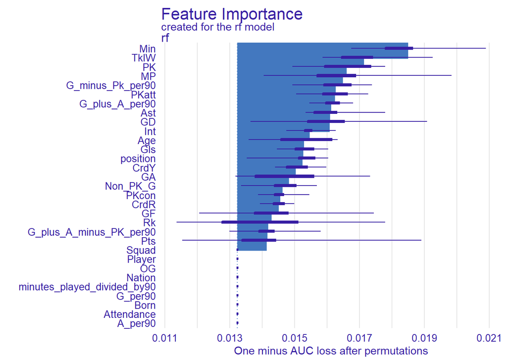

```r
la_liga_rf_var_imp <-
  model_parts(
    la_liga_rf_explain
    )

plot(la_liga_rf_var_imp)
```

```r
la_liga_ranger_test <- la_liga_ranger_final_wf %>%
  last_fit(la_liga_split)

la_liga_ranger_test %>%
  collect_metrics()
```

```
## # A tibble: 2 x 4
##   .metric  .estimator .estimate .config
##   <chr>    <chr>          <dbl> <chr>
## 1 accuracy binary         0.925 Preprocessor1_Model1
## 2 roc_auc  binary         0.854 Preprocessor1_Model1
```

```r
preds1 <- la_liga_ranger_test %>%
  collect_predictions()

preds1 %>%
  conf_mat(revision, .pred_class)
```

```
##           Truth
## Prediction Normal TOTS
##     Normal    114    6
##     TOTS        4    9
```

```r
la_liga_ranger_test <- la_liga_testing %>%
  bind_cols(predict(la_liga_ranger_fit, new_data = la_liga_testing, type = "prob")) %>%
  bind_cols(predict(la_liga_ranger_fit, new_data = la_liga_testing))
```

```r
la_liga_ranger_test %>%
  conf_mat(revision, .pred_class)
```

```
##           Truth
## Prediction Normal TOTS
##     Normal    112    6
##     TOTS        6    9
```

[figure not shown]

```r
la_liga_ranger_test <- la_liga_testing %>%
  bind_cols(predict(la_liga_ranger_fit, new_data = la_liga_testing, type = "prob")) %>%
  bind_cols(predict(la_liga_ranger_fit, new_data = la_liga_testing))

la_liga_rf_preds <- la_liga_ranger_test %>%
  conf_mat(revision, .pred_class)

la_liga_rf_ggconfusion <- autoplot(la_liga_rf_preds, type = "heatmap") + labs(title = "Confusion Matrix of La Liga Random Forest Model") + scale_fill_gradient(low = "blue", high = "red") + theme(plot.title = element_text(hjust = .5, size = 15))

la_liga_rf_final_confusion <- ggdraw() + draw_image("https://upload.wikimedia.org/wikipedia/commons/thumb/1/13/LaLiga.svg/1200px-LaLiga.svg.png", x = -.43, y = .4, scale = .18) +
  draw_plot(la_liga_rf_ggconfusion)

la_liga_rf_final_confusion
```

```r
la_liga_ranger_test %>%
  filter(revision != .pred_class)
```

```
##                     Player revision position Int TklW OG PKcon Nation
## 1         Sergi Roberto 17   Normal       RB  49   44  0     0    ESP
## 2         Pablo Sarabia 17   Normal       RM  32   34  0     0    ESP
## 3  Kevin Prince Boateng 17     TOTS       ST  19   16  0     2    GHA
## 4         Dani Carvajal 17     TOTS       RB  45   41  0     0    ESP
## 5         Karim Benzema 18   Normal       ST   6    6  0     0    FRA
## 6                  Koke 18   Normal       CM  23   41  0     0    ESP
## 7               Marcelo 18   Normal       LB  26   32  0     0    BRA
## 8              Paulinho 18   Normal       CM  18   26  0     0    BRA
## 9               Roberto 18     TOTS       RB   0    0  0     0    ESP
## 10          Ever Banega 19     TOTS      CDM  31   44  0     1    ARG
## 11                Djene 19     TOTS       CB  59   36  0     3    TOG
## 12        Mario Hermoso 19     TOTS       CB  25   25  0     2    ESP
##              Squad Age Born MP  Min minutes_played_divided_by90 Gls Ast
## 1        Barcelona  24 1992 32 2385                        26.5   0   6
```

[output cut: 50 more lines]

```r
la_liga_modeling21 <- fifa21_modeling_la_liga %>%
  mutate(revision = as.factor(revision), Nation = as.factor(Nation), Age = as.integer(Age))
```

```r
la_liga_modeling_outfield21 <- la_liga_modeling21 %>%
  filter(position != "GK") %>%
  filter(minutes_played_divided_by90 >= 14) %>%
  mutate(position = ifelse(position == "RWB", "RB", ifelse(position == "LWB", "LB", ifelse(position == "CF", "ST", position))))
```

```r
la_liga_ranger_test21 <- la_liga_modeling_outfield21 %>%
  bind_cols(predict(la_liga_ranger_fit, new_data = la_liga_modeling_outfield21, type = "prob")) %>%
  bind_cols(predict(la_liga_ranger_fit, new_data = la_liga_modeling_outfield21))
la_liga_ranger_test_att <- la_liga_ranger_test21 %>%
  filter(position %in% c("ST", "RW", "CF", "LW")) %>%
  arrange(desc(.pred_TOTS)) %>%
  head(5) %>%
  mutate(Role = ifelse(rank(.pred_TOTS, ties.method = c("first")) >= 3, "Starter", "Bench"), Position = 1)
```

```r
la_liga_ranger_test_mid <- la_liga_ranger_test21 %>%
  filter(position %in% c("CAM", "CM", "CDM", "LM", "RM")) %>%
  arrange(desc(.pred_TOTS)) %>%
  head(5) %>%
  mutate(Role = ifelse(rank(.pred_TOTS, ties.method = c("first")) >= 3, "Starter", "Bench"), Position = 2)
```

```r
la_liga_ranger_test_def <- la_liga_ranger_test21 %>%
  filter(position %in% c("LB", "CB", "RB")) %>%
  arrange(desc(.pred_TOTS)) %>%
  head(5) %>%
  mutate(Role = ifelse(rank(.pred_TOTS, ties.method = c("first")) >= 2, "Starter", "Bench"), Position = 3)
```

```r
la_liga_tots_21 <- rbind(la_liga_ranger_test_att, la_liga_ranger_test_mid, la_liga_ranger_test_def) %>%
  arrange(desc(Role), Position) %>%
  distinct(Player, Role, position, Squad, Gls, Ast, Pts, Rk, MP, Min, .pred_TOTS) %>%
  rename(Position = position, Goals = Gls, Assists = Ast, Points = Pts, `Team Rank` = Rk, `Matches Played` = MP, `Predicted TOTS Probability` = .pred_TOTS, `Projected Role` = Role)

la_liga_tots_formatted <- formattable(la_liga_tots_21[1:15,1:11])

kable(la_liga_tots_formatted, align = c(rep('c',11)))  %>%
  row_spec(0) %>%
  kable_styling(full_width = F) %>%
  add_header_above(c("La Liga 2021 Predicted TOTS" = 11), background = "navy", color = "red") %>%
  row_spec(1:10, background = "green", color = "white") %>%
  row_spec(11:15, background = "red", color = "white")
```

| La Liga 2021 Predicted TOTS Player | La Liga 2021 Predicted TOTS Position | La Liga 2021 Predicted TOTS Squad | La Liga 2021 Predicted TOTS Matches Played | La Liga 2021 Predicted TOTS Min | La Liga 2021 Predicted TOTS Goals | La Liga 2021 Predicted TOTS Assists | La Liga 2021 Predicted TOTS Team Rank | La Liga 2021 Predicted TOTS Points | La Liga 2021 Predicted TOTS Predicted TOTS Probability | La Liga 2021 Predicted TOTS Projected Role |
| --- | --- | --- | --- | --- | --- | --- | --- | --- | --- | --- |
| Lionel Messi | RW | Barcelona | 30 | 2573 | 25 | 9 | 3 | 71 | 0.7971108 | Starter |
| Karim Benzema | ST | Real Madrid | 29 | 2458 | 21 | 7 | 2 | 71 | 0.6724976 | Starter |
| Luis Suarez | ST | Atlético Madrid | 27 | 2078 | 19 | 2 | 1 | 73 | 0.6554061 | Starter |
| Marcos Llorente | CM | Atlético Madrid | 32 | 2529 | 11 | 10 | 1 | 73 | 0.7294993 | Starter |
| Angel Correa | RM | Atlético Madrid | 33 | 2022 | 7 | 8 | 1 | 73 | 0.6512432 | Starter |
| Koke | CM | Atlético Madrid | 32 | 2635 | 1 | 2 | 1 | 73 | 0.5895652 | Starter |
| Jordi Alba | LB | Barcelona | 29 | 2530 | 3 | 5 | 3 | 71 | 0.5223118 | Starter |
| Stefan Savic | CB | Atlético Madrid | 29 | 2593 | 1 | 0 | 1 | 73 | 0.5010280 | Starter |
| Raphael Varane | CB | Real Madrid | 29 | 2580 | 2 | 0 | 2 | 71 | 0.4988453 | Starter |
| Mario Hermoso | CB | Atlético Madrid | 26 | 2181 | 1 | 1 | 1 | 73 | 0.4427156 | Starter |
| Antoine Griezmann | ST | Barcelona | 30 | 2095 | 11 | 6 | 3 | 71 | 0.6378605 | Bench |
| Joao Felix | ST | Atlético Madrid | 26 | 1443 | 7 | 4 | 1 | 73 | 0.5389632 | Bench |
| Pedri | LM | Barcelona | 32 | 2130 | 2 | 3 | 3 | 71 | 0.5790173 | Bench |
| Saul Niguez | CM | Atlético Madrid | 28 | 1771 | 2 | 1 | 1 | 73 | 0.5698332 | Bench |
| Felipe | CB | Atlético Madrid | 26 | 1688 | 0 | 0 | 1 | 73 | 0.4236295 | Bench |

```r
ligue1_fifa19_modeling <- ligue1_fifa19_modeling %>%
  mutate(Player = paste(Player, '19'))

ligue1_fifa18_modeling <- ligue1_fifa18_modeling %>%
  mutate(Player = paste(Player, '18'))

ligue1_fifa17_modeling <- ligue1_fifa17_modeling %>%
  mutate(Player = paste(Player, '17'))

ligue1_modeling <- ligue1_fifa17_modeling %>%
  bind_rows(ligue1_fifa18_modeling, ligue1_fifa19_modeling) %>%
  mutate(revision = as.factor(revision), Nation = as.factor(Nation))
```

```r
ligue1_modeling_outfield <- ligue1_modeling %>%
  filter(position != "GK") %>%
  filter(minutes_played_divided_by90 >= 19) %>%
  mutate(position = ifelse(position == "RWB", "RB", ifelse(position == "LWB", "LB", position))) %>%
  select(-Goals_allowed, -GA90, -SoTA, -Saves, -Save_percent, -W, -L, -D, -CS, -CS_percent, -Pkatt_against, -PKA, -PKsv, -Pk_Save_percent, -PKm)
```

```r
set.seed(494)
ligue1_split <- initial_split(ligue1_modeling_outfield, prop = .75, strata = "revision")
ligue1_training <- training(ligue1_split)
ligue1_testing <- testing(ligue1_split)
```

```r
ligue1_train_metrics <- ligue1_training %>%
  mutate(Type = "Training") %>%
  rename(Revision = revision) %>%
  group_by(Revision, Type) %>%
  summarize(Goals = mean(Gls, na.rm = T), Assists = mean(Ast, na.rm = T), `Non PK Goals` = mean(Non_PK_G, na.rm = T), PK = mean(PK, na.rm = T), `Team Rank` = mean(Rk, na.rm = T), `Minutes Per 90` = mean(Min, na.rm = T)/90 , `Goals SD` = sd(Gls, na.rm = T), `Assists SD` = sd(Ast, na.rm = T), `Non PK Goals SD` = sd(Non_PK_G, na.rm = T),`Team Rank SD` = sd(Rk, na.rm = T), `Minutes Per 90 SD` = sd(Min, na.rm = T)/90)
ligue1_test_metrics <- ligue1_testing %>%
  mutate(Type = "Testing") %>%
  rename(Revision = revision) %>%
  group_by(Revision, Type) %>%
  summarize(Goals = mean(Gls, na.rm = T), Assists = mean(Ast, na.rm = T), `Non PK Goals` = mean(Non_PK_G, na.rm = T), PK = mean(PK, na.rm = T),`Team Rank` = mean(Rk, na.rm = T), `Minutes Per 90` = mean(Min, na.rm = T)/90, `Goals SD` = sd(Gls, na.rm = T), `Assists SD` = sd(Ast, na.rm = T), `Non PK Goals SD` = sd(Non_PK_G, na.rm = T),`Team Rank SD` = sd(Rk, na.rm = T), `Minutes Per 90 SD` = sd(Min, na.rm = T)/90)
ligue1_rebound_split <- rbind(ligue1_train_metrics, ligue1_test_metrics) %>% arrange(Revision)

ligue1_metrics_table <- formattable(ligue1_rebound_split[1:4,1:13])

kable(ligue1_metrics_table, align = c(rep('c', 1))) %>%
  row_spec(0) %>%
  kable_styling(full_width = F) %>%
  add_header_above(c("Ligue 1 Training and Testing Group Comparison for Suspected KPIs" = 13), background = "navy", color = "white")
```

| Ligue 1 Training and Testing Group Comparison for Suspected KPIs Revision | Ligue 1 Training and Testing Group Comparison for Suspected KPIs Type | Ligue 1 Training and Testing Group Comparison for Suspected KPIs Goals | Ligue 1 Training and Testing Group Comparison for Suspected KPIs Assists | Ligue 1 Training and Testing Group Comparison for Suspected KPIs Non PK Goals | Ligue 1 Training and Testing Group Comparison for Suspected KPIs PK | Ligue 1 Training and Testing Group Comparison for Suspected KPIs Team Rank | Ligue 1 Training and Testing Group Comparison for Suspected KPIs Minutes Per 90 | Ligue 1 Training and Testing Group Comparison for Suspected KPIs Goals SD | Ligue 1 Training and Testing Group Comparison for Suspected KPIs Assists SD | Ligue 1 Training and Testing Group Comparison for Suspected KPIs Non PK Goals SD | Ligue 1 Training and Testing Group Comparison for Suspected KPIs Team Rank SD | Ligue 1 Training and Testing Group Comparison for Suspected KPIs Minutes Per 90 SD |
| --- | --- | --- | --- | --- | --- | --- | --- | --- | --- | --- | --- | --- |
| Normal | Training | 2.721449 | 2.069638 | 2.428969 | 0.2924791 | 10.944290 | 26.68521 | 3.426052 | 2.017562 | 2.966262 | 5.416942 | 4.902297 |
| Normal | Testing | 3.075630 | 2.025210 | 2.722689 | 0.3529412 | 11.613445 | 27.59384 | 3.751067 | 2.023013 | 3.244093 | 5.611896 | 5.420954 |
| TOTS | Training | 9.041667 | 4.645833 | 7.791667 | 1.2500000 | 3.562500 | 28.32431 | 8.409615 | 3.361165 | 7.070942 | 3.548486 | 4.997419 |
| TOTS | Testing | 9.933333 | 4.600000 | 8.000000 | 1.9333333 | 4.266667 | 30.13407 | 10.278040 | 4.239272 | 8.799351 | 4.333700 | 3.402039 |

```r
ligue1_ranger_recipe <- recipe(revision ~., data = ligue1_training) %>%
  step_rm(Player, Nation, Squad, Born, minutes_played_divided_by90, G_per90, A_per90, Attendance) %>%
  step_upsample(revision, over_ratio = .4) %>%
  step_mutate_at(all_numeric(), fn = ~as.numeric(.))

ligue1_ranger_recipe %>%
  prep(ligue1_training) %>%
  juice()
```

```
## # A tibble: 502 x 24
##    position   Int  TklW    OG PKcon   Age    MP   Min   Gls   Ast Non_PK_G    PK
##    <fct>    <dbl> <dbl> <dbl> <dbl> <dbl> <dbl> <dbl> <dbl> <dbl>    <dbl> <dbl>
##  1 RB          39    45     0     0    26    27  2149     0     3        0     0
##  2 LM          11    26     0     0    23    38  2476     3     5        3     0
##  3 RB          51    31     0     0    22    27  2324     0     1        0     0
##  4 ST          14    16     0     0    26    36  2225    10     4       10     0
##  5 CB          41    36     0     0    32    32  2635     1     0        1     0
##  6 RB          72    74     0     3    29    27  2395     0     1        0     0
##  7 RB          67    31     0     1    26    26  2198     1     1        1     0
##  8 CB          27    26     0     1    25    34  3015     1     0        1     0
##  9 RB          74    63     0     0    23    30  2646     0     4        0     0
## 10 LB          24    23     0     3    22    27  2121     0     4        0     0
## # ... with 492 more rows, and 12 more variables: PKatt <dbl>, CrdY <dbl>,
## #   CrdR <dbl>, G_plus_A_per90 <dbl>, G_minus_Pk_per90 <dbl>,
## #   G_plus_A_minus_PK_per90 <dbl>, Rk <dbl>, GF <dbl>, GA <dbl>, GD <dbl>,
## #   Pts <dbl>, revision <fct>
```

```r
ligue1_ranger <- rand_forest(mtry = tune(),
              min_n = tune(),
              trees = 100) %>%
  set_mode("classification") %>%
  set_engine("ranger")

ligue1_ranger_wf <-
  workflow() %>%
  add_recipe(ligue1_ranger_recipe) %>%
  add_model(ligue1_ranger)

ligue1_ranger_wf
```

```
## == Workflow ====================================================================
## Preprocessor: Recipe
## Model: rand_forest()
##
## -- Preprocessor ----------------------------------------------------------------
## 3 Recipe Steps
##
## * step_rm()
## * step_upsample()
## * step_mutate_at()
##
## -- Model -----------------------------------------------------------------------
## Random Forest Model Specification (classification)
##
## Main Arguments:
##   mtry = tune()
##   trees = 100
##   min_n = tune()
##
## Computational engine: ranger
```

```r
set.seed(494)
ligue1_cv <- vfold_cv(ligue1_training, v = 5)

ligue1_rf_grid <- grid_regular(min_n(), finalize(mtry(), ligue1_training %>% select(-revision)), levels = 3)

ligue1_ctrl_res <- control_stack_grid()

ligue1_ranger_cv <- ligue1_ranger_wf %>%
  tune_grid(resamples = ligue1_cv,
           grid = ligue1_rf_grid,
           control = ligue1_ctrl_res)
```

[output not shown]

[output not shown]

[output not shown]

[output not shown]

[output not shown]

[output not shown]

[output not shown]

[output not shown]

[output not shown]

[output not shown]

[output not shown]

[output not shown]

[output not shown]

[output not shown]

[output not shown]

```r
collect_metrics(ligue1_ranger_cv)
```

```
## # A tibble: 18 x 8
##     mtry min_n .metric  .estimator  mean     n std_err .config
##    <int> <int> <chr>    <chr>      <dbl> <int>   <dbl> <chr>
##  1     1     2 accuracy binary     0.917     5  0.0216 Preprocessor1_Model1
##  2     1     2 roc_auc  binary     0.941     5  0.0169 Preprocessor1_Model1
##  3     1    21 accuracy binary     0.907     5  0.0141 Preprocessor1_Model2
##  4     1    21 roc_auc  binary     0.940     5  0.0168 Preprocessor1_Model2
##  5     1    40 accuracy binary     0.902     5  0.0140 Preprocessor1_Model3
##  6     1    40 roc_auc  binary     0.937     5  0.0186 Preprocessor1_Model3
##  7    16     2 accuracy binary     0.926     5  0.0181 Preprocessor1_Model4
##  8    16     2 roc_auc  binary     0.942     5  0.0221 Preprocessor1_Model4
##  9    16    21 accuracy binary     0.921     5  0.0167 Preprocessor1_Model5
## 10    16    21 roc_auc  binary     0.939     5  0.0227 Preprocessor1_Model5
## 11    16    40 accuracy binary     0.902     5  0.0150 Preprocessor1_Model6
## 12    16    40 roc_auc  binary     0.929     5  0.0245 Preprocessor1_Model6
## 13    31     2 accuracy binary     0.919     5  0.0162 Preprocessor1_Model7
## 14    31     2 roc_auc  binary     0.933     5  0.0250 Preprocessor1_Model7
## 15    31    21 accuracy binary     0.904     5  0.0180 Preprocessor1_Model8
## 16    31    21 roc_auc  binary     0.926     5  0.0257 Preprocessor1_Model8
## 17    31    40 accuracy binary     0.897     5  0.0177 Preprocessor1_Model9
## 18    31    40 roc_auc  binary     0.929     5  0.0244 Preprocessor1_Model9
```

```r
ligue1_best1 <- ligue1_ranger_cv %>%
  select_best(metric = "accuracy")

ligue1_ranger_final_wf<- ligue1_ranger_wf %>%
  finalize_workflow(ligue1_best1)
```

```r
ligue1_ranger_fit <- ligue1_ranger_final_wf %>%
  fit(ligue1_training)


ligue1_rf_explain <-
  explain_tidymodels(
    model = ligue1_ranger_fit,
    data = ligue1_training %>% select(-revision),
    y = as.numeric(ligue1_training$revision == "TOTS"),
    label = "rf"
  )
```

```
## Preparation of a new explainer is initiated
##   -> model label       :  rf
##   -> data              :  407  rows  31  cols
##   -> target variable   :  407  values
##   -> predict function  :  yhat.workflow  will be used (  default  )
##   -> predicted values  :  No value for predict function target column. (  default  )
##   -> model_info        :  package tidymodels , ver. 0.1.2 , task classification (  default  )
##   -> predicted values  :  numerical, min =  0 , mean =  0.1544963 , max =  1
##   -> residual function :  difference between y and yhat (  default  )
##   -> residuals         :  numerical, min =  -0.87 , mean =  -0.0365602 , max =  0.59
##   A new explainer has been created!
```

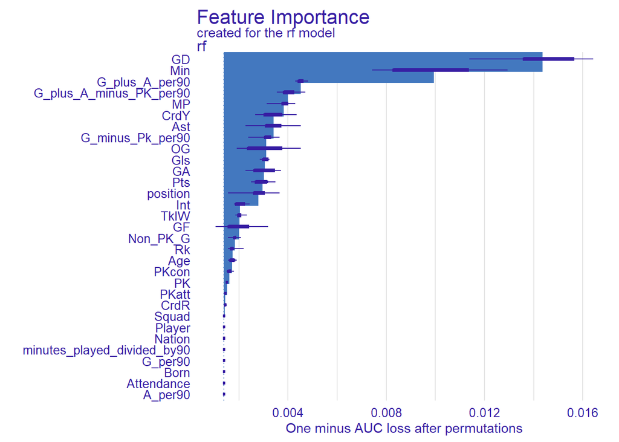

```r
set.seed(494)
ligue1_rf_var_imp <-
  model_parts(
    ligue1_rf_explain
    )

plot(ligue1_rf_var_imp)
```

```r
set.seed(494)
ligue1_ranger_test <- ligue1_ranger_final_wf %>%
  last_fit(ligue1_split)

ligue1_ranger_test %>%
  collect_metrics()
```

```
## # A tibble: 2 x 4
##   .metric  .estimator .estimate .config
##   <chr>    <chr>          <dbl> <chr>
## 1 accuracy binary         0.881 Preprocessor1_Model1
## 2 roc_auc  binary         0.917 Preprocessor1_Model1
```

```r
ligue1_preds1 <- ligue1_ranger_test %>%
  collect_predictions()
```

[figure not shown]

```r
ligue1_ranger_test <- ligue1_testing %>%
  bind_cols(predict(ligue1_ranger_fit, new_data = ligue1_testing, type = "prob")) %>%
  bind_cols(predict(ligue1_ranger_fit, new_data = ligue1_testing))

ligue1_confusion_table <- ligue1_ranger_test %>%
  conf_mat(revision, .pred_class)

ligue1_rf_ggconfusion <- autoplot(ligue1_confusion_table, type = "heatmap") + labs(title = "Confusion Matrix of Ligue 1 Random Forest Model") + scale_fill_gradient(low = "blue", high = "red") + theme(plot.title = element_text(hjust = .5, size = 15))


ligue1_rf_final_confusion <- ggdraw() + draw_image("https://upload.wikimedia.org/wikipedia/commons/thumb/5/5e/Ligue1.svg/1200px-Ligue1.svg.png", x = -.43, y = .4, scale = .18) +
  draw_plot(ligue1_rf_ggconfusion)

ligue1_rf_final_confusion
```

```r
ligue1_ranger_test %>%
  conf_mat(revision, .pred_class)
```

```
##           Truth
## Prediction Normal TOTS
##     Normal    108    6
##     TOTS       11    9
```

```r
ligue1_ranger_test %>%
  filter(revision != .pred_class)
```

```
##                 Player revision position Int TklW OG PKcon Nation      Squad
## 1        Lois Diony 17     TOTS       ST   4   14  0     0    FRA      Dijon
## 2    Blaise Matuidi 17   Normal      CDM  40   42  0     0    FRA  Paris S-G
## 3     Adrien Rabiot 17   Normal       CM  38   46  0     0    FRA  Paris S-G
## 4    Djibril Sidibe 17   Normal       RB  47   52  0     1    FRA     Monaco
## 5          Jemerson 17   Normal       CB  54   51  0     0    BRA     Monaco
## 6  Giovani Lo Celso 18   Normal      CAM  20   59  0     0    ARG  Paris S-G
## 7     Dimitri Payet 18   Normal       LW  18    9  0     0    FRA  Marseille
## 8     Alassane Plea 18   Normal       ST  13    9  0     0    FRA       Nice
## 9         Adil Rami 18     TOTS       CB  33   20  1     0    FRA  Marseille
## 10       Dani Alves 18   Normal       RB  28   52  0     0    BRA  Paris S-G
## 11   Radamel Falcao 18     TOTS       ST  13    7  1     0    COL     Monaco
## 12    Joao Moutinho 18   Normal       CM  39   44  0     0    POR     Monaco
## 13    Houssem Aouar 19   Normal       CM  31   36  0     0    FRA       Lyon
## 14       Kenny Lala 19     TOTS       RB  29   43  0     1    FRA Strasbourg
```

[output cut: 57 more lines]

```r
ligue1_modeling21 <- fifa21_modeling_ligue1 %>%
  mutate(revision = as.factor(revision), Nation = as.factor(Nation), Age = as.integer(Age))
```

```r
ligue1_modeling_outfield21 <- ligue1_modeling21 %>%
  filter(position != "GK") %>%
  filter(minutes_played_divided_by90 >= 14) %>%
  mutate(position = ifelse(position == "RWB", "RB", ifelse(position == "LWB", "LB", position)))
```

```r
ligue1_ranger_test21 <- ligue1_modeling_outfield21 %>%
  bind_cols(predict(ligue1_ranger_fit, new_data = ligue1_modeling_outfield21, type = "prob")) %>%
  bind_cols(predict(ligue1_ranger_fit, new_data = ligue1_modeling_outfield21))
ligue1_ranger_test_att <- ligue1_ranger_test21 %>%
  filter(position %in% c("ST", "RW", "CF", "LW")) %>%
  arrange(desc(.pred_TOTS)) %>%
  head(5) %>%
  mutate(Role = ifelse(rank(.pred_TOTS, ties.method = c("first")) >= 3, "Starter", "Bench"), Position = 1)
```

```r
ligue1_ranger_test_mid <- ligue1_ranger_test21 %>%
  filter(position %in% c("CAM", "CM", "CDM", "LM", "RM")) %>%
  arrange(desc(.pred_TOTS)) %>%
  head(5) %>%
  mutate(Role = ifelse(rank(.pred_TOTS, ties.method = c("first")) >= 3, "Starter", "Bench"), Position = 2)
```

```r
ligue1_ranger_test_def <- ligue1_ranger_test21 %>%
  filter(position %in% c("LB", "CB", "RB")) %>%
  arrange(desc(.pred_TOTS)) %>%
  head(5) %>%
  mutate(Role = ifelse(rank(.pred_TOTS, ties.method = c("first")) >= 2, "Starter", "Bench"), Position = 3)
```

```r
ligue1_tots_21 <- rbind(ligue1_ranger_test_att, ligue1_ranger_test_mid, ligue1_ranger_test_def) %>%
  arrange(desc(Role), Position) %>%
  distinct(Player, Role, position, Squad, Gls, Ast, Pts, Rk, MP, Min, .pred_TOTS) %>%
  rename(Position = position, Goals = Gls, Assists = Ast, Points = Pts, `Team Rank` = Rk, `Matches Played` = MP, `Predicted TOTS Probability` = .pred_TOTS, `Projected Role` = Role)

ligue1_tots_formatted <- formattable(ligue1_tots_21[1:15,1:11])

kable(ligue1_tots_formatted, align = c(rep('c',11)))  %>%
  row_spec(0) %>%
  kable_styling(full_width = F) %>%
  add_header_above(c("Ligue 1 2021 Predicted TOTS" = 11), background = "navy", color = "white") %>%
  row_spec(1:10, background = "green", color = "white") %>%
  row_spec(11:15, background = "red", color = "white")
```

| Ligue 1 2021 Predicted TOTS Player | Ligue 1 2021 Predicted TOTS Position | Ligue 1 2021 Predicted TOTS Squad | Ligue 1 2021 Predicted TOTS Matches Played | Ligue 1 2021 Predicted TOTS Min | Ligue 1 2021 Predicted TOTS Goals | Ligue 1 2021 Predicted TOTS Assists | Ligue 1 2021 Predicted TOTS Team Rank | Ligue 1 2021 Predicted TOTS Points | Ligue 1 2021 Predicted TOTS Predicted TOTS Probability | Ligue 1 2021 Predicted TOTS Projected Role |
| --- | --- | --- | --- | --- | --- | --- | --- | --- | --- | --- |
| Gaetan Laborde | ST | Montpellier | 34 | 2932 | 13 | 8 | 8 | 47 | 0.890 | Starter |
| Memphis Depay | CF | Lyon | 34 | 2653 | 18 | 9 | 4 | 67 | 0.840 | Starter |
| Kylian Mbappe | ST | Paris S-G | 29 | 2214 | 25 | 7 | 2 | 72 | 0.720 | Starter |
| Jonathan Bamba | LM | Lille | 34 | 2719 | 6 | 9 | 1 | 73 | 0.740 | Starter |
| Aurelien Tchouameni | CM | Monaco | 32 | 2703 | 2 | 4 | 3 | 71 | 0.580 | Starter |
| Ander Herrera | CM | Paris S-G | 27 | 1571 | 1 | 3 | 2 | 72 | 0.430 | Starter |
| Thomas Delaine | LB | Metz | 22 | 1600 | 3 | 1 | 10 | 43 | 0.420 | Starter |
| Leo Dubois | RB | Lyon | 33 | 2610 | 2 | 3 | 4 | 67 | 0.390 | Starter |
| Sven Botman | CB | Lille | 33 | 2949 | 0 | 0 | 1 | 73 | 0.385 | Starter |
| Damien Da Silva | CB | Rennes | 27 | 2397 | 4 | 0 | 7 | 54 | 0.380 | Starter |
| Kevin Volland | ST | Monaco | 31 | 2419 | 15 | 7 | 3 | 71 | 0.710 | Bench |
| Wissam Ben Yedder | ST | Monaco | 33 | 2266 | 18 | 5 | 3 | 71 | 0.650 | Bench |
| Benjamin Andre | CDM | Lille | 32 | 2643 | 0 | 1 | 1 | 73 | 0.420 | Bench |
| Gael Kakuta | CAM | Lens | 31 | 2217 | 11 | 5 | 5 | 56 | 0.420 | Bench |
| Leonardo Balerdi | CB | Marseille | 17 | 1363 | 2 | 0 | 6 | 55 | 0.320 | Bench |

```r
fifa19_modeling_bundesliga2 <- fifa19_modeling_bundesliga %>%
  mutate(Player = paste(Player, '19'))

fifa18_modeling_bundesliga2 <- fifa18_modeling_bundesliga %>%
  mutate(Player = paste(Player, '18'))

fifa17_modeling_bundesliga2 <- fifa17_modeling_bundesliga %>%
  mutate(Player = paste(Player, '17'))



bundesliga_modeling <- fifa17_modeling_bundesliga2%>%
  bind_rows(fifa18_modeling_bundesliga2, fifa19_modeling_bundesliga2) %>%
  mutate(revision = as.factor(revision), Nation = as.factor(Nation))
```

```r
bundesliga_modeling_outfield <- bundesliga_modeling %>%
  filter(position != "GK") %>%
  filter(minutes_played_divided_by90 >= 19) %>%
  mutate(position = ifelse(position == "RWB", "RB", ifelse(position == "LWB", "LB", ifelse(position == "RW", "RM", ifelse(position == "LW", "LM", position))))) %>%
  select(-Goals_allowed, -GA90, -SoTA, -Saves, -Save_percent, -W, -L, -D, -CS, -CS_percent, -Pkatt_against, -PKA, -PKsv, -Pk_Save_percent, -PKm)
```

```r
set.seed(494)
bundesliga_split <- initial_split(bundesliga_modeling_outfield, prop = .75, strata = "revision")
bundesliga_training <- training(bundesliga_split)
bundesliga_testing <- testing(bundesliga_split)
```

```r
bundesliga_train_metrics <- bundesliga_training %>%
  mutate(Type = "Training") %>%
  rename(Revision = revision) %>%
  group_by(Revision, Type) %>%
  summarize(Goals = mean(Gls, na.rm = T), Assists = mean(Ast, na.rm = T), `Non PK Goals` = mean(Non_PK_G, na.rm = T), PK = mean(PK, na.rm = T), `Team Rank` = mean(Rk, na.rm = T), `Minutes Per 90` = mean(Min, na.rm = T)/90 , `Goals SD` = sd(Gls, na.rm = T), `Assists SD` = sd(Ast, na.rm = T), `Non PK Goals SD` = sd(Non_PK_G, na.rm = T),`Team Rank SD` = sd(Rk, na.rm = T), `Minutes Per 90 SD` = sd(Min, na.rm = T)/90)
bundesliga_test_metrics <- bundesliga_testing %>%
  mutate(Type = "Testing") %>%
  rename(Revision = revision) %>%
  group_by(Revision, Type) %>%
  summarize(Goals = mean(Gls, na.rm = T), Assists = mean(Ast, na.rm = T), `Non PK Goals` = mean(Non_PK_G, na.rm = T), PK = mean(PK, na.rm = T),`Team Rank` = mean(Rk, na.rm = T), `Minutes Per 90` = mean(Min, na.rm = T)/90, `Goals SD` = sd(Gls, na.rm = T), `Assists SD` = sd(Ast, na.rm = T), `Non PK Goals SD` = sd(Non_PK_G, na.rm = T),`Team Rank SD` = sd(Rk, na.rm = T), `Minutes Per 90 SD` = sd(Min, na.rm = T)/90)
bundesliga_rebound_split <- rbind(bundesliga_train_metrics, bundesliga_test_metrics) %>% arrange(Revision)

bundesliga_metrics_table <- formattable(bundesliga_rebound_split[1:4,1:13])

kable(bundesliga_metrics_table, align = c(rep('c', 1))) %>%
  row_spec(0) %>%
  kable_styling(full_width = F) %>%
  add_header_above(c("Bundesliga Training and Testing Group Comparison for Suspected KPIs" = 13), background = "red", color = "white")
```

| Bundesliga Training and Testing Group Comparison for Suspected KPIs Revision | Bundesliga Training and Testing Group Comparison for Suspected KPIs Type | Bundesliga Training and Testing Group Comparison for Suspected KPIs Goals | Bundesliga Training and Testing Group Comparison for Suspected KPIs Assists | Bundesliga Training and Testing Group Comparison for Suspected KPIs Non PK Goals | Bundesliga Training and Testing Group Comparison for Suspected KPIs PK | Bundesliga Training and Testing Group Comparison for Suspected KPIs Team Rank | Bundesliga Training and Testing Group Comparison for Suspected KPIs Minutes Per 90 | Bundesliga Training and Testing Group Comparison for Suspected KPIs Goals SD | Bundesliga Training and Testing Group Comparison for Suspected KPIs Assists SD | Bundesliga Training and Testing Group Comparison for Suspected KPIs Non PK Goals SD | Bundesliga Training and Testing Group Comparison for Suspected KPIs Team Rank SD | Bundesliga Training and Testing Group Comparison for Suspected KPIs Minutes Per 90 SD |
| --- | --- | --- | --- | --- | --- | --- | --- | --- | --- | --- | --- | --- |
| Normal | Training | 2.753571 | 2.142857 | 2.528571 | 0.2250000 | 9.821429 | 25.32901 | 3.279127 | 2.049815 | 2.971653 | 4.919084 | 3.963559 |
| Normal | Testing | 2.849462 | 2.064516 | 2.634409 | 0.2150538 | 10.075269 | 24.80585 | 3.653308 | 1.904265 | 3.209310 | 4.759970 | 3.341268 |
| TOTS | Training | 8.687500 | 5.437500 | 7.854167 | 0.8333333 | 3.750000 | 27.58588 | 7.754631 | 3.902570 | 6.866476 | 2.935476 | 3.970949 |
| TOTS | Testing | 9.625000 | 6.625000 | 8.062500 | 1.5625000 | 7.062500 | 26.82292 | 7.022583 | 3.827532 | 5.960635 | 4.106397 | 4.332935 |

```r
bundesliga_ranger_recipe <- recipe(revision ~., data = bundesliga_training) %>%
  step_rm(Player, Nation, Squad, G_per90, A_per90, minutes_played_divided_by90, Attendance, Born) %>%
  step_upsample(revision, over_ratio = .55) %>%
  step_mutate_at(all_numeric(), fn = ~as.numeric(.))

bundesliga_ranger_recipe %>%
  prep(bundesliga_training) %>%
  juice()
```

```
## # A tibble: 434 x 24
##    position   Int  TklW    OG PKcon   Age    MP   Min   Gls   Ast Non_PK_G    PK
##    <fct>    <dbl> <dbl> <dbl> <dbl> <dbl> <dbl> <dbl> <dbl> <dbl>    <dbl> <dbl>
##  1 CM          37    51     0     1    28    27  2302     1     3        1     0
##  2 LM          29    10     0     0    30    26  1982     7     4        6     1
##  3 ST          11    20     0     0    23    28  1735     5     1        5     0
##  4 CB          34    41     0     0    28    27  2315     3     2        3     0
##  5 CB          74    39     0     0    19    25  2106     0     0        0     0
##  6 CB          10    30     0     0    24    26  2126     3     0        3     0
##  7 LM          27    17     0     0    26    25  1729     1     3        1     0
##  8 CB          16    21     0     1    21    28  2427     0     2        0     0
##  9 CB          35    23     0     1    32    30  2637     0     0        0     0
## 10 CB          21    12     0     1    22    24  1901     1     0        1     0
## # ... with 424 more rows, and 12 more variables: PKatt <dbl>, CrdY <dbl>,
## #   CrdR <dbl>, G_plus_A_per90 <dbl>, G_minus_Pk_per90 <dbl>,
## #   G_plus_A_minus_PK_per90 <dbl>, Rk <dbl>, GF <dbl>, GA <dbl>, GD <dbl>,
## #   Pts <dbl>, revision <fct>
```

```r
bundesliga_ranger <- rand_forest(mtry = tune(),
              min_n = tune(),
              trees = 100) %>%
  set_mode("classification") %>%
  set_engine("ranger")

bundesliga_ranger_wf <-
  workflow() %>%
  add_recipe(bundesliga_ranger_recipe) %>%
  add_model(bundesliga_ranger)

bundesliga_ranger_wf
```

```
## == Workflow ====================================================================
## Preprocessor: Recipe
## Model: rand_forest()
##
## -- Preprocessor ----------------------------------------------------------------
## 3 Recipe Steps
##
## * step_rm()
## * step_upsample()
## * step_mutate_at()
##
## -- Model -----------------------------------------------------------------------
## Random Forest Model Specification (classification)
##
## Main Arguments:
##   mtry = tune()
##   trees = 100
##   min_n = tune()
##
## Computational engine: ranger
```

```r
set.seed(494)
bundesliga_cv <- vfold_cv(bundesliga_training, v = 5)

bundesliga_rf_grid <- grid_regular(min_n(), finalize(mtry(), bundesliga_training %>% select(-revision)), levels = 3)

ctrl_res <- control_stack_grid()

bundesliga_ranger_cv <- bundesliga_ranger_wf %>%
  tune_grid(resamples = bundesliga_cv,
           grid = bundesliga_rf_grid,
           control = ctrl_res)
```

[output not shown]

[output not shown]

[output not shown]

[output not shown]

[output not shown]

[output not shown]

[output not shown]

[output not shown]

[output not shown]

[output not shown]

[output not shown]

[output not shown]

[output not shown]

[output not shown]

[output not shown]

```r
collect_metrics(bundesliga_ranger_cv)
```

```
## # A tibble: 18 x 8
##     mtry min_n .metric  .estimator  mean     n std_err .config
##    <int> <int> <chr>    <chr>      <dbl> <int>   <dbl> <chr>
##  1     1     2 accuracy binary     0.872     5 0.0194  Preprocessor1_Model1
##  2     1     2 roc_auc  binary     0.885     5 0.0120  Preprocessor1_Model1
##  3     1    21 accuracy binary     0.881     5 0.0129  Preprocessor1_Model2
##  4     1    21 roc_auc  binary     0.895     5 0.0122  Preprocessor1_Model2
##  5     1    40 accuracy binary     0.893     5 0.0133  Preprocessor1_Model3
##  6     1    40 roc_auc  binary     0.894     5 0.00865 Preprocessor1_Model3
##  7    16     2 accuracy binary     0.872     5 0.0175  Preprocessor1_Model4
##  8    16     2 roc_auc  binary     0.862     5 0.0222  Preprocessor1_Model4
##  9    16    21 accuracy binary     0.884     5 0.0181  Preprocessor1_Model5
## 10    16    21 roc_auc  binary     0.864     5 0.0182  Preprocessor1_Model5
## 11    16    40 accuracy binary     0.869     5 0.0146  Preprocessor1_Model6
## 12    16    40 roc_auc  binary     0.864     5 0.0168  Preprocessor1_Model6
## 13    31     2 accuracy binary     0.854     5 0.0272  Preprocessor1_Model7
## 14    31     2 roc_auc  binary     0.861     5 0.0211  Preprocessor1_Model7
## 15    31    21 accuracy binary     0.857     5 0.0210  Preprocessor1_Model8
## 16    31    21 roc_auc  binary     0.857     5 0.0186  Preprocessor1_Model8
## 17    31    40 accuracy binary     0.872     5 0.0193  Preprocessor1_Model9
## 18    31    40 roc_auc  binary     0.862     5 0.0175  Preprocessor1_Model9
```

```r
bundesliga_best1 <- bundesliga_ranger_cv %>%
  select_best(metric = "accuracy")

bundesliga_ranger_final_wf<- bundesliga_ranger_wf %>%
  finalize_workflow(bundesliga_best1)
```

```r
set.seed(494)
bundesliga_ranger_fit <- bundesliga_ranger_final_wf %>%
  fit(bundesliga_training)


bundesliga_rf_explain <-
  explain_tidymodels(
    model = bundesliga_ranger_fit,
    data = bundesliga_training %>% select(-revision),
    y = as.numeric(bundesliga_training$revision == "TOTS"),
    label = "rf"
  )
```

```
## Preparation of a new explainer is initiated
##   -> model label       :  rf
##   -> data              :  328  rows  31  cols
##   -> target variable   :  328  values
##   -> predict function  :  yhat.workflow  will be used (  default  )
##   -> predicted values  :  No value for predict function target column. (  default  )
##   -> model_info        :  package tidymodels , ver. 0.1.2 , task classification (  default  )
##   -> predicted values  :  numerical, min =  0.02071847 , mean =  0.2438431 , max =  0.9038921
##   -> residual function :  difference between y and yhat (  default  )
##   -> residuals         :  numerical, min =  -0.8032962 , mean =  -0.09750159 , max =  0.7312163
##   A new explainer has been created!
```

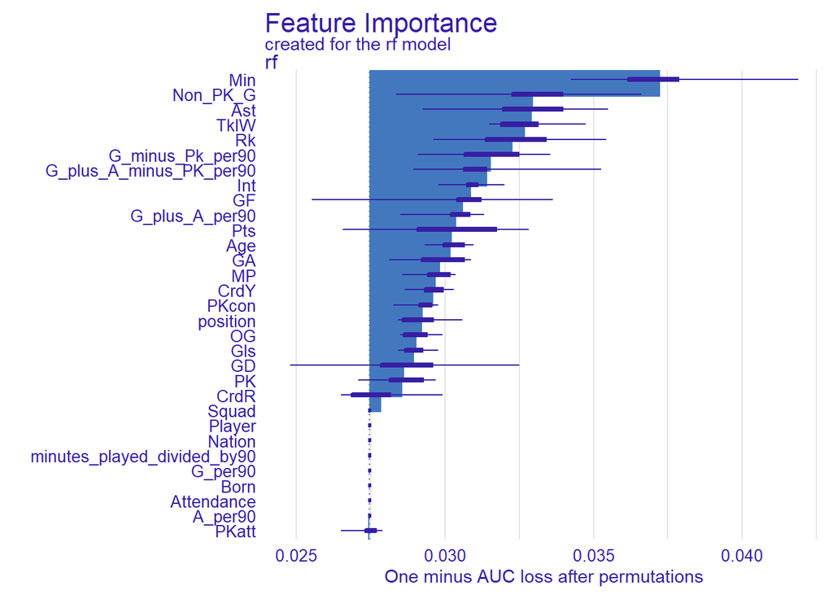

```r
bundesliga_rf_var_imp <-
  model_parts(
    bundesliga_rf_explain
    )

plot(bundesliga_rf_var_imp)
```

```r
bundesliga_ranger_test <- bundesliga_ranger_final_wf %>%
  last_fit(bundesliga_split)

bundesliga_ranger_test %>%
  collect_metrics()
```

```
## # A tibble: 2 x 4
##   .metric  .estimator .estimate .config
##   <chr>    <chr>          <dbl> <chr>
## 1 accuracy binary         0.835 Preprocessor1_Model1
## 2 roc_auc  binary         0.860 Preprocessor1_Model1
```

[figure not shown]

```r
bundesliga_rf_ggconfusion <- autoplot(bundesliga_confusion_table, type = "heatmap") + labs(title = "Confusion Matrix of Bundesliga Random Forest Model") + scale_fill_gradient(low = "blue", high = "red") + theme(plot.title = element_text(hjust = .5, size = 15))


bundesliga_rf_final_confusion <- ggdraw() + draw_image("https://upload.wikimedia.org/wikipedia/en/thumb/d/df/Bundesliga_logo_%282017%29.svg/1200px-Bundesliga_logo_%282017%29.svg.png", x = -.43, y = .4, scale = .18) +
  draw_plot(bundesliga_rf_ggconfusion)

bundesliga_rf_final_confusion
```

```r
bundesliga_modeling21 <- fifa21_modeling_bundesliga %>%
  mutate(revision = as.factor(revision), Nation = as.factor(Nation), Age = as.integer(Age))
```

```r
bundesliga_modeling_outfield21 <- bundesliga_modeling21 %>%
  filter(position != "GK") %>%
  filter(minutes_played_divided_by90 >= 18) %>%
  mutate(position = ifelse(position == "RWB", "RB", ifelse(position == "LWB", "LB", ifelse(position == "RW", "RM", ifelse(position == "LW", "LM", position)))))
```

```r
bundesliga_ranger_test21 <- bundesliga_modeling_outfield21 %>%
  bind_cols(predict(bundesliga_ranger_fit, new_data = bundesliga_modeling_outfield21, type = "prob")) %>%
  bind_cols(predict(bundesliga_ranger_fit, new_data = bundesliga_modeling_outfield21))
bundesliga_ranger_test_att <- bundesliga_ranger_test21 %>%
  filter(position %in% c("ST", "RW", "CF", "LW")) %>%
  arrange(desc(.pred_TOTS)) %>%
  head(5) %>%
  mutate(Role = ifelse(rank(.pred_TOTS, ties.method = c("first")) >= 3, "Starter", "Bench"), Position = 1)
```

```r
bundesliga_ranger_test_mid <- bundesliga_ranger_test21 %>%
  filter(position %in% c("CAM", "CM", "CDM", "LM", "RM")) %>%
  arrange(desc(.pred_TOTS)) %>%
  head(5) %>%
  mutate(Role = ifelse(rank(.pred_TOTS, ties.method = c("first")) >= 3, "Starter", "Bench"), Position = 2)
```

```r
bundesliga_ranger_test_def <- bundesliga_ranger_test21 %>%
  filter(position %in% c("LB", "CB", "RB")) %>%
  arrange(desc(.pred_TOTS)) %>%
  head(5) %>%
  mutate(Role = ifelse(rank(.pred_TOTS, ties.method = c("first")) >= 2, "Starter", "Bench"), Position = 3)
```

```r
bundesliga_tots_21 <- rbind(bundesliga_ranger_test_att, bundesliga_ranger_test_mid, bundesliga_ranger_test_def) %>%
  arrange(desc(Role), Position) %>%
  distinct(Player, Role, position, Squad, Gls, Ast, Pts, Rk, MP, Min, .pred_TOTS) %>%
  rename(Position = position, Goals = Gls, Assists = Ast, Points = Pts, `Team Rank` = Rk, `Matches Played` = MP, `Predicted TOTS Probability` = .pred_TOTS, `Projected Role` = Role)

bundesliga_tots_formatted <- formattable(bundesliga_tots_21[1:15,1:11])

kable(bundesliga_tots_formatted, align = c(rep('c',11)))  %>%
  row_spec(0) %>%
  kable_styling(full_width = F) %>%
  add_header_above(c("Bundesliga 2021 Predicted TOTS" = 11), background = "red", color = "white") %>%
  row_spec(1:10, background = "green", color = "white") %>%
  row_spec(11:15, background = "red", color = "white")
```

| Bundesliga 2021 Predicted TOTS Player | Bundesliga 2021 Predicted TOTS Position | Bundesliga 2021 Predicted TOTS Squad | Bundesliga 2021 Predicted TOTS Matches Played | Bundesliga 2021 Predicted TOTS Min | Bundesliga 2021 Predicted TOTS Goals | Bundesliga 2021 Predicted TOTS Assists | Bundesliga 2021 Predicted TOTS Team Rank | Bundesliga 2021 Predicted TOTS Points | Bundesliga 2021 Predicted TOTS Predicted TOTS Probability | Bundesliga 2021 Predicted TOTS Projected Role |
| --- | --- | --- | --- | --- | --- | --- | --- | --- | --- | --- |
| Wout Weghorst | ST | Wolfsburg | 31 | 2671 | 20 | 7 | 3 | 57 | 0.8402007 | Starter |
| Robert Lewandowski | ST | Bayern Munich | 26 | 2188 | 36 | 6 | 1 | 71 | 0.8085189 | Starter |
| Erling Haaland | ST | Dortmund | 26 | 2227 | 25 | 5 | 5 | 55 | 0.7750907 | Starter |
| Thomas Muller | CAM | Bayern Munich | 29 | 2453 | 10 | 17 | 1 | 71 | 0.8045416 | Starter |
| Leroy Sane | LM | Bayern Munich | 29 | 1672 | 4 | 9 | 1 | 71 | 0.7187507 | Starter |
| Joshua Kimmich | CDM | Bayern Munich | 24 | 1924 | 3 | 10 | 1 | 71 | 0.6848506 | Starter |
| David Alaba | CB | Bayern Munich | 29 | 2454 | 2 | 2 | 1 | 71 | 0.5641070 | Starter |
| Jerome Boateng | CB | Bayern Munich | 26 | 2148 | 1 | 1 | 1 | 71 | 0.5273112 | Starter |
| Ridle Baku | RB | Wolfsburg | 29 | 2409 | 6 | 4 | 3 | 57 | 0.4589220 | Starter |
| Angelino | LB | RB Leipzig | 24 | 2042 | 4 | 4 | 2 | 64 | 0.4514446 | Starter |
| Andre Silva | ST | Eint Frankfurt | 29 | 2490 | 25 | 6 | 4 | 56 | 0.7665250 | Bench |
| Andrej Kramaric | ST | Hoffenheim | 25 | 2109 | 17 | 3 | 11 | 36 | 0.5549401 | Bench |
| Dani Olmo | CAM | RB Leipzig | 31 | 2104 | 4 | 9 | 2 | 64 | 0.6773476 | Bench |
| Leon Goretzka | CM | Bayern Munich | 23 | 1695 | 5 | 5 | 1 | 71 | 0.6361432 | Bench |
| Willi Orban | CB | RB Leipzig | 26 | 2093 | 4 | 1 | 2 | 64 | 0.4441475 | Bench |

```r
fifa19_modeling_serie_a2 <- fifa19_modeling_serie_a %>%
  mutate(Player = paste(Player, '19'))

fifa18_modeling_serie_a2 <- fifa18_modeling_serie_a %>%
  mutate(Player = paste(Player, '18'))

fifa17_modeling_serie_a2 <- fifa17_modeling_serie_a %>%
  mutate(Player = paste(Player, '17'))



serie_a_modeling <- fifa17_modeling_serie_a2%>%
  bind_rows(fifa18_modeling_serie_a2, fifa19_modeling_serie_a2) %>%
  mutate(revision = as.factor(revision), Nation = as.factor(Nation))
```

```r
serie_a_modeling_outfield <- serie_a_modeling %>%
  filter(position != "GK") %>%
  #filter(position %in% c("ST", "LW", "RW", "CF", "CAM")) %>%
  filter(minutes_played_divided_by90 >= 19) %>%
  mutate(position = ifelse(position == "RWB", "RB", ifelse(position == "LWB", "LB", position))) %>%
  select(-Goals_allowed, -GA90, -SoTA, -Saves, -Save_percent, -W, -L, -D, -CS, -CS_percent, -Pkatt_against, -PKA, -PKsv, -Pk_Save_percent, -PKm)
```

```r
set.seed(494)
serie_a_split <- initial_split(serie_a_modeling_outfield, prop = .75, strata = "revision")
serie_a_training <- training(serie_a_split)
serie_a_testing <- testing(serie_a_split)
```

```r
serie_a_train_metrics <- serie_a_training %>%
  mutate(Type = "Training") %>%
  rename(Revision = revision) %>%
  group_by(Revision, Type) %>%
  summarize(Goals = mean(Gls, na.rm = T), Assists = mean(Ast, na.rm = T), `Non PK Goals` = mean(Non_PK_G, na.rm = T), PK = mean(PK, na.rm = T), `Team Rank` = mean(Rk, na.rm = T), `Minutes Per 90` = mean(Min, na.rm = T)/90 , `Goals SD` = sd(Gls, na.rm = T), `Assists SD` = sd(Ast, na.rm = T), `Non PK Goals SD` = sd(Non_PK_G, na.rm = T),`Team Rank SD` = sd(Rk, na.rm = T), `Minutes Per 90 SD` = sd(Min, na.rm = T)/90)
serie_a_test_metrics <- serie_a_testing %>%
  mutate(Type = "Testing") %>%
  rename(Revision = revision) %>%
  group_by(Revision, Type) %>%
  summarize(Goals = mean(Gls, na.rm = T), Assists = mean(Ast, na.rm = T), `Non PK Goals` = mean(Non_PK_G, na.rm = T), PK = mean(PK, na.rm = T),`Team Rank` = mean(Rk, na.rm = T), `Minutes Per 90` = mean(Min, na.rm = T)/90, `Goals SD` = sd(Gls, na.rm = T), `Assists SD` = sd(Ast, na.rm = T), `Non PK Goals SD` = sd(Non_PK_G, na.rm = T),`Team Rank SD` = sd(Rk, na.rm = T), `Minutes Per 90 SD` = sd(Min, na.rm = T)/90)
serie_a_rebound_split <- rbind(serie_a_train_metrics, serie_a_test_metrics) %>% arrange(Revision)

serie_a_metrics_table <- formattable(serie_a_rebound_split[1:4,1:13])

kable(serie_a_metrics_table, align = c(rep('c', 1))) %>%
  row_spec(0) %>%
  kable_styling(full_width = F) %>%
  add_header_above(c("Serie A Training and Testing Group Comparison for Suspected KPIs" = 13), background = "red", color = "#00FF00")
```

| Serie A Training and Testing Group Comparison for Suspected KPIs Revision | Serie A Training and Testing Group Comparison for Suspected KPIs Type | Serie A Training and Testing Group Comparison for Suspected KPIs Goals | Serie A Training and Testing Group Comparison for Suspected KPIs Assists | Serie A Training and Testing Group Comparison for Suspected KPIs Non PK Goals | Serie A Training and Testing Group Comparison for Suspected KPIs PK | Serie A Training and Testing Group Comparison for Suspected KPIs Team Rank | Serie A Training and Testing Group Comparison for Suspected KPIs Minutes Per 90 | Serie A Training and Testing Group Comparison for Suspected KPIs Goals SD | Serie A Training and Testing Group Comparison for Suspected KPIs Assists SD | Serie A Training and Testing Group Comparison for Suspected KPIs Non PK Goals SD | Serie A Training and Testing Group Comparison for Suspected KPIs Team Rank SD | Serie A Training and Testing Group Comparison for Suspected KPIs Minutes Per 90 SD |
| --- | --- | --- | --- | --- | --- | --- | --- | --- | --- | --- | --- | --- |
| Normal | Training | 3.172702 | 2.350975 | 2.883008 | 0.2896936 | 10.777159 | 27.01501 | 3.655291 | 2.215850 | 3.263599 | 5.538129 | 4.844356 |
| Normal | Testing | 2.873950 | 2.134454 | 2.563025 | 0.3109244 | 10.647059 | 26.81410 | 3.472787 | 2.306675 | 3.219745 | 5.453328 | 4.813499 |
| TOTS | Training | 10.339623 | 4.849057 | 9.301887 | 1.0377358 | 4.301887 | 29.78973 | 8.864240 | 3.307313 | 7.655026 | 3.220039 | 5.059081 |
| TOTS | Testing | 9.411765 | 5.176471 | 8.000000 | 1.4117647 | 3.882353 | 28.83987 | 7.080420 | 4.333522 | 5.623611 | 3.407388 | 5.063365 |

```r
serie_a_ranger_recipe <- recipe(revision ~., data = serie_a_training) %>%
  step_rm(Player, Nation, Squad, Born, G_per90, A_per90, minutes_played_divided_by90, Attendance) %>%
  step_upsample(revision, over_ratio = .4) %>%
  step_mutate_at(all_numeric(), fn = ~as.numeric(.))

serie_a_ranger_recipe %>%
  prep(serie_a_training) %>%
  juice()
```

```
## # A tibble: 502 x 24
##    position   Int  TklW    OG PKcon   Age    MP   Min   Gls   Ast Non_PK_G    PK
##    <fct>    <dbl> <dbl> <dbl> <dbl> <dbl> <dbl> <dbl> <dbl> <dbl>    <dbl> <dbl>
##  1 CB          51    32     0     2    27    37  3258     2     0        2     0
##  2 RW          33    27     0     0    26    35  2516    12     8       10     2
##  3 LB          15    24     0     0    31    24  1807     3     2        3     0
##  4 CM          40    38     0     0    32    34  2741     0     0        0     0
##  5 CDM         28    23     0     0    21    25  1803     0     1        0     0
##  6 CB          18    20     0     1    22    32  2880     0     1        0     0
##  7 CB          25    26     0     1    31    24  1927     0     0        0     0
##  8 ST           9    15     0     2    28    33  2719    11     0       11     0
##  9 LB          15    24     0     0    31    24  1807     3     2        3     0
## 10 CM          37    52     0     0    32    28  1984     0     4        0     0
## # ... with 492 more rows, and 12 more variables: PKatt <dbl>, CrdY <dbl>,
## #   CrdR <dbl>, G_plus_A_per90 <dbl>, G_minus_Pk_per90 <dbl>,
## #   G_plus_A_minus_PK_per90 <dbl>, Rk <dbl>, GF <dbl>, GA <dbl>, GD <dbl>,
## #   Pts <dbl>, revision <fct>
```

```r
serie_a_ranger <- rand_forest(mtry = tune(),
              min_n = tune(),
              trees = 100) %>%
  set_mode("classification") %>%
  set_engine("ranger")

serie_a_ranger_wf <-
  workflow() %>%
  add_recipe(serie_a_ranger_recipe) %>%
  add_model(serie_a_ranger)

serie_a_ranger_wf
```

```
## == Workflow ====================================================================
## Preprocessor: Recipe
## Model: rand_forest()
##
## -- Preprocessor ----------------------------------------------------------------
## 3 Recipe Steps
##
## * step_rm()
## * step_upsample()
## * step_mutate_at()
##
## -- Model -----------------------------------------------------------------------
## Random Forest Model Specification (classification)
##
## Main Arguments:
##   mtry = tune()
##   trees = 100
##   min_n = tune()
##
## Computational engine: ranger
```

```r
set.seed(494)
serie_a_cv <- vfold_cv(serie_a_training, v = 5)

serie_a_rf_grid <- grid_regular(min_n(), finalize(mtry(), serie_a_training %>% select(-revision)), levels = 3)

ctrl_res <- control_stack_grid()

serie_a_ranger_cv <- serie_a_ranger_wf %>%
  tune_grid(resamples = serie_a_cv,
           grid = serie_a_rf_grid,
           control = ctrl_res)
```

[output not shown]

[output not shown]

[output not shown]

[output not shown]

[output not shown]

[output not shown]

[output not shown]

[output not shown]

[output not shown]

[output not shown]

[output not shown]

[output not shown]

[output not shown]

[output not shown]

[output not shown]

```r
collect_metrics(serie_a_ranger_cv)
```

```
## # A tibble: 18 x 8
##     mtry min_n .metric  .estimator  mean     n std_err .config
##    <int> <int> <chr>    <chr>      <dbl> <int>   <dbl> <chr>
##  1     1     2 accuracy binary     0.888     5 0.0153  Preprocessor1_Model1
##  2     1     2 roc_auc  binary     0.904     5 0.0136  Preprocessor1_Model1
##  3     1    21 accuracy binary     0.896     5 0.0144  Preprocessor1_Model2
##  4     1    21 roc_auc  binary     0.888     5 0.0171  Preprocessor1_Model2
##  5     1    40 accuracy binary     0.896     5 0.0112  Preprocessor1_Model3
##  6     1    40 roc_auc  binary     0.890     5 0.0209  Preprocessor1_Model3
##  7    16     2 accuracy binary     0.872     5 0.0167  Preprocessor1_Model4
##  8    16     2 roc_auc  binary     0.873     5 0.0185  Preprocessor1_Model4
##  9    16    21 accuracy binary     0.867     5 0.00506 Preprocessor1_Model5
## 10    16    21 roc_auc  binary     0.876     5 0.0202  Preprocessor1_Model5
## 11    16    40 accuracy binary     0.864     5 0.0133  Preprocessor1_Model6
## 12    16    40 roc_auc  binary     0.874     5 0.0232  Preprocessor1_Model6
## 13    31     2 accuracy binary     0.869     5 0.0147  Preprocessor1_Model7
## 14    31     2 roc_auc  binary     0.874     5 0.0234  Preprocessor1_Model7
## 15    31    21 accuracy binary     0.852     5 0.0126  Preprocessor1_Model8
## 16    31    21 roc_auc  binary     0.868     5 0.0218  Preprocessor1_Model8
## 17    31    40 accuracy binary     0.847     5 0.00889 Preprocessor1_Model9
## 18    31    40 roc_auc  binary     0.866     5 0.0251  Preprocessor1_Model9
```

```r
serie_a_best1 <- serie_a_ranger_cv %>%
  select_best(metric = "accuracy")

serie_a_ranger_final_wf<- serie_a_ranger_wf %>%
  finalize_workflow(serie_a_best1)
```

```r
set.seed(494)
serie_a_ranger_fit <- serie_a_ranger_final_wf %>%
  fit(serie_a_training)


serie_a_rf_explain <-
  explain_tidymodels(
    model = serie_a_ranger_fit,
    data = serie_a_training %>% select(-revision),
    y = as.numeric(serie_a_training$revision == "TOTS"),
    label = "rf"
  )
```

```
## Preparation of a new explainer is initiated
##   -> model label       :  rf
##   -> data              :  412  rows  31  cols
##   -> target variable   :  412  values
##   -> predict function  :  yhat.workflow  will be used (  default  )
##   -> predicted values  :  No value for predict function target column. (  default  )
##   -> model_info        :  package tidymodels , ver. 0.1.2 , task classification (  default  )
##   -> predicted values  :  numerical, min =  0.004085272 , mean =  0.2019935 , max =  0.9309736
##   -> residual function :  difference between y and yhat (  default  )
##   -> residuals         :  numerical, min =  -0.6310856 , mean =  -0.07335276 , max =  0.7620644
##   A new explainer has been created!
```

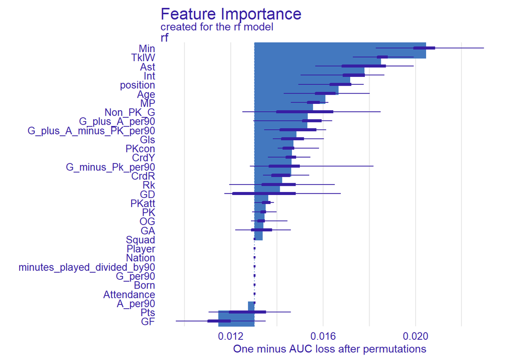

```r
serie_a_rf_var_imp <-
  model_parts(
    serie_a_rf_explain
    )

plot(serie_a_rf_var_imp)
```

```r
serie_a_ranger_test <- serie_a_ranger_final_wf %>%
  last_fit(serie_a_split)

serie_a_ranger_test %>%
  collect_metrics()
```

```
## # A tibble: 2 x 4
##   .metric  .estimator .estimate .config
##   <chr>    <chr>          <dbl> <chr>
## 1 accuracy binary         0.919 Preprocessor1_Model1
## 2 roc_auc  binary         0.933 Preprocessor1_Model1
```

```r
preds1 <- serie_a_ranger_test %>%
  collect_predictions()

preds1 %>%
  conf_mat(revision, .pred_class)
```

```
##           Truth
## Prediction Normal TOTS
##     Normal    116    8
##     TOTS        3    9
```

[figure not shown]

```r
serie_a_ranger_test <- serie_a_testing %>%
  bind_cols(predict(serie_a_ranger_fit, new_data = serie_a_testing, type = "prob")) %>%
  bind_cols(predict(serie_a_ranger_fit, new_data = serie_a_testing))

serie_a_confusion_table <- serie_a_ranger_test %>%
  conf_mat(revision, .pred_class)

serie_a_ranger_ggconfusion <- autoplot(serie_a_confusion_table, type = "heatmap") + labs(title = "Confusion Matrix of Serie A Random Forest Model") + scale_fill_gradient(low = "blue", high = "red") + theme(plot.title = element_text(hjust = .5, size = 15))
serie_a_final_confusion <- ggdraw() + draw_image("https://static.wikia.nocookie.net/logopedia/images/1/12/Serie_A_2019.svg/revision/latest/scale-to-width-down/140?cb=20190710115458", x = -.43, y = .4, scale = .18) +
  draw_plot(serie_a_ranger_ggconfusion)

serie_a_final_confusion
```

```r
serie_a_ranger_test %>%
  conf_mat(revision, .pred_class)
```

```
##           Truth
## Prediction Normal TOTS
##     Normal    117    8
##     TOTS        2    9
```

```r
serie_a_ranger_test %>%
  filter(revision != .pred_class)
```

```
##                   Player revision position Int TklW OG PKcon Nation      Squad
## 1      Mattia Caldara 17     TOTS       CB  90   36  0     0    ITA   Atalanta
## 2   Giorgio Chiellini 18     TOTS       CB  28   15  0     0    ITA   Juventus
## 3     Federico Chiesa 18     TOTS       RW   9   37  0     0    ITA Fiorentina
## 4          Edin Dzeko 18   Normal       ST   2   10  0     0    BIH       Roma
## 5  Fabio Quagliarella 18     TOTS       ST   8    9  0     0    ITA  Sampdoria
## 6            Emre Can 19     TOTS       CM  21   58  1     1    GER   Juventus
## 7   Giorgio Chiellini 19     TOTS       CB  23    9  0     0    ITA   Juventus
## 8     Rodrigo De Paul 19     TOTS       CM  36   31  0     1    ARG    Udinese
## 9     Mario Mandzukic 19   Normal       ST  12   22  0     0    CRO   Juventus
## 10              Allan 19     TOTS       CM  16   92  0     0    BRA     Napoli
##    Age Born MP  Min minutes_played_divided_by90 Gls Ast Non_PK_G PK PKatt CrdY
## 1   22 1994 30 2655                        29.5   7   0        7  0     0    4
## 2   32 1984 26 2161                        24.0   0   1        0  0     0    2
## 3   19 1997 36 3012                        33.5   6   4        6  0     0    7
```

[output cut: 29 more lines]

```r
serie_a_modeling21 <- fifa21_modeling_serie_a %>%
  mutate(revision = as.factor(revision), Nation = as.factor(Nation), Age = as.integer(Age))
```

```r
serie_a_modeling_outfield21 <- serie_a_modeling21 %>%
  filter(position != "GK") %>%
  filter(minutes_played_divided_by90 >= 14) %>%
  mutate(position = ifelse(position == "RWB", "RB", ifelse(position == "LWB", "LB", position)))
```

```r
serie_a_ranger_test21 <- serie_a_modeling_outfield21 %>%
  bind_cols(predict(serie_a_ranger_fit, new_data = serie_a_modeling_outfield21, type = "prob")) %>%
  bind_cols(predict(serie_a_ranger_fit, new_data = serie_a_modeling_outfield21))
serie_a_ranger_test_att <- serie_a_ranger_test21 %>%
  filter(position %in% c("ST", "RW", "CF", "LW")) %>%
  arrange(desc(.pred_TOTS)) %>%
  head(5) %>%
    mutate(Role = ifelse(rank(.pred_TOTS, ties.method = c("first")) >= 3, "Starter", "Bench"), Position = 1)
```

```r
serie_a_ranger_test_mid <- serie_a_ranger_test21 %>%
  filter(position %in% c("CAM", "CM", "CDM", "LM", "RM")) %>%
  arrange(desc(.pred_TOTS)) %>%
  head(5) %>%
  mutate(Role = ifelse(rank(.pred_TOTS, ties.method = c("first")) >= 3, "Starter", "Bench"), Position = 2)
```

```r
serie_a_ranger_test_def <- serie_a_ranger_test21 %>%
  filter(position %in% c("LB", "CB", "RB")) %>%
  arrange(desc(.pred_TOTS)) %>%
  head(5) %>%
  mutate(Role = ifelse(rank(.pred_TOTS, ties.method = c("first")) >= 2, "Starter", "Bench"), Position = 3)
```

```r
serie_a_tots_21 <- rbind(serie_a_ranger_test_att, serie_a_ranger_test_mid, serie_a_ranger_test_def) %>%
  arrange(desc(Role), Position) %>%
  distinct(Player, Role, position, Squad, Gls, Ast, Pts, Rk, MP, Min, .pred_TOTS) %>%
  rename(Position = position, Goals = Gls, Assists = Ast, Points = Pts, `Team Rank` = Rk, `Matches Played` = MP, `Predicted TOTS Probability` = .pred_TOTS, `Projected Role` = Role)

serie_a_tots_formatted <- formattable(serie_a_tots_21[1:15,1:11])

kable(serie_a_tots_formatted, align = c(rep('c',11)))  %>%
  row_spec(0) %>%
  kable_styling(full_width = F) %>%
  add_header_above(c("Serie A 2021 Predicted TOTS" = 11), background = "red", color = "#00FF00") %>%
  row_spec(1:10, background = "green", color = "white") %>%
  row_spec(11:15, background = "red", color = "white")
```

| Serie A 2021 Predicted TOTS Player | Serie A 2021 Predicted TOTS Position | Serie A 2021 Predicted TOTS Squad | Serie A 2021 Predicted TOTS Matches Played | Serie A 2021 Predicted TOTS Min | Serie A 2021 Predicted TOTS Goals | Serie A 2021 Predicted TOTS Assists | Serie A 2021 Predicted TOTS Team Rank | Serie A 2021 Predicted TOTS Points | Serie A 2021 Predicted TOTS Predicted TOTS Probability | Serie A 2021 Predicted TOTS Projected Role |
| --- | --- | --- | --- | --- | --- | --- | --- | --- | --- | --- |
| Romelu Lukaku | ST | Inter | 32 | 2580 | 21 | 9 | 1 | 79 | 0.8076085 | Starter |
| Cristiano Ronaldo | ST | Juventus | 29 | 2463 | 25 | 2 | 3 | 66 | 0.7640680 | Starter |
| Lautaro Martinez | ST | Inter | 33 | 2238 | 15 | 5 | 1 | 79 | 0.6532790 | Starter |
| Ruslan Malinovskyi | CM | Atalanta | 31 | 1525 | 6 | 9 | 2 | 68 | 0.5491604 | Starter |
| Matteo Politano | RM | Napoli | 32 | 1696 | 9 | 4 | 4 | 66 | 0.5358178 | Starter |
| Piotr Zielinski | CM | Napoli | 31 | 2154 | 6 | 8 | 4 | 66 | 0.5233437 | Starter |
| Cristian Romero | CB | Atalanta | 26 | 2095 | 2 | 2 | 2 | 68 | 0.4763224 | Starter |
| Milan Skriniar | CB | Inter | 29 | 2507 | 3 | 0 | 1 | 79 | 0.3282628 | Starter |
| Juan Cuadrado | RB | Juventus | 25 | 1812 | 0 | 10 | 3 | 66 | 0.3059387 | Starter |
| Rafael Toloi | CB | Atalanta | 28 | 2283 | 2 | 0 | 2 | 68 | 0.2961210 | Starter |
| Duvan Zapata | ST | Atalanta | 32 | 2052 | 14 | 7 | 2 | 68 | 0.5800192 | Bench |
| Ciro Immobile | ST | Lazio | 30 | 2399 | 18 | 5 | 6 | 61 | 0.5494533 | Bench |
| Achraf Hakimi | RM | Inter | 32 | 2307 | 6 | 6 | 1 | 79 | 0.4933506 | Bench |
| Nicolo Barella | CM | Inter | 32 | 2596 | 3 | 5 | 1 | 79 | 0.4745268 | Bench |
| Jose Luis Palomino | CB | Atalanta | 31 | 2217 | 1 | 2 | 2 | 68 | 0.2645608 | Bench |

# Kevin De Bruyne in the Models

We used a single player to illustrate the difference in the models between leagues and show how the different predictions are made.

[figure not shown]

```r
new_obs_1 <- prem_ranger_test21 %>% filter(Player == "Kevin De Bruyne") %>% slice(1)

#Pulls together the data needed for the break-down plot
pp_sterling_rf_prem <- predict_parts(explainer = prem_rf_explain,
                          new_observation = new_obs_1,
                          type = "break_down") #default

pp_sterling_rf_la_liga <- predict_parts(explainer = la_liga_rf_explain,
                          new_observation = new_obs_1,
                          type = "break_down") #default

pp_sterling_rf_ligue1 <- predict_parts(explainer = ligue1_rf_explain,
                          new_observation = new_obs_1,
                          type = "break_down") #default

pp_sterling_rf_bundesliga <- predict_parts(explainer = bundesliga_rf_explain,
                          new_observation = new_obs_1,
                          type = "break_down") #default

pp_sterling_rf_serie_a <- predict_parts(explainer = serie_a_rf_explain,
                          new_observation = new_obs_1,
                          type = "break_down") #default

# Break-down plot
sterling_prem_pp <- plot(pp_sterling_rf_prem, title = "Kevin De Bruyne Premier League 2021 Prediction") + theme(plot.title = element_text(hjust = .5, size = 15, color = "black", face = "bold"))

sterling_la_liga_pp <- plot(pp_sterling_rf_la_liga, title = "Kevin De Bruyne La Liga 2021 Prediction") + theme(plot.title = element_text(hjust = .5, size = 15, color = "black", face = "bold"))

sterling_ligue1_pp <- plot(pp_sterling_rf_ligue1, title = "Kevin De Bruyne Ligue 1 2021 Prediction") + theme(plot.title = element_text(hjust = .5, size = 15, color = "black", face = "bold"))

sterling_bundesliga_pp <- plot(pp_sterling_rf_bundesliga, title = "Kevin De Bruyne Bundesliga 2021 Prediction") + theme(plot.title = element_text(hjust = .5, size = 15, color = "black", face = "bold"))

sterling_serie_a_pp <- plot(pp_sterling_rf_serie_a, title = "Kevin De Bruyne Serie A 2021 Prediction") + theme(plot.title = element_text(hjust = .5, size = 15, color = "black", face = "bold"))


ggdraw() + draw_image("https://resources.premierleague.com/premierleague/photos/players/250x250/p61366.png", x = -.43, y = .4, scale = .18) +
  draw_plot(sterling_prem_pp)
```

[figure not shown]

```r
ggdraw() + draw_image("https://resources.premierleague.com/premierleague/photos/players/250x250/p61366.png", x = .45, y = .4, scale = .18) +
  draw_plot(sterling_la_liga_pp)
```

[figure not shown]

```r
ggdraw() + draw_image("https://resources.premierleague.com/premierleague/photos/players/250x250/p61366.png", x = -.43, y = .4, scale = .18) +
  draw_plot(sterling_ligue1_pp)
```

[figure not shown]

```r
ggdraw() + draw_image("https://resources.premierleague.com/premierleague/photos/players/250x250/p61366.png", x = -.43, y = .4, scale = .18) +
  draw_plot(sterling_bundesliga_pp)
```

[figure not shown]

```r
ggdraw() + draw_image("https://resources.premierleague.com/premierleague/photos/players/250x250/p61366.png", x = -.43, y = .4, scale = .18) +
  draw_plot(sterling_serie_a_pp)
```

# Conclusion

In conclusion, we cleaned the data (mostly names), made five separate models, and looked at how those models compared to each other. The most difficult part of this task was making sure we could join the data sets and making the upsampling of the models correct (depending on the size of the leagues and the number of tots players it could vary a lot). We should mention that the knitted version of this does not match the version in rstudio, so in our final product we saved the images of the outputs that we wanted. Therefore, I’m not sure how reproducalbe this actually is, but all the code should be right.